# BTVN Chương 5: Phân tích thành phần chính (PCA)

Nhóm 10

29/10/2026

**Môn học:** Thống kê nhiều chiều | **Giảng viên hướng dẫn:** TS. Nguyễn Thị Mộng Ngọc

**Nhóm 10 – Học viên thực hiện:** Vũ Hà Thư (25C23004), Trần Việt Hà (25C23020)

BẢNG PHÂN CÔNG CÔNG VIỆC

STT

Họ và tên

MSHV

Nội dung phụ trách

Mức độ hoàn thành

1

Vũ Hà Thư

25C23004

- Bài 5.7 – Dữ liệu stock-price: câu (a)–(d)
- Bài La Liga – Thống kê thành tích các đội bóng: câu (a)–(c), gồm hai kịch bản 18 biến và 16 biến

100%

2

Trần Việt Hà

25C23020

- Bài 5.8 – PCA và ảnh hưởng của đơn vị đo: câu (a)–(c)
- Bài 5.11 – Dữ liệu an ninh lương thực tại châu Phi: câu (a)–(c)

100%

# Bài tập 5.7 - Phân tích thành phần chính (dữ liệu stock-price)

## Giới thiệu và đề bài

### Bối cảnh

Dữ liệu ghi nhận **suất sinh lợi theo tuần** (weekly rate of return) của **5 cổ phiếu niêm yết trên Sở giao dịch chứng khoán New York (NYSE)** trong **103 tuần liên tiếp, từ tháng 01/2004 đến tháng 12/2005**. Suất sinh lợi tuần được tính bằng

$$\text{suất sinh lợi tuần} =
\frac{\text{giá đóng cửa tuần này} - \text{giá đóng cửa tuần
trước}}{\text{giá đóng cửa tuần trước}},$$

đã điều chỉnh theo chia tách cổ phiếu và cổ tức. Năm biến gồm:

| Biến | Cổ phiếu | Nhóm ngành |
| --- | --- | --- |
| $x_1$ | JP Morgan | Ngân hàng |
| $x_2$ | Citibank | Ngân hàng |
| $x_3$ | Wells Fargo | Ngân hàng |
| $x_4$ | Royal Dutch Shell | Dầu lửa |
| $x_5$ | ExxonMobil | Dầu lửa |

Quan trắc giữa các tuần được xem là độc lập, nhưng suất sinh lợi của các cổ phiếu **trong cùng một tuần** tương quan với nhau, vì các cổ phiếu cùng phản ứng với tình hình kinh tế chung, và các cổ phiếu cùng ngành còn chịu chung các cú sốc của ngành. Vì vậy 5 biến chứa nhiều thông tin trùng lặp. Phân tích thành phần chính (PCA) được dùng để tìm một số ít tổ hợp tuyến tính không tương quan của 5 suất sinh lợi giải thích được phần lớn biến thiên, và xem các tổ hợp này phản ánh yếu tố gì (thị trường chung, ngành, hay riêng từng công ty).

### Câu hỏi đặt ra

**Bài 5.7.** Dùng dữ liệu về suất sinh lợi/tuần khảo sát trong ví dụ 5.4 (dữ liệu stock-price).

- **(a)** Xây dựng ma trận hiệp phương sai $\mathbf S$ và các thành phần chính tương ứng.
- **(b)** Tính tỷ số đóng góp vào phương sai suy rộng của ba thành phần chính đầu tiên và giải thích ý nghĩa của nó.
- **(c)** Xây dựng các khoảng tin cậy đồng thời Bonferroni 90% cho các phương sai $\lambda_1,\lambda_2,\lambda_3$ của ba thành phần chính đầu $Y_1, Y_2, Y_3$.
- **(d)** Với kết quả trong các phần a–c, đánh giá xem dữ liệu có thể thu gọn xuống ít hơn 5 chiều không? Giải thích.

## Dữ liệu và kiểm tra đầu vào

### Mô tả dữ liệu

```r
stock <- read.table(file.path(data_dir, "EXo_5_7.DAT"), header = FALSE)
colnames(stock) <- c("JPMorgan", "Citibank", "WellsFargo", "RDShell", "ExxonMobil")
X <- as.matrix(stock)

n <- nrow(X)
p <- ncol(X)
c(n = n, p = p)
```

```
##   n   p
## 103   5
```

```r
str(stock)
```

```
## 'data.frame':    103 obs. of  5 variables:
##  $ JPMorgan  : num  0.01303 0.00849 -0.01792 0.02156 0.01082 ...
##  $ Citibank  : num  -0.00784 0.01669 -0.00864 -0.00349 0.00372 ...
##  $ WellsFargo: num  -0.00319 -0.00621 0.01004 0.01744 -0.01013 ...
##  $ RDShell   : num  -0.0448 0.012 0 -0.0286 0.0292 ...
##  $ ExxonMobil: num  0.00522 0.01349 -0.00614 -0.00695 0.04098 ...
```

```r
head(stock)
```

```
##     JPMorgan   Citibank WellsFargo    RDShell ExxonMobil
## 1  0.0130338 -0.0078431 -0.0031889 -0.0447693  0.0052151
## 2  0.0084862  0.0166886 -0.0062100  0.0119560  0.0134890
## 3 -0.0179153 -0.0086393  0.0100360  0.0000000 -0.0061428
## 4  0.0215589 -0.0034858  0.0174353 -0.0285917 -0.0069534
## 5  0.0108225  0.0037167 -0.0101345  0.0291900  0.0409751
## 6  0.0101713 -0.0121978 -0.0083768  0.0137083  0.0029895
```

Dữ liệu có **n = 103 quan trắc** (tuần) và **p = 5 biến**, sắp theo thứ tự $x_1,\dots,x_5$ như bảng ở mục Bối cảnh. Cả 5 biến đều là biến số liên tục (suất sinh lợi, không có đơn vị).

```r
summary(stock)
```

```
##     JPMorgan            Citibank            WellsFargo
##  Min.   :-0.045867   Min.   :-0.0597924   Min.   :-0.0362141
##  1st Qu.:-0.013564   1st Qu.:-0.0132409   1st Qu.:-0.0080536
##  Median : 0.003363   Median : 0.0017339   Median : 0.0003354
##  Mean   : 0.001063   Mean   : 0.0006554   Mean   : 0.0016261
##  3rd Qu.: 0.016804   3rd Qu.: 0.0140293   3rd Qu.: 0.0100178
##  Max.   : 0.048480   Max.   : 0.0525266   Max.   : 0.0406957
##     RDShell            ExxonMobil
##  Min.   :-0.053948   Min.   :-0.063605
##  1st Qu.:-0.014470   1st Qu.:-0.012539
##  Median : 0.006335   Median : 0.005215
##  Mean   : 0.004049   Mean   : 0.004039
##  3rd Qu.: 0.022237   3rd Qu.: 0.021622
##  Max.   : 0.061994   Max.   : 0.078416
```

Mỗi biến có trung vị và trung bình gần 0, giá trị nhỏ nhất âm và lớn nhất dương — đúng tính chất của suất sinh lợi theo tuần (lên/xuống quanh 0).

```r
colSums(is.na(stock))
```

```
##   JPMorgan   Citibank WellsFargo    RDShell ExxonMobil
##          0          0          0          0          0
```

Không có giá trị thiếu ở biến nào.

### Giá trị ngoại lai

#### Ngoại lai từng biến (boxplot)

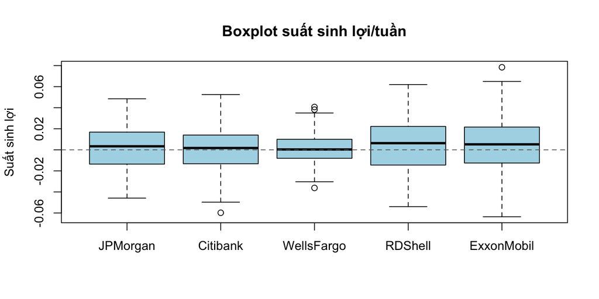

```r
boxplot(stock, col = "lightblue", main = "Boxplot suất sinh lợi/tuần", ylab = "Suất sinh lợi")
abline(h = 0, lty = 2, col = "grey40")
```

#### Giá trị chuẩn hóa từng biến

Tính các giá trị chuẩn hóa $z_{jk}=(x_{jk}-\bar x_k)/\sqrt{s_{kk}}$, $j=1,\dots,n$, $k=1,\dots,5$. Với cỡ mẫu vừa phải, giá trị $|z_{jk}|>3.5$ được xem là lớn bất thường.

```r
Z <- (X - rep(1, n) %*% t(colMeans(X))) / (rep(1, n) %*% t(sqrt(diag(cov(X)))))
round(apply(abs(Z), 2, max), 3)
```

```
##   JPMorgan   Citibank WellsFargo    RDShell ExxonMobil
##      2.278      2.886      2.611      2.158      2.688
```

```r
sum(abs(Z) > 3.5)
```

```
## [1] 0
```

Giá trị chuẩn hóa lớn nhất (trị tuyệt đối) của từng biến đều nhỏ hơn 3.5 (lớn nhất là 2.886) → không có giá trị bất thường theo từng biến.

#### Khoảng cách Mahalanobis (khoảng cách tổng quát bình phương)

Với mỗi quan trắc tính $d_j^2=(\mathbf x_j-\bar{\mathbf x})'\mathbf S^{-1}(\mathbf x_j-\bar{\mathbf x})$, $j=1,\dots,n$. Khi dữ liệu chuẩn $N_5$, $d_j^2$ xấp xỉ $\chi^2_5$, nên khoảng 5% số quan trắc sẽ có $d_j^2$ vượt phân vị $\chi^2_5(0.95)$ ngay cả khi không có ngoại lai; quan trắc ngoại lai được xác định bằng một phân vị cực trị hơn, ở đây dùng $\chi^2_5(0.995)$.

```r
xbar <- colMeans(X)
one  <- rep(1, n)
Xc   <- X - one %*% t(xbar)              # ma trận dữ liệu đã quy tâm
S    <- t(Xc) %*% Xc / (n - 1)           # ma trận hiệp phương sai mẫu S
S_inv <- solve(S)

d2 <- rowSums((Xc %*% S_inv) * Xc)       # d_j^2 cho từng tuần j
nguong_95  <- qchisq(0.95, df = p)
nguong_995 <- qchisq(0.995, df = p)
c(chi2_095 = nguong_95, chi2_0995 = nguong_995)
```

```
##  chi2_095 chi2_0995
##   11.0705   16.7496
```

```r
c(so_tuan_vuot_095 = sum(d2 > nguong_95), ky_vong = 0.05 * n)
```

```
## so_tuan_vuot_095          ky_vong
##             7.00             5.15
```

```r
sum(d2 > nguong_995)
```

```
## [1] 0
```

```r
round(max(d2), 3)
```

```
## [1] 15.507
```

Có 7 tuần có $d_j^2>\chi^2_5(0.95)=$ 11.07, gần với số kỳ vọng $0.05\times103\approx$ 5.2 tuần. Không có tuần nào vượt $\chi^2_5(0.995)=$ 16.75 ($d_j^2$ lớn nhất là 15.51) → **không có quan trắc ngoại lai**; dùng toàn bộ 103 quan trắc để xây dựng $\mathbf S$.

### Giả định chuẩn nhiều chiều (cần cho câu c)

Khoảng tin cậy cho $\lambda_i$ ở câu (c) giả định mẫu lấy từ $N_5(\boldsymbol\mu,\boldsymbol\Sigma)$. Ta kiểm tra bằng đồ thị chi bình phương (chi-square plot): sắp xếp $d^2_{(1)}\le\dots\le d^2_{(n)}$ và vẽ theo phân vị $\chi^2_5\big((j-\tfrac12)/n\big)$; nếu dữ liệu chuẩn, các điểm nằm gần đường thẳng $y=x$.

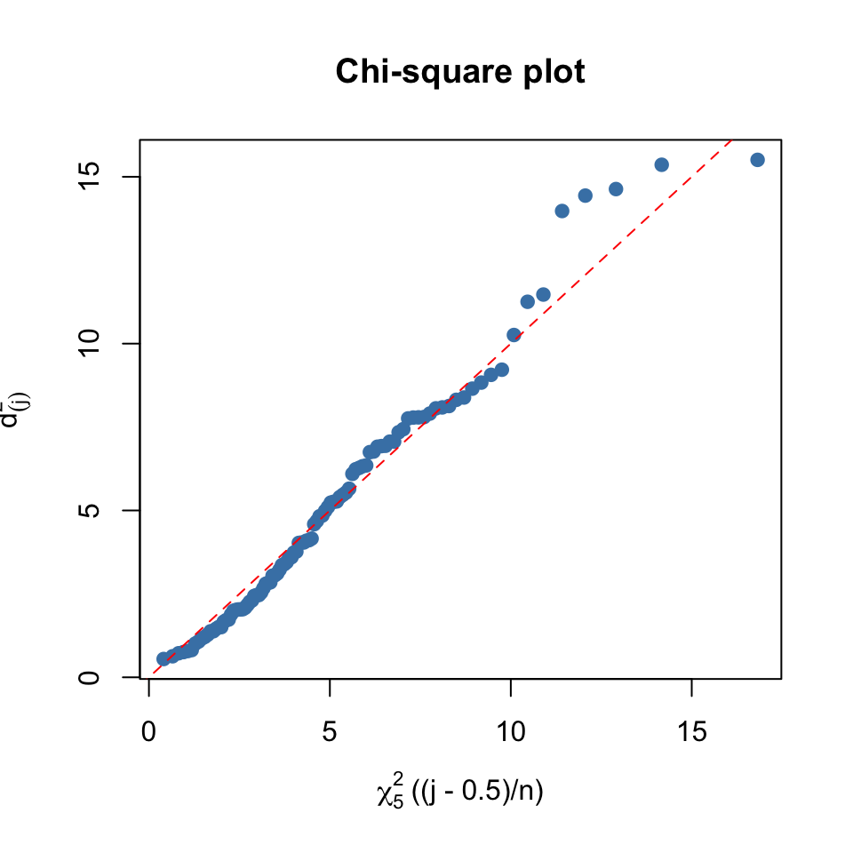

```r
d2_sap_xep <- sort(d2)
q_chi2 <- qchisq((1:n - 0.5) / n, df = p)
plot(q_chi2, d2_sap_xep, pch = 19, col = "steelblue",
     xlab = expression(chi[5]^2 ~ "((j - 0.5)/n)"), ylab = expression(d[(j)]^2),
     main = "Chi-square plot")
abline(0, 1, col = "red", lty = 2)
```

```r
# tỷ lệ d_j^2 nằm dưới trung vị chi^2_5 (kỳ vọng khoảng 50% nếu chuẩn)
mean(d2 <= qchisq(0.5, df = p))
```

```
## [1] 0.5242718
```

Các điểm nằm khá sát đường thẳng đi qua gốc tọa độ với hệ số góc 1, không có dạng cong có hệ thống; chỉ vài điểm ở đuôi trên hơi lệch lên (các tuần biến động mạnh). Tỷ lệ $d_j^2\le\chi^2_5(0.5)$ là 0.524, gần 0.5. → Giả định chuẩn nhiều chiều **chấp nhận được ở mức xấp xỉ**; vì vậy các khoảng tin cậy ở câu (c) được hiểu là **khoảng xấp xỉ** (n = 103 lớn).

## Độ lệch chuẩn và tương quan giữa các biến

### Độ lệch chuẩn từng biến

```r
s_kk <- diag(S)
round(sqrt(s_kk), 5)
```

```
##   JPMorgan   Citibank WellsFargo    RDShell ExxonMobil
##    0.02082    0.02095    0.01497    0.02688    0.02767
```

Độ lệch chuẩn của hai cổ phiếu dầu (≈ 0.0269 và 0.0277) lớn hơn ba cổ phiếu ngân hàng (≈ 0.015 – 0.0209), nhưng cùng bậc độ lớn và **cùng đơn vị**, không bị quá chênh lệch → làm PCA trên $\mathbf S$ (như đề yêu cầu), không cần chuẩn hóa; các biến dầu sẽ có trọng số lớn hơn trong thành phần chính đầu vì phương sai lớn hơn.

### Ma trận tương quan mẫu R

```r
D_can  <- diag(1 / sqrt(s_kk))          # D^{-1/2}
R <- D_can %*% S %*% D_can
dimnames(R) <- list(colnames(X), colnames(X))
round(R, 4)
```

```
##            JPMorgan Citibank WellsFargo RDShell ExxonMobil
## JPMorgan     1.0000   0.6323     0.5105  0.1146     0.1545
## Citibank     0.6323   1.0000     0.5741  0.3223     0.2127
## WellsFargo   0.5105   0.5741     1.0000  0.1825     0.1462
## RDShell      0.1146   0.3223     0.1825  1.0000     0.6834
## ExxonMobil   0.1545   0.2127     0.1462  0.6834     1.0000
```

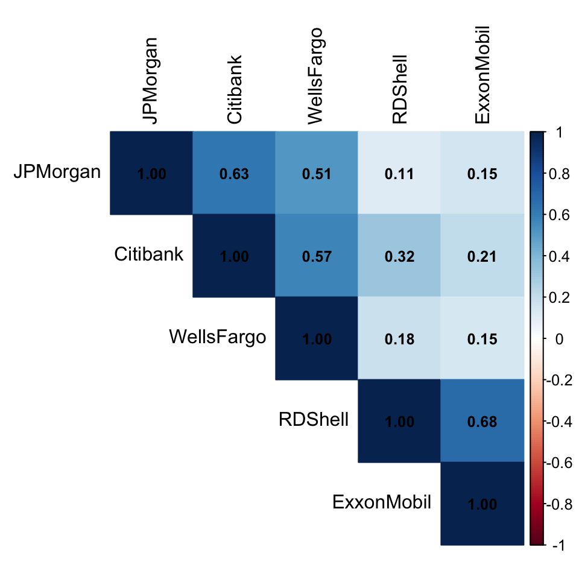

```r
corrplot::corrplot(R, method = "color", type = "upper", addCoef.col = "black",
                   number.cex = 0.8, tl.col = "black")
```

Ba cổ phiếu ngân hàng tương quan với nhau khá cao (0.51–0.63), hai cổ phiếu dầu tương quan với nhau cao nhất (0.68), còn tương quan chéo ngân hàng–dầu thấp (0.11–0.32) → có **hai nhóm biến** rõ rệt. Các biến tương quan dương đáng kể nên PCA có ý nghĩa.

## Câu (a) — Ma trận S và các thành phần chính mẫu

### Vectơ trung bình mẫu và ma trận hiệp phương sai mẫu S

$\bar{\mathbf x}=\frac1n\mathbf X'\mathbf 1$, $\quad\mathbf S=\frac{1}{n-1}(\mathbf X-\mathbf 1\bar{\mathbf x}')'(\mathbf X-\mathbf 1\bar{\mathbf x}')$ (đã tính ở mục Giá trị ngoại lai).

```r
round(xbar, 7)
```

```
##   JPMorgan   Citibank WellsFargo    RDShell ExxonMobil
##  0.0010628  0.0006554  0.0016261  0.0040491  0.0040386
```

```r
dimnames(S) <- list(colnames(X), colnames(X))
S
```

```
##                JPMorgan     Citibank   WellsFargo      RDShell   ExxonMobil
## JPMorgan   4.332695e-04 0.0002756679 1.590265e-04 6.411929e-05 8.896616e-05
## Citibank   2.756679e-04 0.0004387172 1.799737e-04 1.814512e-04 1.232623e-04
## WellsFargo 1.590265e-04 0.0001799737 2.239722e-04 7.341348e-05 6.054612e-05
## RDShell    6.411929e-05 0.0001814512 7.341348e-05 7.224964e-04 5.082772e-04
## ExxonMobil 8.896616e-05 0.0001232623 6.054612e-05 5.082772e-04 7.656742e-04
```

$\bar{\mathbf x}'=$ (0.0011, 0.0007, 0.0016, 0.0040, 0.0040). Ma trận $\mathbf S$ có các phần tử rất nhỏ (bậc $10^{-4}$) vì suất sinh lợi tuần chỉ khoảng vài phần trăm. Trên đường chéo, $s_{44}=$ 0.0007225 và $s_{55}=$ 0.0007657 (dầu) lớn khoảng 1.7 lần $s_{11},s_{22}$ và khoảng 3.2 lần $s_{33}$ (ngân hàng).

### Các cặp trị riêng – vectơ riêng của S

```r
eig_S <- eigen(S)
lambda_hat <- eig_S$values
V_hat <- eig_S$vectors
dimnames(V_hat) <- list(colnames(X), paste0("v", 1:p))

lambda_hat
```

```
## [1] 0.0013676780 0.0007011596 0.0002538024 0.0001426026 0.0001188868
```

```r
round(V_hat, 4)
```

```
##                v1      v2      v3      v4      v5
## JPMorgan   0.2228  0.6252  0.3261  0.6628  0.1177
## Citibank   0.3073  0.5704 -0.2496 -0.4141 -0.5886
## WellsFargo 0.1548  0.3445 -0.0376 -0.4970  0.7803
## RDShell    0.6390 -0.2479 -0.6425  0.3089  0.1485
## ExxonMobil 0.6509 -0.3218  0.6459 -0.2164 -0.0937
```

$\hat\lambda_1=$ 0.0013677 $\ge\hat\lambda_2=$ 0.00070116 $\ge\hat\lambda_3=$ 0.0002538 $\ge\hat\lambda_4=$ 0.0001426 $\ge\hat\lambda_5=$ 0.00011889 $\ge 0$; năm trị riêng phân biệt.

Kiểm tra $\{\hat{\mathbf v}_1,\dots,\hat{\mathbf v}_5\}$ là cơ sở trực chuẩn ($\hat{\mathbf V}'\hat{\mathbf V}=\mathbf I$) và $\hat{\mathbf V}'\mathbf S\hat{\mathbf V}=\text{diag}(\hat\lambda_1,\dots,\hat\lambda_5)$:

```r
round(t(V_hat) %*% V_hat, 10)
```

```
##    v1 v2 v3 v4 v5
## v1  1  0  0  0  0
## v2  0  1  0  0  0
## v3  0  0  1  0  0
## v4  0  0  0  1  0
## v5  0  0  0  0  1
```

```r
round(t(V_hat) %*% S %*% V_hat, 10)
```

```
##             v1           v2           v3           v4           v5
## v1 0.001367678 0.0000000000 0.0000000000 0.0000000000 0.0000000000
## v2 0.000000000 0.0007011596 0.0000000000 0.0000000000 0.0000000000
## v3 0.000000000 0.0000000000 0.0002538024 0.0000000000 0.0000000000
## v4 0.000000000 0.0000000000 0.0000000000 0.0001426026 0.0000000000
## v5 0.000000000 0.0000000000 0.0000000000 0.0000000000 0.0001188868
```

Ma trận thứ nhất là $\mathbf I_5$, ma trận thứ hai là ma trận chéo với các phần tử chéo đúng bằng $\hat\lambda_i$ → các vectơ riêng trực chuẩn và chéo hóa $\mathbf S$.

### Các thành phần chính mẫu

Thành phần chính mẫu thứ $i$ là $\hat y_i=\hat{\mathbf v}_i'\mathbf x=\hat v_{i1}x_1+\hat v_{i2}x_2+\dots+\hat v_{i5}x_5$, với $\text{var}(\hat y_i)=\hat\lambda_i$ và $\text{cov}(\hat y_i,\hat y_k)=0$, $i\ne k$:

$$\begin{aligned}
\hat y_1 &= 0.223\,x_1 + 0.307\,x_2 + 0.155\,x_3 + 0.639\,x_4 +
0.651\,x_5\\
\hat y_2 &= 0.625\,x_1 + (0.57)\,x_2 + (0.345)\,x_3 + (-0.248)\,x_4
+ (-0.322)\,x_5\\
\hat y_3 &= 0.326\,x_1 + (-0.25)\,x_2 + (-0.038)\,x_3 +
(-0.642)\,x_4 + (0.646)\,x_5\\
\hat y_4 &= 0.663\,x_1 + (-0.414)\,x_2 + (-0.497)\,x_3 +
(0.309)\,x_4 + (-0.216)\,x_5\\
\hat y_5 &= 0.118\,x_1 + (-0.589)\,x_2 + (0.78)\,x_3 + (0.148)\,x_4
+ (-0.094)\,x_5
\end{aligned}$$

(Vectơ riêng chỉ xác định đến dấu, nên đổi dấu toàn bộ một $\hat{\mathbf v}_i$ vẫn cho cùng thành phần chính.)

Điểm thành phần chính (scores) của từng tuần: $\hat y_{ji}=\hat{\mathbf v}_i'(\mathbf x_j-\bar{\mathbf x})$, tức ma trận $\hat{\mathbf Y}=(\mathbf X-\mathbf 1\bar{\mathbf x}')\hat{\mathbf V}$:

```r
Y_hat <- Xc %*% V_hat
colnames(Y_hat) <- paste0("y", 1:p)
round(head(Y_hat), 5)
```

```
##            y1       y2       y3       y4       y5
## [1,] -0.03112  0.01270  0.03833 -0.00149 -0.00470
## [2,]  0.01657  0.00608 -0.00026  0.00257 -0.01439
## [3,] -0.01500 -0.00999 -0.00816 -0.01196  0.01015
## [4,] -0.02227  0.02753  0.02099 -0.00026  0.01337
## [5,]  0.04140 -0.01432  0.01056  0.01082 -0.00956
## [6,]  0.00202 -0.00714 -0.00033  0.01954  0.00236
```

```r
# ma trận hiệp phương sai của các scores
round(t(Y_hat) %*% Y_hat / (n - 1), 10)
```

```
##             y1           y2           y3           y4           y5
## y1 0.001367678 0.0000000000 0.0000000000 0.0000000000 0.0000000000
## y2 0.000000000 0.0007011596 0.0000000000 0.0000000000 0.0000000000
## y3 0.000000000 0.0000000000 0.0002538024 0.0000000000 0.0000000000
## y4 0.000000000 0.0000000000 0.0000000000 0.0001426026 0.0000000000
## y5 0.000000000 0.0000000000 0.0000000000 0.0000000000 0.0001188868
```

Ma trận hiệp phương sai của các scores là ma trận chéo $\text{diag}(\hat\lambda_1,\dots,\hat\lambda_5)$ → đúng $\text{var}(\hat y_k)=\hat\lambda_k$ và $\text{cov}(\hat y_i,\hat y_k)=0$, $i\ne k$.

### Hệ số tương quan giữa thành phần chính và biến gốc

Hệ số $\hat v_{ik}$ cho biết **trọng số** của biến $x_k$ trong $\hat y_i$, nhưng độ lớn của nó còn phụ thuộc vào thang đo của $x_k$. Để đánh giá mức độ đóng góp của từng biến vào một thành phần chính, ta dùng thêm hệ số tương quan mẫu giữa $\hat y_i$ và $x_k$:

$$r_{\hat y_i,x_k}=\frac{\hat
v_{ik}\sqrt{\hat\lambda_i}}{\sqrt{s_{kk}}},\qquad
i,k=1,\dots,5.$$

```r
r_y_x <- matrix(0, p, p, dimnames = list(colnames(X), paste0("y", 1:p)))
for (i in 1:p) {
  r_y_x[, i] <- V_hat[, i] * sqrt(lambda_hat[i]) / sqrt(s_kk)
}
round(r_y_x, 3)
```

```
##               y1     y2     y3     y4     y5
## JPMorgan   0.396  0.795  0.250  0.380  0.062
## Citibank   0.543  0.721 -0.190 -0.236 -0.306
## WellsFargo 0.383  0.610 -0.040 -0.397  0.569
## RDShell    0.879 -0.244 -0.381  0.137  0.060
## ExxonMobil 0.870 -0.308  0.372 -0.093 -0.037
```

#### Tính chi tiết cho hai thành phần chính đầu

Với $\sqrt{\hat\lambda_1}=\sqrt{0.0013677}=$ 0.03698 và $\sqrt{\hat\lambda_2}=\sqrt{0.00070116}=$ 0.02648:

$$\begin{aligned}
r_{\hat y_1,x_4} &= \frac{\hat
v_{14}\sqrt{\hat\lambda_1}}{\sqrt{s_{44}}}=\frac{0.639\times0.03698}{0.02688}=0.879,
&
r_{\hat y_1,x_5} &= \frac{0.6509\times0.03698}{0.02767}=0.87,\\
r_{\hat y_1,x_1} &= \frac{0.2228\times0.03698}{0.02082}=0.396, &
r_{\hat y_1,x_2} &= \frac{0.3073\times0.03698}{0.02095}=0.543,\\
r_{\hat y_1,x_3} &= \frac{0.1548\times0.03698}{0.01497}=0.383; &
& \\
r_{\hat y_2,x_1} &= \frac{0.6252\times0.02648}{0.02082}=0.795, &
r_{\hat y_2,x_2} &= \frac{0.5704\times0.02648}{0.02095}=0.721,\\
r_{\hat y_2,x_3} &= \frac{0.3445\times0.02648}{0.01497}=0.61, &
r_{\hat y_2,x_4} &= \frac{-0.2479\times0.02648}{0.02688}=-0.244,\\
r_{\hat y_2,x_5} &= \frac{-0.3218\times0.02648}{0.02767}=-0.308.
& &
\end{aligned}$$

#### Thành phần chính thứ nhất $\hat y_1$

Trọng số của các biến trong $\hat y_1$ lần lượt là $\hat v_{11}\approx$ 0.22, $\hat v_{12}\approx$ 0.31, $\hat v_{13}\approx$ 0.15, $\hat v_{14}\approx$ 0.64, $\hat v_{15}\approx$ 0.65: cả 5 cùng dấu, trong đó trọng số của $x_4$ (Royal Dutch Shell) và $x_5$ (ExxonMobil) lớn gấp 2–4 lần trọng số của ba ngân hàng. Hệ số tương quan cho cùng kết luận:

- $r_{\hat y_1,x_4}\approx$ 0.88 và $r_{\hat y_1,x_5}\approx$ 0.87: tương quan **rất mạnh** — $\hat y_1$ gần như đi cùng với suất sinh lợi của hai cổ phiếu dầu.
- $r_{\hat y_1,x_2}\approx$ 0.54 (Citibank), $r_{\hat y_1,x_1}\approx$ 0.40 (JP Morgan), $r_{\hat y_1,x_3}\approx$ 0.38 (Wells Fargo): tương quan **dương, mức trung bình**.

Cả 5 tương quan đều cùng dấu dương, nên khi $\hat y_1$ tăng thì suất sinh lợi của cả 5 cổ phiếu đều có xu hướng tăng. Kết hợp hai nhận xét trên, $\hat y_1$ là **thành phần thị trường** (5 cổ phiếu cùng biến động), nhưng **chủ yếu phụ thuộc vào hai biến $x_4$ và $x_5$** (cổ phiếu dầu), do hai biến này có phương sai lớn nhất trong $\mathbf S$.

#### Thành phần chính thứ hai $\hat y_2$

Trọng số của ba ngân hàng là $\hat v_{21}\approx$ 0.63, $\hat v_{22}\approx$ 0.57, $\hat v_{23}\approx$ 0.34, ngược dấu với trọng số của hai cổ phiếu dầu $\hat v_{24}\approx$ -0.25, $\hat v_{25}\approx$ -0.32. Hệ số tương quan:

- $r_{\hat y_2,x_1}\approx$ 0.80, $r_{\hat y_2,x_2}\approx$ 0.72, $r_{\hat y_2,x_3}\approx$ 0.61: tương quan **mạnh** với cả ba ngân hàng, mạnh nhất là JP Morgan.
- $r_{\hat y_2,x_4}\approx$ -0.24, $r_{\hat y_2,x_5}\approx$ -0.31: tương quan **yếu và ngược dấu** với hai cổ phiếu dầu.

Như vậy $\hat y_2$ **chủ yếu phụ thuộc vào ba biến ngân hàng $x_1,x_2,x_3$** và có dấu ngược với nhóm dầu: $\hat y_2$ lớn khi ngân hàng tăng mạnh hơn dầu, nhỏ khi ngược lại → **thành phần ngành**. Điều này bổ sung cho $\hat y_1$: $\hat y_1$ chủ yếu “đại diện” cho nhóm dầu, còn $\hat y_2$ đại diện cho nhóm ngân hàng.

#### Thành phần chính thứ ba $\hat y_3$

$r_{\hat y_3,x_4}\approx$ -0.38 và $r_{\hat y_3,x_5}\approx$ 0.37 ngược dấu nhau, các tương quan còn lại nhỏ (0.25, -0.19, -0.04). Mọi tương quan đều ở mức yếu (|r| < 0.4) → $\hat y_3$ chỉ phản ánh **sự khác biệt giữa hai cổ phiếu dầu**, không đại diện tốt cho biến nào.

#### So sánh hệ số $\hat v_{ik}$ và tương quan $r_{\hat y_i,x_k}$

```r
data.frame(
  Bien = colnames(X),
  v1 = round(V_hat[, 1], 3), r_y1 = round(r_y_x[, 1], 3),
  thu_hang_v1 = rank(-abs(V_hat[, 1])), thu_hang_r1 = rank(-abs(r_y_x[, 1])),
  v2 = round(V_hat[, 2], 3), r_y2 = round(r_y_x[, 2], 3),
  thu_hang_v2 = rank(-abs(V_hat[, 2])), thu_hang_r2 = rank(-abs(r_y_x[, 2])),
  row.names = NULL
)
```

```
##         Bien    v1  r_y1 thu_hang_v1 thu_hang_r1     v2   r_y2 thu_hang_v2
## 1   JPMorgan 0.223 0.396           4           4  0.625  0.795           1
## 2   Citibank 0.307 0.543           3           3  0.570  0.721           2
## 3 WellsFargo 0.155 0.383           5           5  0.345  0.610           3
## 4    RDShell 0.639 0.879           2           1 -0.248 -0.244           5
## 5 ExxonMobil 0.651 0.870           1           2 -0.322 -0.308           4
##   thu_hang_r2
## 1           1
## 2           2
## 3           3
## 4           5
## 5           4
```

Hệ số tương quan chỉ đo đóng góp **riêng lẻ** của từng biến $x_k$ vào $\hat y_i$, không cho biết tầm quan trọng của $x_k$ khi có mặt các biến khác; vì vậy cần đọc cả hệ số $\hat v_{ik}$. Trong thực tế, biến có hệ số lớn (trị tuyệt đối) thường cũng có tương quan lớn, nên hai cách đánh giá thường cho kết quả giống nhau. Ở đây:

- Với $\hat y_2$, thứ hạng theo $|\hat v_{2k}|$ và theo $|r_{\hat y_2,x_k}|$ **trùng nhau hoàn toàn** (JP Morgan > Citibank > Wells Fargo > ExxonMobil > Royal Dutch Shell).
- Với $\hat y_1$, chỉ có hai cổ phiếu dầu đổi chỗ: ExxonMobil có hệ số lớn hơn một chút, nhưng Royal Dutch Shell có tương quan lớn hơn một chút (do $s_{44}<s_{55}$). Cả hai cách đều cho thấy hai cổ phiếu dầu quan trọng nhất trong $\hat y_1$.

#### Đóng góp của từng biến vào thành phần chính (contribution)

Đóng góp của biến $x_k$ vào thành phần chính $\hat y_i$: $\text{Contribution}_{ik}=100\,\hat v_{ik}^2$ (%). Vì $\hat{\mathbf v}_i$ có độ dài 1 nên tổng contribution trong mỗi thành phần bằng 100%; mức trung bình mỗi biến là $100/p=$ 20%.

```r
contrib <- 100 * V_hat^2
colnames(contrib) <- paste0("y", 1:p)
bang(data.frame(Bien = colnames(X), round(contrib, 2), row.names = NULL), digits = 2)
```

| Bien | y1 | y2 | y3 | y4 | y5 |
| --- | --- | --- | --- | --- | --- |
| JPMorgan | 4.97 | 39.09 | 10.63 | 43.92 | 1.38 |
| Citibank | 9.44 | 32.53 | 6.23 | 17.15 | 34.65 |
| WellsFargo | 2.40 | 11.87 | 0.14 | 24.71 | 60.89 |
| RDShell | 40.83 | 6.15 | 41.28 | 9.54 | 2.20 |
| ExxonMobil | 42.37 | 10.36 | 41.71 | 4.68 | 0.88 |

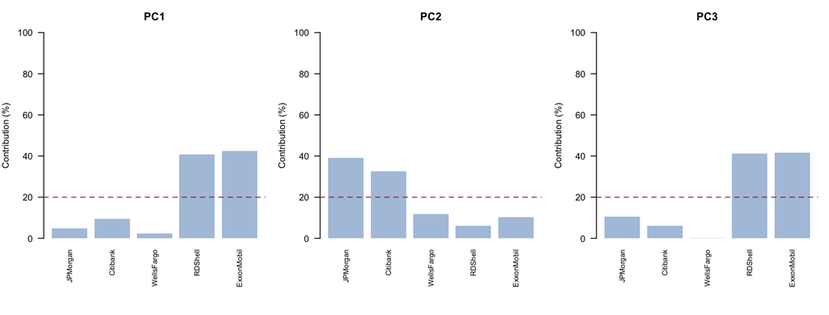

```r
par(mfrow = c(1, 3), mar = c(7, 4, 3, 1))
for (i in 1:3) {
  barplot(contrib[, i], las = 2, cex.names = 0.8, col = "lightsteelblue", border = NA,
          ylim = c(0, 100), ylab = "Contribution (%)", main = paste0("PC", i))
  abline(h = 100 / p, lty = 2, col = "firebrick")
}
```

```r
par(mfrow = c(1, 1))
```

- **$\hat y_1$:** Royal Dutch Shell (40.8%) và ExxonMobil (42.4%) chiếm tổng cộng 83.2%; ba ngân hàng đều dưới mức trung bình 20%.
- **$\hat y_2$:** JP Morgan (39.1%) và Citibank (32.5%) đóng góp nhiều nhất, Wells Fargo và hai cổ phiếu dầu khoảng 6–12% mỗi biến.
- **$\hat y_3$:** gần như chỉ do Royal Dutch Shell (41.3%) và ExxonMobil (41.7%).

Contribution chỉ dựa vào hệ số $\hat v_{ik}$ nên cho cùng thứ hạng với $|\hat v_{ik}|$; nó bổ sung cho tương quan ở trên ở chỗ cho biết phần trăm “cấu tạo” của từng thành phần.

#### Chất lượng biểu diễn của từng biến (cos²)

Chất lượng biểu diễn của biến $x_k$ trên $\hat y_i$ là $\cos^2_{ik}=r^2_{\hat y_i,x_k}$. Bình phương hệ số tương quan $r^2_{\hat y_i,x_k}=\hat v_{ik}^2\hat\lambda_i/s_{kk}$ là tỷ lệ phương sai của biến $x_k$ được giải thích bởi $\hat y_i$. Vì $\sum_{i=1}^{5}\hat v_{ik}^2\hat\lambda_i$ chính là phần tử $s_{kk}$ của $\mathbf S=\hat{\mathbf V}\hat{\boldsymbol\Lambda}\hat{\mathbf V}'$, nên $\sum_{i=1}^{5}r^2_{\hat y_i,x_k}=1$ với mỗi biến $x_k$.

```r
r2_y_x <- r_y_x^2
bang(data.frame(Bien = colnames(X), round(r2_y_x, 3),
                Tong_y1_y2 = round(r2_y_x[, 1] + r2_y_x[, 2], 3),
                Tong_tat_ca = round(rowSums(r2_y_x), 3),
                row.names = NULL), digits = 3)
```

| Bien | y1 | y2 | y3 | y4 | y5 | Tong_y1_y2 | Tong_tat_ca |
| --- | --- | --- | --- | --- | --- | --- | --- |
| JPMorgan | 0.157 | 0.633 | 0.062 | 0.145 | 0.004 | 0.789 | 1 |
| Citibank | 0.294 | 0.520 | 0.036 | 0.056 | 0.094 | 0.814 | 1 |
| WellsFargo | 0.146 | 0.372 | 0.002 | 0.157 | 0.323 | 0.518 | 1 |
| RDShell | 0.773 | 0.060 | 0.145 | 0.019 | 0.004 | 0.833 | 1 |
| ExxonMobil | 0.757 | 0.095 | 0.138 | 0.009 | 0.001 | 0.852 | 1 |

- $\hat y_1$ giải thích khoảng 77% phương sai của Royal Dutch Shell và 76% của ExxonMobil, nhưng chỉ 15%–29% phương sai của từng ngân hàng.
- $\hat y_2$ giải thích phần lớn phần còn lại của nhóm ngân hàng: 63% của JP Morgan, 52% của Citibank, 37% của Wells Fargo.
- Gộp hai thành phần đầu, $\hat y_1$ và $\hat y_2$ giải thích khoảng 79%–85% phương sai của JP Morgan, Citibank, Royal Dutch Shell, ExxonMobil, nhưng chỉ khoảng 52% của Wells Fargo; phần lớn phần còn lại của Wells Fargo nằm ở $\hat y_5$ (32%). Tức là Wells Fargo có biến động riêng đáng kể mà hai thành phần chung chưa nắm bắt được.
- Cột cuối bằng 1 với mọi biến, đúng tính chất $\sum_i r^2_{\hat y_i,x_k}=1$.

**Nhận xét chung:** $\hat y_1$ tương quan dương với cả 5 cổ phiếu và mạnh nhất với nhóm dầu; $\hat y_2$ tương quan mạnh với nhóm ngân hàng và ngược dấu, yếu với nhóm dầu; $\hat y_3,\hat y_4$ chỉ tương quan yếu với từng biến, $\hat y_5$ chỉ tương quan mức trung bình với riêng Wells Fargo ($r\approx$ 0.57). Hệ số tương quan củng cố cách hiểu $\hat y_1$ là thành phần thị trường và $\hat y_2$ là thành phần ngành.

### Ma trận hệ số tải (loadings)

Ma trận hệ số tải là ma trận $\hat{\mathbf V}=(\hat{\mathbf v}_1,\dots,\hat{\mathbf v}_5)$: cột thứ $i$ chứa các hệ số $\hat v_{ik}$ của biến $x_k$ trong thành phần chính $\hat y_i$. Hệ số tải cho biết mỗi biến đóng góp nhiều hay ít, cùng chiều hay ngược chiều vào từng thành phần chính.

```r
loadings <- V_hat
colnames(loadings) <- paste0("Comp.", 1:p)
round(loadings, 3)
```

```
##            Comp.1 Comp.2 Comp.3 Comp.4 Comp.5
## JPMorgan    0.223  0.625  0.326  0.663  0.118
## Citibank    0.307  0.570 -0.250 -0.414 -0.589
## WellsFargo  0.155  0.345 -0.038 -0.497  0.780
## RDShell     0.639 -0.248 -0.642  0.309  0.148
## ExxonMobil  0.651 -0.322  0.646 -0.216 -0.094
```

Cột `Comp.1` có 5 hệ số cùng dấu, lớn nhất ở RD Shell và ExxonMobil; cột `Comp.2` tách ba ngân hàng và hai cổ phiếu dầu thành hai nhóm ngược dấu.

#### Barplot hệ số tải của hai thành phần chính đầu

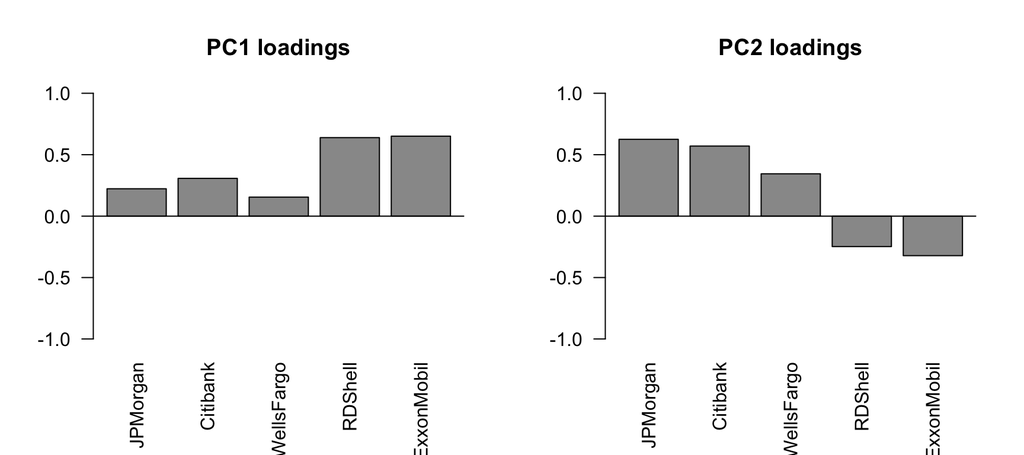

```r
par(mfrow = c(1, 2))
barplot(loadings[, 1], names.arg = colnames(X), las = 2, col = "grey60",
        ylim = c(-1, 1), main = "PC1 loadings")
abline(h = 0)
barplot(loadings[, 2], names.arg = colnames(X), las = 2, col = "grey60",
        ylim = c(-1, 1), main = "PC2 loadings")
abline(h = 0)
```

```r
par(mfrow = c(1, 1))
```

- **PC1:** cả 5 cột nằm cùng một phía của trục 0 → mọi cổ phiếu đóng góp cùng chiều vào $\hat y_1$; hai cột dầu (RDShell, ExxonMobil) cao nhất (≈ 0.64, 0.65), ba cột ngân hàng thấp hơn (≈ 0.15 – 0.31).
- **PC2:** ba cột ngân hàng nằm một phía, hai cột dầu nằm phía ngược lại → $\hat y_2$ là tương phản giữa ngành ngân hàng và ngành dầu; JP Morgan và Citibank có hệ số lớn nhất (≈ 0.63, 0.57).

#### Đồ thị loading

Mỗi biến được biểu diễn bằng một điểm có tọa độ (hệ số tải trên PC1, hệ số tải trên PC2).

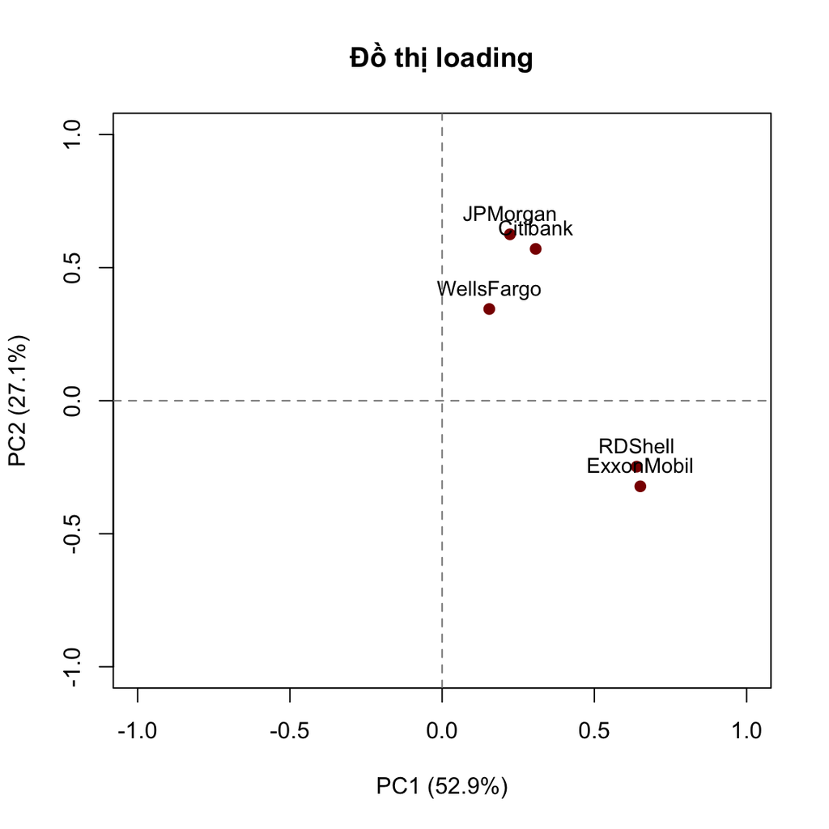

```r
plot(loadings[, 1], loadings[, 2], pch = 19, col = "darkred",
     xlim = c(-1, 1), ylim = c(-1, 1),
     xlab = paste0("PC1 (", round(100 * lambda_hat[1] / sum(lambda_hat), 1), "%)"),
     ylab = paste0("PC2 (", round(100 * lambda_hat[2] / sum(lambda_hat), 1), "%)"),
     main = "Đồ thị loading")
text(loadings[, 1], loadings[, 2], labels = colnames(X), pos = 3, cex = 0.9)
abline(h = 0, v = 0, lty = 2, col = "grey50")
```

Các biến tạo thành **hai cụm** tách biệt theo trục PC2: cụm ngân hàng (JPMorgan, Citibank, WellsFargo) và cụm dầu (RDShell, ExxonMobil). Trên trục PC1, cả 5 điểm nằm cùng một phía của 0, cụm dầu nằm xa gốc hơn. Các biến nằm gần nhau trên đồ thị là các biến tương quan mạnh với nhau — khớp với ma trận tương quan ở mục Ma trận tương quan mẫu R (ngân hàng tương quan với nhau, dầu tương quan với nhau, tương quan chéo thấp).

#### Đồ thị score

Mỗi tuần được biểu diễn bằng một điểm (vòng tròn) có tọa độ $(\hat y_{j1},\hat y_{j2})$ (score trên PC1, PC2), nhãn bên cạnh là số thứ tự tuần.

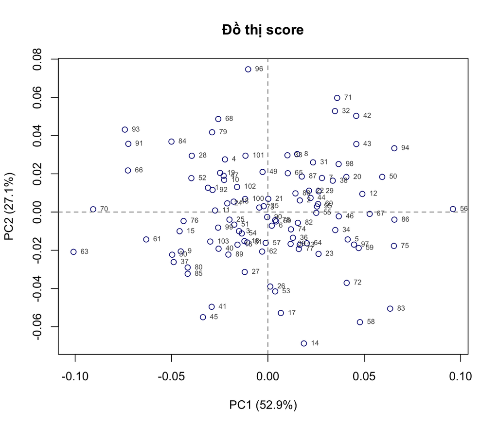

```r
plot(Y_hat[, 1], Y_hat[, 2], pch = 1, col = "navy",
     xlab = paste0("PC1 (", round(100 * lambda_hat[1] / sum(lambda_hat), 1), "%)"),
     ylab = paste0("PC2 (", round(100 * lambda_hat[2] / sum(lambda_hat), 1), "%)"),
     main = "Đồ thị score")
text(Y_hat[, 1], Y_hat[, 2], labels = 1:n, pos = 4, cex = 0.6, col = "grey30")
abline(h = 0, v = 0, lty = 2, col = "grey50")
```

```r
# các tuần có score cực trị trên PC1 và PC2
tuan_cuc_tri <- c(which.min(Y_hat[, 1]), which.max(Y_hat[, 1]),
                  which.min(Y_hat[, 2]), which.max(Y_hat[, 2]))
round(cbind(tuan = tuan_cuc_tri, X[tuan_cuc_tri, ], Y_hat[tuan_cuc_tri, 1:2]), 4)
```

```
##      tuan JPMorgan Citibank WellsFargo RDShell ExxonMobil      y1      y2
## [1,]   63  -0.0300  -0.0497    -0.0167 -0.0508    -0.0583 -0.1009 -0.0208
## [2,]   56   0.0188   0.0380     0.0155  0.0510     0.0784  0.0960  0.0016
## [3,]   14  -0.0459  -0.0278    -0.0143  0.0375     0.0332  0.0187 -0.0687
## [4,]   96   0.0257   0.0525     0.0407 -0.0317    -0.0188 -0.0102  0.0747
```

Các điểm phân tán quanh gốc (0, 0) — gốc ứng với một tuần có suất sinh lợi bằng trung bình — trải rộng theo trục PC1 hơn theo trục PC2 (vì $\hat\lambda_1>\hat\lambda_2$), không tách thành các nhóm rời nhau. Đọc theo hai trục:

- **Theo PC1 (thị trường):** tuần 63 và tuần 56 nằm ở hai đầu trục PC1. Bảng trên cho thấy ở tuần 63 cả 5 cổ phiếu cùng biến động mạnh theo một chiều, ở tuần 56 theo chiều ngược lại → điểm càng xa gốc theo PC1 là tuần thị trường chung biến động càng mạnh.
- **Theo PC2 (ngành):** tuần 14 và tuần 96 nằm ở hai đầu trục PC2. Ở các tuần này, nhóm ngân hàng và nhóm dầu đi ngược chiều nhau (một ngành tăng, ngành kia giảm) → điểm càng xa gốc theo PC2 là tuần mà hai ngành phân hóa càng mạnh.

#### 95% mật độ ellipsoid và các thành phần chính

Nếu ${\mathbf x}$ có phân phối chuẩn nhiều chiều thì $(\hat y_1,\hat y_2)$ xấp xỉ chuẩn với trung bình 0, không tương quan, phương sai $\hat\lambda_1,\hat\lambda_2$. Ellipse mật độ 95% trên mặt phẳng PC1–PC2 là tập các điểm thỏa

$$\frac{\hat
y_1^2}{\hat\lambda_1}+\frac{\hat
y_2^2}{\hat\lambda_2}\le\chi^2_2(0.95),$$

có tâm tại gốc, trục lớn theo hướng PC1 với nửa độ dài $\sqrt{\chi^2_2(0.95)\,\hat\lambda_1}$, trục nhỏ theo hướng PC2 với nửa độ dài $\sqrt{\chi^2_2(0.95)\,\hat\lambda_2}$. Hai mũi tên trên đồ thị là hai thành phần chính (hai trục của ellipse).

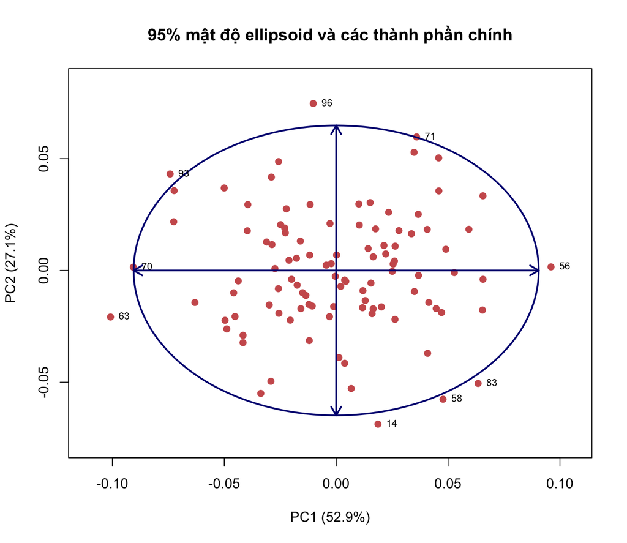

```r
chi2_95 <- qchisq(0.95, df = 2)
nua_truc_1 <- sqrt(chi2_95 * lambda_hat[1])
nua_truc_2 <- sqrt(chi2_95 * lambda_hat[2])
goc <- seq(0, 2 * pi, length.out = 300)

plot(Y_hat[, 1], Y_hat[, 2], pch = 19, col = "indianred", asp = 1,
     xlim = range(c(Y_hat[, 1], -nua_truc_1, nua_truc_1)) * 1.1,
     ylim = range(c(Y_hat[, 2], -nua_truc_2, nua_truc_2)) * 1.1,
     xlab = paste0("PC1 (", round(100 * lambda_hat[1] / sum(lambda_hat), 1), "%)"),
     ylab = paste0("PC2 (", round(100 * lambda_hat[2] / sum(lambda_hat), 1), "%)"),
     main = "95% mật độ ellipsoid và các thành phần chính")
lines(nua_truc_1 * cos(goc), nua_truc_2 * sin(goc), lwd = 2, col = "navy")
arrows(-nua_truc_1, 0, nua_truc_1, 0, code = 3, length = 0.12, lwd = 2, col = "navy")
arrows(0, -nua_truc_2, 0, nua_truc_2, code = 3, length = 0.12, lwd = 2, col = "navy")

# các tuần nằm ngoài ellipse 95%
d2_pc <- Y_hat[, 1]^2 / lambda_hat[1] + Y_hat[, 2]^2 / lambda_hat[2]
ngoai <- which(d2_pc > chi2_95)
text(Y_hat[ngoai, 1], Y_hat[ngoai, 2], labels = (1:n)[ngoai], pos = 4, cex = 0.7)
```

```r
c(nua_truc_1 = nua_truc_1, nua_truc_2 = nua_truc_2)
```

```
## nua_truc_1 nua_truc_2
## 0.09052290 0.06481491
```

```r
c(so_ngoai_ellipse = length(ngoai), ky_vong = 0.05 * n)
```

```
## so_ngoai_ellipse          ky_vong
##             9.00             5.15
```

```r
(1:n)[ngoai]
```

```
## [1] 14 56 58 63 70 71 83 93 96
```

Ellipse có tâm tại gốc (điểm trung bình), trục lớn nằm theo hướng PC1 với nửa độ dài 0.0905 và trục nhỏ theo hướng PC2 với nửa độ dài 0.0648; tỷ số hai trục $\sqrt{\hat\lambda_1/\hat\lambda_2}=$ 1.4 cho thấy dữ liệu trải rộng theo PC1 nhiều hơn theo PC2. Có 9 tuần nằm ngoài ellipse (14, 56, 58, 63, 70, 71, 83, 93, 96), so với khoảng 5.2 tuần kỳ vọng nếu dữ liệu chuẩn. Các tuần ngoài ellipse là những tuần thị trường hoặc hai ngành biến động mạnh (đã thấy ở hai đầu trục trong đồ thị score).

#### Đồ thị biplot

Biplot vẽ chồng đồ thị score (các tuần, dạng số thứ tự) và đồ thị loading (các biến, dạng mũi tên từ gốc) trên cùng một hệ trục PC1–PC2. Trục dưới/trái là thang của score, trục trên/phải là thang của loading.

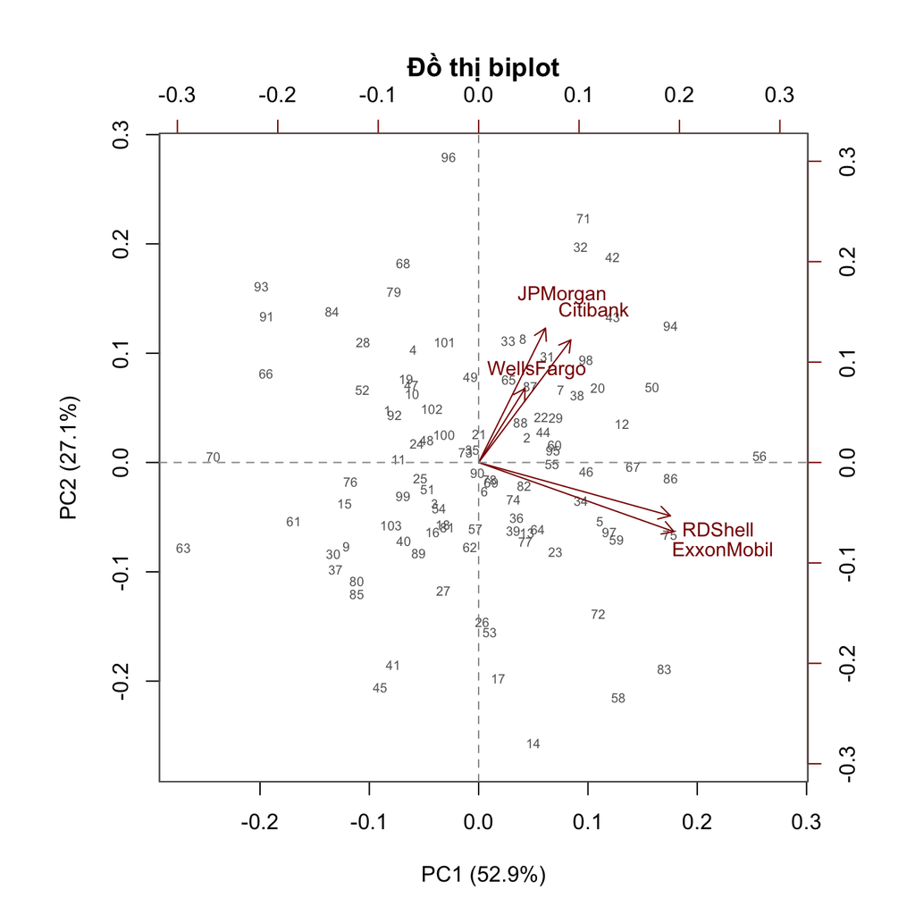

```r
pc_stock <- princomp(X, cor = FALSE)
biplot(pc_stock, choices = 1:2,
       col = c("grey40", "darkred"), cex = c(0.6, 0.9), expand = 0.8,
       xlab = paste0("PC1 (", round(100 * lambda_hat[1] / sum(lambda_hat), 1), "%)"),
       ylab = paste0("PC2 (", round(100 * lambda_hat[2] / sum(lambda_hat), 1), "%)"),
       main = "Đồ thị biplot")
abline(h = 0, v = 0, lty = 2, col = "grey60")
```

- **Mũi tên (biến):** ba mũi tên ngân hàng chụm lại một hướng, hai mũi tên dầu chụm lại hướng khác; góc giữa hai mũi tên càng nhỏ thì hai biến tương quan càng mạnh (xấp xỉ, vì biplot chỉ biểu diễn trên 2 thành phần đầu) → lại thấy hai nhóm ngân hàng và dầu. Mọi mũi tên đều có thành phần cùng chiều trên PC1 (thành phần thị trường), còn trên PC2 thì hai nhóm chỉ ngược chiều nhau (thành phần ngành).
- **Điểm (tuần) so với mũi tên:** tuần nằm xa gốc theo hướng của một mũi tên là tuần cổ phiếu đó có suất sinh lợi cao hơn trung bình; nằm ngược hướng là thấp hơn trung bình. Ví dụ tuần 56 nằm theo hướng chung của cả 5 mũi tên (cả 5 cổ phiếu cùng tăng mạnh), tuần 63 nằm ngược hướng (cả 5 cùng giảm mạnh); tuần 96 nằm về phía mũi tên ngân hàng (ngân hàng tăng, dầu giảm), tuần 14 nằm về phía mũi tên dầu (dầu tăng, ngân hàng giảm) — khớp với bảng ở đồ thị score.

**Kết luận câu (a):** Ma trận hiệp phương sai mẫu $\mathbf S$ như ở mục Vectơ trung bình mẫu và ma trận hiệp phương sai mẫu S. Năm thành phần chính mẫu là $\hat y_i=\hat{\mathbf v}_i'\mathbf x$, $i=1,\dots,5$, với hệ số cho ở mục Các thành phần chính mẫu và phương sai lần lượt $\hat\lambda_1=$ 0.001368, $\hat\lambda_2=$ 0.0007012, $\hat\lambda_3=$ 0.0002538, $\hat\lambda_4=$ 0.0001426, $\hat\lambda_5=$ 0.0001189; các thành phần chính đôi một không tương quan.

## Câu (b) — Tỷ số đóng góp vào phương sai suy rộng của 3 thành phần chính đầu

### Tính tỷ số đóng góp

Phương sai suy rộng (tổng phương sai mẫu) $=\text{tr}(\mathbf S)=\sum_{k}s_{kk}=\hat\lambda_1+\dots+\hat\lambda_5$. Tỷ số đóng góp của thành phần chính thứ $i$ là $\hat\lambda_i/\sum_k\hat\lambda_k$; tỷ lệ tích lũy của $q$ thành phần đầu là $r_q=\sum_{k=1}^q\hat\lambda_k/\sum_{k=1}^p\hat\lambda_k$.

```r
tong_phuong_sai <- sum(diag(S))
c(trace_S = tong_phuong_sai, tong_lambda = sum(lambda_hat))
```

```
##     trace_S tong_lambda
## 0.002584129 0.002584129
```

```r
ty_le     <- lambda_hat / sum(lambda_hat)
ty_le_tich_luy <- cumsum(lambda_hat) / sum(lambda_hat)

bang_ty_le <- data.frame(
  TPC = paste0("y", 1:p),
  lambda_hat = lambda_hat,
  Ty_le = round(ty_le, 4),
  Tich_luy = round(ty_le_tich_luy, 4)
)
bang(bang_ty_le, digits = 7)
```

| TPC | lambda_hat | Ty_le | Tich_luy |
| --- | --- | --- | --- |
| y1 | 0.0013677 | 0.5293 | 0.5293 |
| y2 | 0.0007012 | 0.2713 | 0.8006 |
| y3 | 0.0002538 | 0.0982 | 0.8988 |
| y4 | 0.0001426 | 0.0552 | 0.9540 |
| y5 | 0.0001189 | 0.0460 | 1.0000 |

$\text{tr}(\mathbf S)=$ 0.0025841 $=\sum\hat\lambda_k$. Cụ thể:

- $\hat y_1$: $\dfrac{\hat\lambda_1}{\sum\hat\lambda_k}=\dfrac{0.0013677}{0.0025841}=$ 52.93%
- $\hat y_2$: 27.13%; $\hat y_3$: 9.82%
- **Ba thành phần đầu:** $r_3=\dfrac{\hat\lambda_1+\hat\lambda_2+\hat\lambda_3}{\sum_{k=1}^5\hat\lambda_k}=$ **89.88%** (hai thành phần đầu: $r_2=$ 80.06%).

### Scree-plot

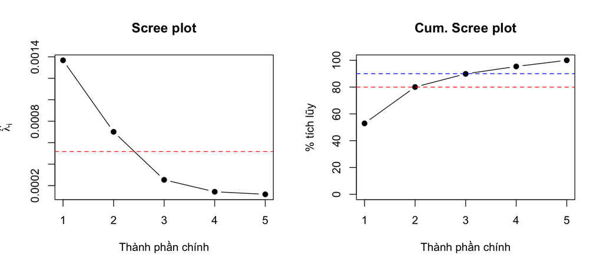

```r
par(mfrow = c(1, 2))
plot(1:p, lambda_hat, type = "b", pch = 19, xlab = "Thành phần chính", ylab = expression(hat(lambda)[i]),
     main = "Scree plot")
abline(h = mean(lambda_hat), col = "red", lty = 2)          # trung bình các trị riêng
plot(1:p, 100 * ty_le_tich_luy, type = "b", pch = 19, ylim = c(0, 100),
     xlab = "Thành phần chính", ylab = "% tích lũy", main = "Cum. Scree plot")
abline(h = c(80, 90), col = c("red", "blue"), lty = 2)
```

```r
par(mfrow = c(1, 1))
```

Scree plot giảm mạnh từ $\hat\lambda_1$ đến $\hat\lambda_2$ và $\hat\lambda_3$, sau đó gần như nằm ngang từ $\hat\lambda_3$ đến $\hat\lambda_5$ → “khuỷu tay” ở thành phần thứ 3. Đường đỏ (giá trị trung bình $\bar\lambda$) chỉ có $\hat\lambda_1,\hat\lambda_2$ nằm trên. Đường tích lũy vượt 80% tại $q=2$ và gần chạm 90% tại $q=3$.

### Ý nghĩa của ba thành phần chính đầu

```r
bang(data.frame(Bien = colnames(X), V_hat[, 1:3], row.names = NULL), digits = 3)
```

| Bien | v1 | v2 | v3 |
| --- | --- | --- | --- |
| JPMorgan | 0.223 | 0.625 | 0.326 |
| Citibank | 0.307 | 0.570 | -0.250 |
| WellsFargo | 0.155 | 0.345 | -0.038 |
| RDShell | 0.639 | -0.248 | -0.642 |
| ExxonMobil | 0.651 | -0.322 | 0.646 |

- **$\hat y_1$ – thành phần thị trường.** Cả 5 hệ số cùng dấu, nên $\hat y_1$ là một “chỉ số” có trọng số của cả 5 cổ phiếu: khi thị trường chung đi lên/xuống thì cả 5 cùng đi lên/xuống. Do dùng $\mathbf S$ (không chuẩn hóa), hai cổ phiếu dầu có phương sai lớn nhận trọng số lớn nhất (0.639, 0.651), ba ngân hàng trọng số nhỏ hơn. $\hat y_1$ giải thích 52.9% phương sai suy rộng.
- **$\hat y_2$ – thành phần ngành.** Ba cổ phiếu ngân hàng có hệ số cùng dấu (0.625, 0.57, 0.345), hai cổ phiếu dầu có hệ số ngược dấu (-0.248, -0.322) → $\hat y_2$ là **sự tương phản giữa nhóm ngân hàng và nhóm dầu lửa**, đo việc một ngành tăng tương đối so với ngành kia. Giải thích thêm 27.1%.
- **$\hat y_3$ – tương phản bên trong ngành dầu.** Hệ số lớn nhất về trị tuyệt đối là của Royal Dutch Shell (-0.642) và ExxonMobil (0.646), ngược dấu nhau → $\hat y_3$ chủ yếu đo **sự khác biệt giữa hai cổ phiếu dầu**, kèm một tương phản nhỏ JP Morgan – Citibank. Chỉ giải thích 9.8%.

**Kết luận câu (b):** Ba thành phần chính mẫu đầu tiên có tỷ số đóng góp vào phương sai suy rộng lần lượt là 52.93%, 27.13%, 9.82%, tổng cộng **89.88%**. Nghĩa là ba tổ hợp tuyến tính $\hat y_1,\hat y_2,\hat y_3$ (thị trường, ngành ngân hàng–dầu, khác biệt giữa hai cổ phiếu dầu) giữ lại khoảng 90% toàn bộ biến thiên của suất sinh lợi 5 cổ phiếu; phần còn lại (~10.1%) là biến thiên riêng lẻ của từng cổ phiếu.

## Câu (c) — Khoảng tin cậy đồng thời Bonferroni 90% cho λ₁, λ₂, λ₃

### Công thức

Giả thiết: $\mathbf X_1,\dots,\mathbf X_{103}$ là mẫu ngẫu nhiên từ $N_5(\boldsymbol\mu,\boldsymbol\Sigma)$ (mục Giả định chuẩn nhiều chiều), $\boldsymbol\Sigma$ xác định dương với các trị riêng phân biệt $\lambda_1>\lambda_2>\dots>\lambda_5>0$, và $n=103$ lớn. Khi đó $\hat\lambda_i$ xấp xỉ $N(\lambda_i,2\lambda_i^2/n)$ và độc lập nhau, cho khoảng tin cậy độ tin cậy $\gamma$:

$$\frac{\hat\lambda_i}{1+z_{(1+\gamma)/2}\sqrt{2/n}}\le\lambda_i\le\frac{\hat\lambda_i}{1-z_{(1+\gamma)/2}\sqrt{2/n}},$$

trong đó $z_{(1+\gamma)/2}$ là phân vị của phân phối $N(0,1)$ ở mức xác suất $(1+\gamma)/2$.

**Bonferroni cho $m$ trị riêng:** để $m$ khoảng đúng đồng thời với độ tin cậy ít nhất $\gamma$, mỗi khoảng được xây dựng ở độ tin cậy $\gamma^*=1-\frac{1-\gamma}{m}$, tức thay phân vị $z_{(1+\gamma)/2}$ bằng $z_{(1+\gamma^*)/2}=z_{1-\frac{1-\gamma}{2m}}$.

Ở đây $\gamma=0.90$, $m=3$: $\gamma^*=1-0.1/3$, phân vị cần dùng là $z_{1-0.1/6}=z_{0.98333}$.

### Tính toán

```r
gamma <- 0.90
m <- 3
muc_phan_vi <- 1 - (1 - gamma) / (2 * m)
z_bonf <- qnorm(muc_phan_vi)
c(muc_phan_vi = muc_phan_vi, z = z_bonf)
```

```
## muc_phan_vi           z
##   0.9833333   2.1280452
```

```r
can_duoi <- lambda_hat[1:m] / (1 + z_bonf * sqrt(2 / n))
can_tren <- lambda_hat[1:m] / (1 - z_bonf * sqrt(2 / n))

bang_ci <- data.frame(
  Tri_rieng = paste0("lambda_", 1:m),
  lambda_hat = lambda_hat[1:m],
  Can_duoi = can_duoi,
  Can_tren = can_tren
)
bang(bang_ci, digits = 7)
```

| Tri_rieng | lambda_hat | Can_duoi | Can_tren |
| --- | --- | --- | --- |
| lambda_1 | 0.0013677 | 0.0010549 | 0.0019442 |
| lambda_2 | 0.0007012 | 0.0005408 | 0.0009967 |
| lambda_3 | 0.0002538 | 0.0001958 | 0.0003608 |

$z_{0.98333}=$ 2.128, $\sqrt{2/n}=\sqrt{2/103}=$ 0.1393, nên $z\sqrt{2/n}=$ 0.2965 < 1 (mẫu số cận trên dương, công thức dùng được). Cụ thể:

- $\lambda_1$: $\dfrac{0.0013677}{1+0.2965}\le\lambda_1\le\dfrac{0.0013677}{1-0.2965}$ ⟹ **(0.001055; 0.001944)**
- $\lambda_2$: **(0.0005408; 0.0009967)**
- $\lambda_3$: **(0.0001958; 0.0003608)**

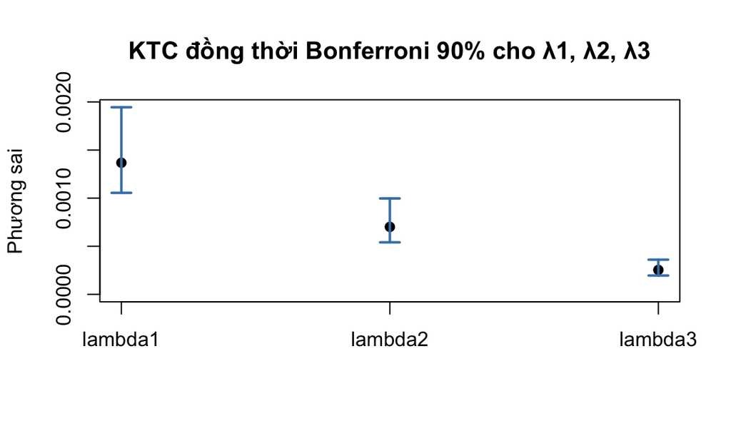

```r
plot(1:m, lambda_hat[1:m], ylim = c(0, max(can_tren)), pch = 19, xaxt = "n",
     xlab = "", ylab = "Phương sai", main = "KTC đồng thời Bonferroni 90% cho λ1, λ2, λ3")
axis(1, at = 1:m, labels = c("lambda1", "lambda2", "lambda3"))
arrows(1:m, can_duoi, 1:m, can_tren, angle = 90, code = 3, length = 0.08, col = "steelblue", lwd = 2)
```

Ba khoảng **không chồng lên nhau** (cận dưới của $\lambda_1$ > cận trên của $\lambda_2$; cận dưới của $\lambda_2$ > cận trên của $\lambda_3$) → với độ tin cậy ít nhất xấp xỉ 90%, $\lambda_1>\lambda_2>\lambda_3$ thực sự khác nhau. Các khoảng khá rộng (độ rộng tăng cùng tốc độ với $\hat\lambda_i$), nên cần thận trọng khi quyết định giữ hay bỏ thành phần chính chỉ dựa trên các giá trị $\hat\lambda_i$.

**Kết luận câu (c):** Với độ tin cậy đồng thời **ít nhất xấp xỉ 90%** (xấp xỉ vì dựa trên phân phối mẫu lớn và giả định chuẩn ở mục Giả định chuẩn nhiều chiều), ta có đồng thời $0.001055\le\lambda_1\le0.001944$, $\ 0.0005408\le\lambda_2\le0.0009967$, $\ 0.0001958\le\lambda_3\le0.0003608$.

## Câu (d) — Có thể thu gọn dữ liệu xuống ít hơn 5 chiều không?

### Ý nghĩa của từng thành phần chính

Để quyết định giữ bao nhiêu chiều, cần biết mỗi thành phần chính đại diện cho yếu tố gì. Ta đọc đồng thời hệ số $\hat v_{ik}$ (trọng số của biến $x_k$ trong $\hat y_i$) và tương quan $r_{\hat y_i,x_k}$ (mức độ $\hat y_i$ đại diện cho biến $x_k$):

```r
bang(data.frame(Bien = colnames(X), V_hat, row.names = NULL), digits = 3)
```

| Bien | v1 | v2 | v3 | v4 | v5 |
| --- | --- | --- | --- | --- | --- |
| JPMorgan | 0.223 | 0.625 | 0.326 | 0.663 | 0.118 |
| Citibank | 0.307 | 0.570 | -0.250 | -0.414 | -0.589 |
| WellsFargo | 0.155 | 0.345 | -0.038 | -0.497 | 0.780 |
| RDShell | 0.639 | -0.248 | -0.642 | 0.309 | 0.148 |
| ExxonMobil | 0.651 | -0.322 | 0.646 | -0.216 | -0.094 |

```r
bang(data.frame(Bien = colnames(X), r_y_x, row.names = NULL), digits = 3)
```

| Bien | y1 | y2 | y3 | y4 | y5 |
| --- | --- | --- | --- | --- | --- |
| JPMorgan | 0.396 | 0.795 | 0.250 | 0.380 | 0.062 |
| Citibank | 0.543 | 0.721 | -0.190 | -0.236 | -0.306 |
| WellsFargo | 0.383 | 0.610 | -0.040 | -0.397 | 0.569 |
| RDShell | 0.879 | -0.244 | -0.381 | 0.137 | 0.060 |
| ExxonMobil | 0.870 | -0.308 | 0.372 | -0.093 | -0.037 |

| TPC | Tỷ lệ phương sai | Cấu trúc hệ số | Ý nghĩa |
| --- | --- | --- | --- |
| $\hat y_1$ | 52.93% | Cả 5 hệ số cùng dấu; dầu (0.64, 0.65) lớn hơn ngân hàng (0.22, 0.31, 0.15) | **Thành phần thị trường**: biến động chung của cả 5 cổ phiếu theo tình hình kinh tế/thị trường. Tương quan với cả 5 biến đều dương (0.38 – 0.88) |
| $\hat y_2$ | 27.13% | Ngân hàng (0.63, 0.57, 0.34) ngược dấu với dầu (-0.25, -0.32) | **Thành phần ngành**: tuần mà cổ phiếu ngân hàng tăng mạnh hơn cổ phiếu dầu (hoặc ngược lại). Là yếu tố chính của nhóm ngân hàng (tương quan 0.61 – 0.80) |
| $\hat y_3$ | 9.82% | RD Shell (-0.64) ngược dấu ExxonMobil (0.65) | **Khác biệt giữa hai cổ phiếu dầu**: biến động riêng của từng công ty dầu, không phải của cả ngành |
| $\hat y_4$ | 5.52% | JP Morgan (0.66) ngược dấu Citibank (-0.41) và Wells Fargo (-0.50) | **Khác biệt giữa JP Morgan và hai ngân hàng còn lại**: biến động riêng của JP Morgan |
| $\hat y_5$ | 4.6% | Wells Fargo (0.78) ngược dấu Citibank (-0.59) | **Khác biệt giữa Wells Fargo và Citibank**: biến động riêng của hai ngân hàng này |

Như vậy chỉ $\hat y_1$ và $\hat y_2$ phản ánh các yếu tố **chung** (thị trường, ngành) tác động lên nhiều cổ phiếu cùng lúc; $\hat y_3,\hat y_4,\hat y_5$ chỉ là các **tương phản giữa từng cặp công ty** — biến thiên riêng của từng cổ phiếu, mỗi thành phần chỉ tương quan đáng kể với một, hai biến.

Diễn giải cụ thể từng thành phần:

- **$\hat y_1$ (thị trường).** Năm hệ số cùng dấu và năm tương quan đều dương, mạnh nhất với Royal Dutch Shell và ExxonMobil (0.88, 0.87), mức trung bình với ba ngân hàng. Các biến nổi bật không chia thành nhóm đối lập, nên $\hat y_1$ là hướng biến thiên **chung** của cả thị trường. Tuần có điểm $\hat y_1$ cao là tuần cả 5 cổ phiếu cùng có suất sinh lợi cao hơn trung bình (nổi bật nhất là cổ phiếu dầu); tuần có điểm thấp là tuần cả 5 cùng giảm.
- **$\hat y_2$ (ngành).** Biến nổi bật chia thành hai nhóm ngược dấu: ba ngân hàng (tương quan 0.61 – 0.80) và hai cổ phiếu dầu (-0.24, -0.31). $\hat y_2$ vì vậy không đo mức tăng/giảm chung mà **phân biệt hai ngành**. Tuần có điểm $\hat y_2$ cao là tuần cổ phiếu ngân hàng tăng mạnh hơn (hoặc giảm ít hơn) cổ phiếu dầu; điểm thấp là ngược lại.
- **$\hat y_3$ (khác biệt trong ngành dầu).** Hai biến nổi bật là Royal Dutch Shell (-0.64) và ExxonMobil (0.65), cùng ngành nhưng ngược dấu, các tương quan đều dưới 0.4. Tuần có điểm $\hat y_3$ cao là tuần hai cổ phiếu dầu đi lệch nhau theo một chiều (cổ phiếu có hệ số dương tăng hơn cổ phiếu có hệ số âm), tức biến động riêng của từng công ty dầu.
- **$\hat y_4$ (JP Morgan so với hai ngân hàng còn lại).** JP Morgan (0.66) ngược dấu với Citibank (-0.41) và Wells Fargo (-0.50); tuần có điểm $\hat y_4$ cao là tuần JP Morgan khác biệt so với hai ngân hàng kia theo chiều của hệ số.
- **$\hat y_5$ (Wells Fargo so với Citibank).** Wells Fargo (0.78) ngược dấu Citibank (-0.59); đây là thành phần duy nhất từ $\hat y_3$ trở đi có tương quan mức trung bình với một biến (Wells Fargo, $r\approx$ 0.57), cho thấy Wells Fargo có biến động riêng đáng kể.

### Chọn số thành phần chính

```r
lambda_tb <- mean(lambda_hat)                    # trung bình các trị riêng
data.frame(
  q = 1:p,
  lambda_hat = signif(lambda_hat, 4),
  Tich_luy_phan_tram = round(100 * ty_le_tich_luy, 2),
  Lambda_lon_hon_TB = lambda_hat > lambda_tb
)
```

```
##   q lambda_hat Tich_luy_phan_tram Lambda_lon_hon_TB
## 1 1  0.0013680              52.93              TRUE
## 2 2  0.0007012              80.06              TRUE
## 3 3  0.0002538              89.88             FALSE
## 4 4  0.0001426              95.40             FALSE
## 5 5  0.0001189             100.00             FALSE
```

```r
lambda_tb
```

```
## [1] 0.0005168259
```

1. **Tỷ lệ phương sai tích lũy:** cần 2 thành phần để đạt 70%, 2 thành phần để đạt 80% ($r_2=$ 80.06%) và 4 thành phần để đạt 90% ($r_3=$ 89.88%, sát ngưỡng 90%; $r_4=$ 95.4%). Với ngưỡng thường dùng 80% → giữ 2 thành phần.
2. **Scree-plot:** đường cong dốc từ $\hat\lambda_1$ đến $\hat\lambda_3$, sau đó gần như nằm ngang ($\hat\lambda_3,\hat\lambda_4,\hat\lambda_5$ nhỏ và gần bằng nhau) → khuỷu tay ở thành phần thứ 3; giữ các thành phần trên đoạn dốc trước khuỷu tay là 2 thành phần, nếu tính cả điểm khuỷu tay là 3.
3. **Tiêu chuẩn Kaiser** (giữ $\hat\lambda_q>\bar\lambda$): $\bar\lambda=$ 0.0005168; chỉ $\hat\lambda_1,\hat\lambda_2>\bar\lambda$ → giữ 2 thành phần.
4. **Câu (c):** ba khoảng tin cậy không chồng lên nhau → $\lambda_1,\lambda_2,\lambda_3$ khác nhau thực sự, nên $\hat y_1,\hat y_2,\hat y_3$ là các thành phần phân biệt (độ chính xác của vectơ riêng $\hat{\mathbf v}_i$ phụ thuộc vào mức khác biệt giữa các trị riêng; trị riêng tách biệt thì hướng $\hat{\mathbf v}_i$ ổn định). Các khoảng khá rộng nên quyết định giữ hay bỏ thành phần không dựa riêng vào $\hat\lambda_i$ mà kết hợp các tiêu chí 1–3 và ý nghĩa ở mục Ý nghĩa của từng thành phần chính.
5. **Ý nghĩa (mục Ý nghĩa của từng thành phần chính):** hai thành phần đầu là yếu tố chung có cách hiểu rõ ràng (thị trường, ngành); ba thành phần sau là biến thiên riêng của từng cặp công ty.

### Kết luận

**Kết luận câu (d):** **Có**, dữ liệu suất sinh lợi 5 cổ phiếu có thể thu gọn xuống ít hơn 5 chiều. Giữ **2 thành phần chính** là đủ:

- $\hat y_1$ — **thành phần thị trường** (biến động chung của cả 5 cổ phiếu), và
- $\hat y_2$ — **thành phần ngành** (tương phản ngân hàng – dầu lửa),

giải thích 80.1% phương sai suy rộng, thỏa ngưỡng 80% và tiêu chuẩn Kaiser; khoảng tin cậy ở câu (c) cho thấy $\lambda_1,\lambda_2$ lớn hơn thực sự so với $\lambda_3$. Nói cách khác, phần lớn biến thiên của suất sinh lợi 5 cổ phiếu trong giai đoạn 2004–2005 được giải thích bởi **hoạt động của thị trường chung** và **hoạt động riêng của từng ngành** (hai yếu tố không tương quan với nhau). Nếu muốn giữ khoảng 90% biến thiên (theo scree-plot), có thể dùng **3 chiều** ($r_3=$ 89.9%), thêm thành phần khác biệt giữa hai cổ phiếu dầu. Hai thành phần cuối ($\hat y_4,\hat y_5$, tổng cộng 10.1%) chỉ là biến thiên riêng của từng ngân hàng, có thể bỏ.

Hạn chế: hai thành phần giữ lại biểu diễn tốt bốn cổ phiếu (khoảng 79%–85% phương sai của mỗi biến, mục Hệ số tương quan giữa thành phần chính và biến gốc) nhưng chỉ khoảng 52% phương sai của Wells Fargo; phần lớn biến động riêng của Wells Fargo nằm ở $\hat y_5$ và bị bỏ đi khi thu gọn xuống 2 chiều.

# Bài 5.8 — PCA và ảnh hưởng của đơn vị đo

## Giới thiệu và đề bài

Bài 5.8 sử dụng dữ liệu của Ví dụ 5.3, gồm 61 quan trắc và 5 biến. Biến thứ năm $V_5$ (giá nhà) được đổi đơn vị từ **100.000 USD** sang **10.000 USD**: giá trị số của $V_5$ phải **nhân 10**. Bài yêu cầu: (a) suy ra ma trận hiệp phương sai mới. (b) xác định các cặp trị riêng–vector riêng và hai thành phần chính đầu. (c) tính tỷ lệ phương sai giải thích, tương quan giữa PC và biến, rồi so sánh với Ví dụ 5.3.

**Quy ước:** PCA trên ma trận hiệp phương sai mẫu, các biến được trừ trung bình. Vector riêng có thể đảo dấu mà không thay đổi PC về mặt hình học.

## Dữ liệu và kiểm tra đầu vào

```r
# đọc dữ liệu
raw <- read.table(path_data, header = FALSE, stringsAsFactors = FALSE,
                  fill = FALSE, comment.char = "")

if (ncol(raw) != 5L) stop(sprintf("Đọc được %d cột (kỳ vọng 5). Kiểm tra định dạng file DAT.", ncol(raw)))
if (!all(vapply(raw, is.numeric, logical(1)))) stop("Có cột không phải numeric; kiểm tra header và dấu phân cách.")
if (anyNA(raw)) stop("Dữ liệu có NA; cần kiểm tra trước khi PCA.")

names(raw) <- paste0("V", 1:5)
cat("Kích thước dữ liệu:", nrow(raw), "x", ncol(raw), "\n")
```

```
## Kích thước dữ liệu: 61 x 5
```

```r
print(utils::head(raw))
```

```
##     V1    V2    V3   V4   V5
## 1 2.67  5.71 69.02 30.3 1.48
## 2 2.25  4.37 72.98 43.3 1.44
## 3 3.12 10.27 64.94 32.0 2.11
## 4 5.14  7.44 71.29 24.5 1.85
## 5 5.54  9.25 74.94 31.0 2.23
## 6 5.04  4.84 53.61 48.2 1.60
```

```r
# kiểm tra đơn vị đo dựa trên trung bình của ví dụ 5.3
reference_mean <- c(4.469016, 3.962295, 71.419836, 26.914754, 1.635574)
mean_raw <- colMeans(raw)

# khôi phục đơn vị gốc nếu v5 đã được nhân 10
if (isTRUE(all.equal(mean_raw[1:4], reference_mean[1:4], tolerance = 0.01)) &&
    abs(mean_raw[5] - 10 * reference_mean[5]) < 0.05) {
  cen <- raw
  cen$V5 <- cen$V5 / 10
} else {
  cen <- raw
}

if (nrow(cen) != 61L) warning("Số dòng khác 61 như Ví dụ 5.3.")

# tính ma trận hiệp phương sai và tương quan
S0 <- cov(cen)
R0 <- cor(cen)

# hiển thị thống kê mô tả
descriptive_table <- data.frame(Variable = names(cen), Mean = colMeans(cen), SD = vapply(cen, sd, numeric(1)))

knitr::kable(descriptive_table, format = "html", digits = 5,
             col.names = c("Biến", "Trung bình", "Độ lệch chuẩn"),
             align = c("c", "r", "r"),
             caption = "Thống kê mô tả các biến trong dữ liệu ban đầu") |>
  kableExtra::kable_styling(full_width = FALSE, position = "center", font_size = 13) |>
  kableExtra::row_spec(0, bold = TRUE)
```

Thống kê mô tả các biến trong dữ liệu ban đầu

|  | Biến | Trung bình | Độ lệch chuẩn |
| --- | --- | --- | --- |
| V1 | V1 | 4.46902 | 1.84307 |
| V2 | V2 | 3.96230 | 3.11011 |
| V3 | V3 | 71.41984 | 7.45828 |
| V4 | V4 | 26.91475 | 9.43751 |
| V5 | V5 | 1.63557 | 0.56447 |

```r
# hiển thị ma trận hiệp phương sai ban đầu
knitr::kable(S0, format = "html", digits = 5,
             caption = "Ma trận hiệp phương sai của dữ liệu ban đầu") |>
  kableExtra::kable_styling(full_width = FALSE, position = "center", font_size = 13) |>
  kableExtra::row_spec(0, bold = TRUE)
```

Ma trận hiệp phương sai của dữ liệu ban đầu

|  | V1 | V2 | V3 | V4 | V5 |
| --- | --- | --- | --- | --- | --- |
| V1 | 3.39690 | -1.10214 | 4.30555 | -2.07829 | 0.02720 |
| V2 | -1.10214 | 9.67277 | -1.51324 | 10.95323 | 1.20306 |
| V3 | 4.30555 | -1.51324 | 55.62591 | -28.93746 | -0.04356 |
| V4 | -2.07829 | 10.95323 | -28.93746 | 89.06661 | 0.95730 |
| V5 | 0.02720 | 1.20306 | -0.04356 | 0.95730 | 0.31863 |

Ma trận hiệp phương sai mẫu được định nghĩa bởi

$$S_X=\frac{1}{n-1}\sum_{j=1}^n(x_j-\bar x)(x_j-\bar x)^T.$$

## Câu (a) — Biến đổi ma trận hiệp phương sai

Đặt $X=(V_1,V_2,V_3,V_4,V_5)^T$, $Z=DX$, với

$$D=\operatorname{diag}(1,1,1,1,10).$$

Do $\bar z=D\bar x$, ta có

$$\begin{aligned}
S_Z&=\frac{1}{n-1}\sum_{j=1}^n(z_j-\bar z)(z_j-\bar z)^T\\
&=\frac{1}{n-1}\sum_{j=1}^nD(x_j-\bar x)(x_j-\bar x)^TD^T\\
&=\boxed{DS_XD^T}.
\end{aligned}$$

Vì vậy, các phần tử ở góc $4\times4$ phía trên trái không đổi; các hiệp phương sai $s_{i5}=s_{5i}$, $i=1,\ldots,4$, nhân 10; riêng phương sai $s_{55}$ nhân 100.

```r
# cách 1: tính ma trận hiệp phương sai bằng công thức biến đổi tuyến tính
D <- diag(c(1, 1, 1, 1, 10))
colnames(D) <- rownames(D) <- names(cen)
S1 <- D %*% S0 %*% t(D)

# cách 2: tính trực tiếp ma trận hiệp phương sai từ dữ liệu sau đổi đơn vị
changed <- cen
changed$V5 <- 10 * changed$V5
S1_direct <- cov(changed)

# kiểm chứng kết quả của hai phương pháp
stopifnot(isTRUE(all.equal(unname(S1), unname(S1_direct), tolerance = 1e-10)))

# hiển thị ma trận hiệp phương sai
knitr::kable(S1, format = "html", digits = 5,
             align = rep("r", 5),
             caption = "Ma trận hiệp phương sai sau khi thay đổi đơn vị đo của V5") |>
  kableExtra::kable_styling(full_width = FALSE, position = "center", font_size = 13) |>
  kableExtra::row_spec(0, bold = TRUE)
```

Ma trận hiệp phương sai sau khi thay đổi đơn vị đo của V5

|  | V1 | V2 | V3 | V4 | V5 |
| --- | --- | --- | --- | --- | --- |
| V1 | 3.39690 | -1.10214 | 4.30555 | -2.07829 | 0.27204 |
| V2 | -1.10214 | 9.67277 | -1.51324 | 10.95323 | 12.03064 |
| V3 | 4.30555 | -1.51324 | 55.62591 | -28.93746 | -0.43559 |
| V4 | -2.07829 | 10.95323 | -28.93746 | 89.06661 | 9.57300 |
| V5 | 0.27204 | 12.03064 | -0.43559 | 9.57300 | 31.86251 |

Ma trận hiệp phương sai sau khi thay đổi đơn vị đo của biến $V_5$, được xác định bằng công thức biến đổi tuyến tính $S_1=DS_0D^T$, trùng khớp với ma trận hiệp phương sai được tính trực tiếp từ dữ liệu đã biến đổi, trong giới hạn sai số tính toán số học.

Khi so sánh với ma trận hiệp phương sai ban đầu $S_0$, các phần tử không liên quan đến $V_5$ được giữ nguyên. Ngược lại, các hiệp phương sai giữa $V_5$ và bốn biến còn lại tăng theo hệ số 10, trong khi phương sai của $V_5$ tăng theo hệ số 100.

Kết quả này xác nhận rằng việc thay đổi đơn vị đo có ảnh hưởng đến ma trận hiệp phương sai, mặc dù không làm thay đổi bản chất thông tin của dữ liệu.

## Câu (b) — Trị riêng, vector riêng và hai thành phần chính

Với $S_Zv_i=\lambda_i v_i$, $v_i^Tv_i=1$, sắp xếp $\lambda_1\ge\cdots\ge\lambda_5$. Hai thành phần chính đầu tiên là

$$Y_1=v_1^T(Z-\bar Z),\qquad Y_2=v_2^T(Z-\bar Z).$$

### Xác định các trị riêng của ma trận hiệp phương sai sau biến đổi

```r
# tính trị riêng và vector riêng trước và sau khi đổi đơn vị
eig0 <- eigen(S0, symmetric = TRUE)
eig1 <- eigen(S1, symmetric = TRUE)

# so sánh các trị riêng
eigenvalue_comparison <- data.frame(
  PC = paste0("PC", 1:5),
  Eigenvalue_Original = eig0$values,
  Eigenvalue_Changed = eig1$values,
  Difference = eig1$values - eig0$values
)

knitr::kable(eigenvalue_comparison, format = "html", digits = 5,
             col.names = c("PC", "Trước biến đổi", "Sau biến đổi", "Chênh lệch"),
             align = c("c", "r", "r", "r"),
             caption = "So sánh trị riêng trước và sau khi thay đổi đơn vị đo của V5") |>
  kableExtra::kable_styling(full_width = FALSE, position = "center", font_size = 13) |>
  kableExtra::row_spec(0, bold = TRUE) |>
  kableExtra::row_spec(0, extra_css = "border-bottom: 1px solid #999;") |>
  kableExtra::footnote(general = NULL)
```

So sánh trị riêng trước và sau khi thay đổi đơn vị đo của V5

| PC | Trước biến đổi | Sau biến đổi | Chênh lệch |
| --- | --- | --- | --- |
| PC1 | 107.01525 | 108.27194 | 1.25669 |
| PC2 | 39.67214 | 43.13967 | 3.46754 |
| PC3 | 8.37087 | 31.26713 | 22.89626 |
| PC4 | 2.86787 | 4.59810 | 1.73022 |
| PC5 | 0.15469 | 2.34787 | 2.19317 |

**Xác định các vector riêng và so sánh các vector riêng**

```r
# đặt tên các vector riêng
rownames(eig0$vectors) <- rownames(eig1$vectors) <- names(cen)
colnames(eig0$vectors) <- colnames(eig1$vectors) <- paste0("PC", 1:5)

# vector riêng trước khi đổi đơn vị
knitr::kable(
  eig0$vectors,
  caption = "Các vector riêng của ma trận hiệp phương sai ban đầu"
)
```

Các vector riêng của ma trận hiệp phương sai ban đầu

|  | PC1 | PC2 | PC3 | PC4 | PC5 |
| --- | --- | --- | --- | --- | --- |
| V1 | 0.0388873 | -0.0711449 | -0.1878926 | 0.9771352 | -0.0576999 |
| V2 | -0.1053220 | -0.1297524 | 0.9609958 | 0.1713518 | -0.1385541 |
| V3 | 0.4923639 | -0.8643881 | -0.0457974 | -0.0910437 | 0.0049660 |
| V4 | -0.8630699 | -0.4803318 | -0.1531854 | -0.0296858 | 0.0066918 |
| V5 | -0.0091223 | -0.0147434 | 0.1249811 | 0.0817012 | 0.9886375 |

```r
# vector riêng sau khi đổi đơn vị
knitr::kable(
  eig1$vectors,
  caption = "Các vector riêng của ma trận hiệp phương sai sau biến đổi"
)
```

Các vector riêng của ma trận hiệp phương sai sau biến đổi

|  | PC1 | PC2 | PC3 | PC4 | PC5 |
| --- | --- | --- | --- | --- | --- |
| V1 | 0.0376288 | -0.0623092 | -0.0399794 | 0.5555317 | 0.8273378 |
| V2 | -0.1189296 | -0.2493010 | 0.2605248 | -0.7683923 | 0.5151746 |
| V3 | 0.4796729 | -0.7596765 | -0.4306487 | -0.0280790 | -0.0809858 |
| V4 | -0.8589118 | -0.3163999 | -0.3936442 | 0.0686738 | -0.0498985 |
| V5 | -0.1289352 | -0.5067043 | 0.7681891 | 0.3089551 | -0.2026298 |

Kết quả phân rã trị riêng cho thấy việc thay đổi đơn vị đo của biến $V_5$ làm thay đổi các hệ số trong vector riêng của ma trận hiệp phương sai.

Đối với thành phần chính thứ nhất (PC1), các hệ số có trị tuyệt đối lớn nhất vẫn thuộc về $V_3$ và $V_4$, với dấu trái ngược. Điều này cho thấy PC1 tiếp tục phản ánh chủ yếu sự tương phản giữa hai biến này. Tuy nhiên, hệ số của $V_5$ tăng về trị tuyệt đối, thể hiện sự thay đổi trong hướng thành phần chính.

Đối với PC2, hệ số của $V_5$ thay đổi đáng kể, từ $-0.0147434$ lên $-0.5067043$, cho thấy biến này có vai trò lớn hơn trong tổ hợp tuyến tính xác định PC2 sau biến đổi.

Đặc biệt, trước biến đổi, vector riêng thứ năm gần như trùng với hướng của $V_5$, với hệ số bằng $0.9886375$. Sau biến đổi, $V_5$ trở thành biến có hệ số lớn nhất trong vector riêng thứ ba, bằng $0.7681891$.

### Phương trình 2 thành phần chính đầu tiên sau biến đổi

```r
# xây dựng phương trình thành phần chính từ vector riêng
pc_equation <- function(v, pc_name) {
  terms <- vapply(seq_along(v), function(j) {
    paste0(
      "(", sprintf("%.17g", v[j]), ")",
      "(Z_", j, "-\\bar{Z}_", j, ")"
    )
  }, character(1))

  paste0(pc_name, " = ", paste(terms, collapse = " + "))
}

cat("$$\n", pc_equation(eig1$vectors[, 1], "Y_1"), "\n$$\n\n")
```

$$Y_1 = (0.03762881353285967)(Z_1-\bar{Z}_1) +
(-0.11892963974296457)(Z_2-\bar{Z}_2) +
(0.47967291184499478)(Z_3-\bar{Z}_3) +
(-0.85891177054693113)(Z_4-\bar{Z}_4) +
(-0.12893518232351497)(Z_5-\bar{Z}_5)$$

```r
cat("$$\n", pc_equation(eig1$vectors[, 2], "Y_2"), "\n$$\n\n")
```

$$Y_2 = (-0.062309153487031713)(Z_1-\bar{Z}_1) +
(-0.24930104569347555)(Z_2-\bar{Z}_2) +
(-0.75967654168934107)(Z_3-\bar{Z}_3) +
(-0.31639988655396206)(Z_4-\bar{Z}_4) +
(-0.50670427450677014)(Z_5-\bar{Z}_5)$$

### Tính PC scores cho hai thành phần chính đầu tiên

```r
# trừ trung bình các biến sau khi đổi đơn vị
Zc <- scale(changed, center = TRUE, scale = FALSE)

# tính điểm các thành phần chính
scores1 <- as.matrix(Zc) %*% eig1$vectors
colnames(scores1) <- paste0("PC", 1:5)

# chuẩn bị bảng điểm của 6 quan sát đầu tiên
scores_table <- data.frame(
  Observation = paste0("Quan sát ", 1:6),
  PC1 = scores1[1:6, 1],
  PC2 = scores1[1:6, 2]
)

# trình bày bảng html
knitr::kable(
  scores_table,
  format = "html",
  digits = 5,
  col.names = c("Quan sát", "PC1", "PC2"),
  align = c("c", "r", "r"),
  caption = "Bảng b.3. Điểm số hai thành phần chính của 6 quan sát đầu tiên"
) |>
  kableExtra::kable_styling(
    bootstrap_options = c("striped", "hover", "condensed"),
    full_width = FALSE,
    position = "center",
    font_size = 13
  ) |>
  kableExtra::add_header_above(
    c(" " = 1, "Điểm thành phần chính (PC scores)" = 2)
  ) |>
  kableExtra::column_spec(
    2:3,
    bold = TRUE
  )
```

Bảng b.3. Điểm số hai thành phần chính của 6 quan sát đầu tiên

| Quan sát | Điểm thành phần chính (PC scores) PC1 | Điểm thành phần chính (PC scores) PC2 |
| --- | --- | --- |
| Quan sát 1 | -4.13372 | 1.21670 |
| Quan sát 2 | -13.20494 | -5.34191 |
| Quan sát 3 | -8.88862 | -0.57879 |
| Quan sát 4 | 1.34696 | -1.13265 |
| Quan sát 5 | -3.17533 | -8.36370 |
| Quan sát 6 | -26.86208 | 6.72093 |

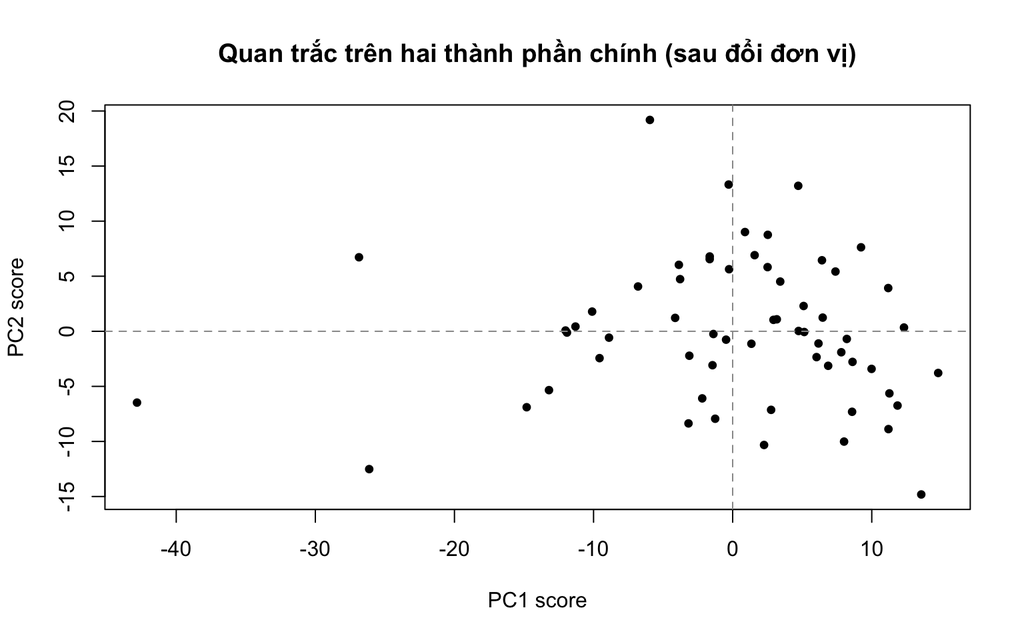

```r
plot(scores1[, 1], scores1[, 2], pch = 19, cex = 0.75,
     xlab = "PC1 score", ylab = "PC2 score",
     main = "Quan trắc trên hai thành phần chính (sau đổi đơn vị)")
abline(h = 0, v = 0, lty = 2, col = "gray60")
```

### Kiểm chứng phương sai PC bằng trị riêng

```r
# tính phương sai mẫu của các điểm thành phần chính
score_variance <- diag(cov(scores1))

# đối chiếu phương sai với trị riêng tương ứng
variance_check <- data.frame(
  PC = paste0("PC", 1:5),
  Eigenvalue = eig1$values,
  Score_Variance = score_variance,
  Difference = score_variance - eig1$values
)

knitr::kable(
  variance_check,
  caption = "Kiểm chứng phương sai các thành phần chính bằng trị riêng"
)
```

Kiểm chứng phương sai các thành phần chính bằng trị riêng

|  | PC | Eigenvalue | Score_Variance | Difference |
| --- | --- | --- | --- | --- |
| PC1 | PC1 | 108.271939 | 108.271939 | 0 |
| PC2 | PC2 | 43.139674 | 43.139674 | 0 |
| PC3 | PC3 | 31.267127 | 31.267127 | 0 |
| PC4 | PC4 | 4.598098 | 4.598098 | 0 |
| PC5 | PC5 | 2.347868 | 2.347868 | 0 |

```r
# kiểm tra sự phù hợp trong sai số tính toán
stopifnot(isTRUE(all.equal(
  unname(score_variance),
  unname(eig1$values),
  tolerance = 1e-8
)))
```

## Câu (c) — Tỷ lệ phương sai giải thích và tương quan giữa các biến với thành phần chính

### Tỷ lệ phương sai giải thích (Proportion of Variance Explained — PVE)

**Cơ sở lý thuyết**

Trong phân tích thành phần chính (Principal Component Analysis — PCA) dựa trên ma trận hiệp phương sai, mỗi trị riêng của ma trận hiệp phương sai biểu thị phương sai của thành phần chính tương ứng:

$$\operatorname{Var}(PC_i)=\lambda_i,
\qquad i=1,\ldots,5.$$

Tổng phương sai của dữ liệu bằng tổng các trị riêng của ma trận hiệp phương sai:

$$\operatorname{tr}(S)
=\sum_{j=1}^{5}s_{jj}
=\sum_{i=1}^{5}\lambda_i.$$

Tỷ lệ phương sai được giải thích bởi thành phần chính thứ $i$ được xác định bởi:

$$\boxed{
\operatorname{PVE}_i
=\frac{\lambda_i}{\sum_{j=1}^{5}\lambda_j}
}$$

Tỷ lệ phương sai giải thích tích lũy của $k$ thành phần chính đầu tiên (Cumulative Proportion of Variance Explained — CPVE) là:

$$\boxed{
\operatorname{CPVE}_k
=\sum_{i=1}^{k}\operatorname{PVE}_i
=\frac{\sum_{i=1}^{k}\lambda_i}
{\sum_{j=1}^{5}\lambda_j}
}$$

Trong đó:

- $\lambda_i$ là trị riêng thứ $i$ của ma trận hiệp phương sai.
- $\operatorname{PVE}_i$ là tỷ lệ tổng phương sai được giải thích bởi PC thứ $i$.
- $\operatorname{CPVE}_k$ là tỷ lệ tổng phương sai được giải thích bởi $k$ thành phần chính đầu tiên.

Các tỷ lệ này được nhân với $100$ khi biểu diễn dưới dạng phần trăm.

**Bảng so sánh PVE và CPVE trước và sau biến đổi**

```r
# tính tỷ lệ phương sai giải thích
pve0 <- eig0$values / sum(eig0$values)
pve1 <- eig1$values / sum(eig1$values)

# tạo bảng pve và cpve
variance_table <- data.frame(
  PC = paste0("PC", 1:5),
  PVE_Original = 100 * pve0,
  CPVE_Original = 100 * cumsum(pve0),
  PVE_Changed = 100 * pve1,
  CPVE_Changed = 100 * cumsum(pve1)
)

# trình bày bảng theo nhóm cột
knitr::kable(
  variance_table,
  format = "html",
  digits = 4,
  col.names = c("PC", "PVE (%)", "CPVE (%)", "PVE (%)", "CPVE (%)"),
  align = c("c", "r", "r", "r", "r"),
  caption = "Bảng c.1. Tỷ lệ phương sai giải thích trước và sau biến đổi",
  escape = TRUE
) |>
  kableExtra::kable_styling(
    bootstrap_options = c("striped", "hover", "condensed"),
    full_width = FALSE,
    position = "center",
    font_size = 13
  ) |>
  kableExtra::add_header_above(
    c(" " = 1, "Trước biến đổi" = 2, "Sau biến đổi" = 2)
  ) |>
  kableExtra::row_spec(
    2,
    bold = TRUE
  )
```

Bảng c.1. Tỷ lệ phương sai giải thích trước và sau biến đổi

| PC | Trước biến đổi PVE (%) | Trước biến đổi CPVE (%) | Sau biến đổi PVE (%) | Sau biến đổi CPVE (%) |
| --- | --- | --- | --- | --- |
| PC1 | 67.6965 | 67.6965 | 57.0980 | 57.0980 |
| PC2 | 25.0961 | 92.7927 | 22.7500 | 79.8480 |
| PC3 | 5.2953 | 98.0880 | 16.4890 | 96.3370 |
| PC4 | 1.8142 | 99.9021 | 2.4248 | 98.7618 |
| PC5 | 0.0979 | 100.0000 | 1.2382 | 100.0000 |

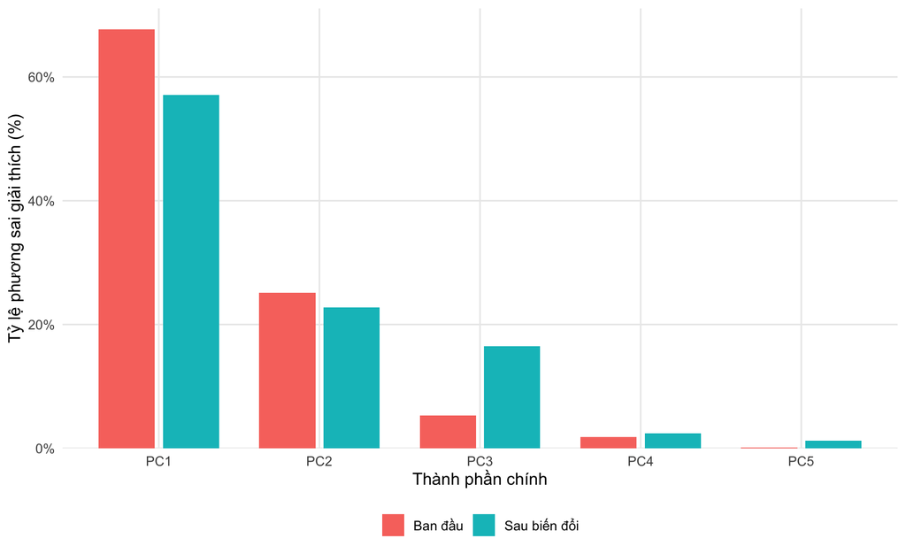

So sánh tỷ lệ phương sai giải thích trước và sau khi thay đổi đơn vị đo của V5

```r
# chuẩn bị dữ liệu cho biểu đồ
pve_plot_data <- data.frame(
  PC = factor(
    rep(paste0("PC", 1:5), 2),
    levels = paste0("PC", 1:5)
  ),
  PVE = c(100 * pve0, 100 * pve1),
  Group = rep(c("Ban đầu", "Sau biến đổi"), each = 5)
)

# vẽ biểu đồ cột so sánh
ggplot2::ggplot(
  pve_plot_data,
  ggplot2::aes(x = PC, y = PVE, fill = Group)
) +
  ggplot2::geom_col(
    position = ggplot2::position_dodge(width = 0.8),
    width = 0.7
  ) +
  ggplot2::scale_y_continuous(
    labels = function(x) paste0(x, "%"),
    expand = ggplot2::expansion(mult = c(0, 0.05))
  ) +
  ggplot2::labs(
    x = "Thành phần chính",
    y = "Tỷ lệ phương sai giải thích (%)",
    fill = NULL
  ) +
  ggplot2::theme_minimal(base_size = 12) +
  ggplot2::theme(
    legend.position = "bottom",
    panel.grid.minor = ggplot2::element_blank()
  )
```

Trong khi đó, tỷ lệ phương sai giải thích của PC3 tăng đáng kể. Kết quả này phù hợp với sự thay đổi của các trị riêng và vector riêng đã được tính ở câu (b).

Như vậy, việc thay đổi đơn vị đo đã làm thay đổi sự phân bổ phương sai giữa các thành phần chính, từ đó có thể ảnh hưởng đến quyết định lựa chọn số thành phần chính khi thực hiện giảm chiều dữ liệu.

### Tương quan giữa các biến và thành phần chính

Bên cạnh việc xác định tỷ lệ phương sai giải thích, ta cần xem xét mức độ liên hệ tuyến tính giữa các biến ban đầu và các thành phần chính.

Gọi $\mathbf{v}_i=(v_{1i},\ldots,v_{5i})^T$ là vector riêng ứng với trị riêng $\lambda_i$ của ma trận hiệp phương sai.

Thành phần chính thứ $i$ được xác định bởi:

$$PC_i
=\mathbf{v}_i^T(\mathbf{Z}-\bar{\mathbf{Z}})
=\sum_{k=1}^{5}v_{ki}(Z_k-\bar Z_k).$$

Theo định nghĩa hệ số tương quan mẫu:

$$\widehat{\operatorname{Corr}}(PC_i,Z_k)
=
\frac{
\widehat{\operatorname{Cov}}(PC_i,Z_k)
}{
\sqrt{\widehat{\operatorname{Var}}(PC_i)}
\sqrt{\widehat{\operatorname{Var}}(Z_k)}
}.$$

Do $\mathbf{S}_1\mathbf{v}_i=\lambda_i\mathbf{v}_i$, ta có:

$$\widehat{\operatorname{Cov}}(PC_i,Z_k)
=
\lambda_i v_{ki}.$$

Mặt khác:

$$\widehat{\operatorname{Var}}(PC_i)=\lambda_i,
\qquad
\widehat{\operatorname{Var}}(Z_k)=s_{kk}^{(Z)}.$$

Suy ra công thức tính hệ số tương quan giữa thành phần chính thứ $i$ và biến thứ $k$:

$$\boxed{
\widehat{\operatorname{Corr}}(PC_i,Z_k)
=
\frac{\sqrt{\lambda_i}\,v_{ki}}
{\sqrt{s_{kk}^{(Z)}}}
}$$

Trong đó:

- $\lambda_i$ là trị riêng tương ứng với thành phần chính thứ $i$.
- $v_{ki}$ là phần tử thứ $k$ của vector riêng thứ $i$.
- $s_{kk}^{(Z)}$ là phương sai mẫu của biến thứ $k$ sau biến đổi.

Hệ số tương quan có giá trị trong đoạn $[-1,1]$. Giá trị tuyệt đối càng gần $1$ cho thấy mối liên hệ tuyến tính càng mạnh, trong khi giá trị gần $0$ cho thấy mối liên hệ tuyến tính yếu.

**Tính hệ số tương quan PC–biến**

```r
# tính tương quan giữa các biến và thành phần chính theo công thức lý thuyết
pc_cor <- function(eig, S) {
  ans <- sweep(
    eig$vectors,
    2,
    sqrt(pmax(eig$values, 0)),
    `*`
  )

  ans <- sweep(
    ans,
    1,
    sqrt(diag(S)),
    `/`
  )

  rownames(ans) <- names(cen)
  colnames(ans) <- paste0("PC", seq_len(ncol(ans)))

  ans
}

# tính tương quan trước và sau biến đổi
cor0 <- pc_cor(eig0, S0)
cor1 <- pc_cor(eig1, S1)
```

Hệ số tương quan trước biến đổi

```r
# so sánh tương quan trước và sau biến đổi
cor_comparison <- data.frame(
  Variable = rownames(cor0),
  PC1_Before = cor0[, 1],
  PC2_Before = cor0[, 2],
  PC1_After = cor1[, 1],
  PC2_After = cor1[, 2],
  PC1_Change = abs(cor1[, 1]) - abs(cor0[, 1]),
  PC2_Change = abs(cor1[, 2]) - abs(cor0[, 2])
)

# hiển thị bảng so sánh
knitr::kable(cor_comparison, format = "html", digits = 5, row.names = FALSE,
             col.names = c("Biến", "PC1", "PC2", "PC1", "PC2", "PC1", "PC2"),
             align = c("c", rep("r", 6)),
             caption = "So sánh hệ số tương quan và mức thay đổi trước và sau biến đổi") |>
  kableExtra::add_header_above(c(" " = 1, "Trước biến đổi" = 2, "Sau biến đổi" = 2, "Thay đổi |r|" = 2)) |>
  kableExtra::kable_styling(full_width = FALSE, position = "center", font_size = 13)
```

So sánh hệ số tương quan và mức thay đổi trước và sau biến đổi

| Biến | Trước biến đổi PC1 | Trước biến đổi PC2 | Sau biến đổi PC1 | Sau biến đổi PC2 | Thay đổi \|r\| PC1 | Thay đổi \|r\| PC2 |
| --- | --- | --- | --- | --- | --- | --- |
| V1 | 0.21827 | -0.24313 | 0.21244 | -0.22205 | -0.00583 | -0.02108 |
| V2 | -0.35032 | -0.26277 | -0.39790 | -0.52649 | 0.04758 | 0.26371 |
| V3 | 0.68292 | -0.72998 | 0.66921 | -0.66900 | -0.01371 | -0.06098 |
| V4 | -0.94604 | -0.32057 | -0.94700 | -0.22020 | 0.00095 | -0.10037 |
| V5 | -0.16718 | -0.16451 | -0.23768 | -0.58959 | 0.07050 | 0.42508 |

Kết quả phân tích hệ số tương quan giữa các biến và thành phần chính cho thấy, trước khi thay đổi đơn vị đo, PC1 có mối liên hệ tuyến tính mạnh nhất với hai biến $V_4$ và $V_3$, với hệ số tương quan lần lượt là $-0.94604$ và $0.68292$. Trong khi đó, PC2 có tương quan mạnh nhất với biến $V_3$, đạt $-0.72998$.

Sau khi thay đổi đơn vị đo của $V_5$, cấu trúc tương quan của PC1 tương đối ổn định, khi $V_4$ và $V_3$ vẫn là hai biến có hệ số tương quan lớn nhất về trị tuyệt đối.

Tuy nhiên, đối với PC2, hệ số tương quan với $V_5$ thay đổi đáng kể, từ $-0.16451$ lên $-0.58959$, cho thấy mức độ liên hệ tuyến tính giữa $V_5$ và PC2 tăng lên rõ rệt. Đồng thời, tương quan giữa PC2 với $V_2$ cũng tăng về trị tuyệt đối, trong khi tương quan với $V_3$ giảm nhẹ. Mặc dù $V_3$ vẫn có tương quan mạnh nhất với PC2, vai trò của $V_5$ trong việc mô tả thành phần chính thứ hai trở nên nổi bật hơn sau biến đổi.

**Trực quan hóa tương quan giữa các biến và thành phần chính**

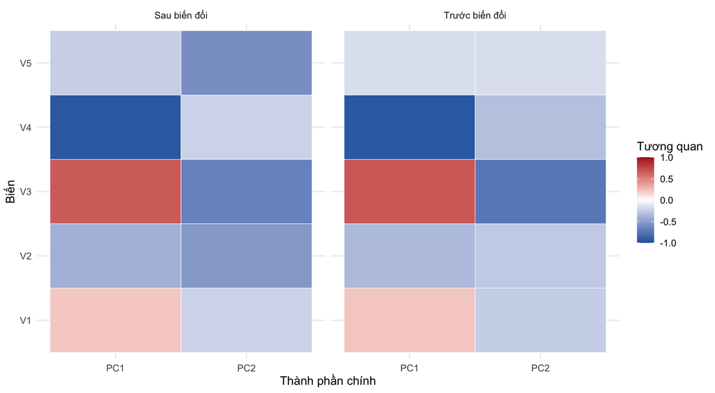

So sánh tương quan giữa các biến và PC1, PC2 trước và sau biến đổi

```r
# chuyển ma trận tương quan sang dữ liệu dạng dài
make_cor_data <- function(x, group) {
  d <- as.data.frame(
    as.table(x[, 1:2, drop = FALSE])
  )

  names(d) <- c("Variable", "PC", "Correlation")
  d$Group <- group

  d
}

# ghép dữ liệu trước và sau biến đổi
cor_plot_data <- rbind(
  make_cor_data(cor0, "Trước biến đổi"),
  make_cor_data(cor1, "Sau biến đổi")
)

# vẽ heatmap
ggplot2::ggplot(
  cor_plot_data,
  ggplot2::aes(
    x = PC,
    y = Variable,
    fill = Correlation
  )
) +
  ggplot2::geom_tile(color = "white") +
  ggplot2::facet_wrap(~Group, nrow = 1) +
  ggplot2::scale_fill_gradient2(
    low = "#2166AC",
    mid = "white",
    high = "#B2182B",
    midpoint = 0,
    limits = c(-1, 1)
  ) +
  ggplot2::labs(
    x = "Thành phần chính",
    y = "Biến",
    fill = "Tương quan"
  ) +
  ggplot2::theme_minimal(base_size = 12)
```

### Kiểm chứng công thức tương quan PC–biến

Để kiểm chứng kết quả, hệ số tương quan được tính trực tiếp từ dữ liệu và PC scores, sau đó đối chiếu với kết quả tính theo công thức trị riêng–vector riêng.

```r
# tính pc scores trước biến đổi
scores0 <- as.matrix(
  scale(cen, center = TRUE, scale = FALSE)
) %*% eig0$vectors

# kiểm chứng tương quan trước biến đổi
stopifnot(isTRUE(all.equal(
  unname(cor0),
  unname(cor(cen, scores0)),
  tolerance = 1e-8
)))

# kiểm chứng tương quan sau biến đổi
stopifnot(isTRUE(all.equal(
  unname(cor1),
  unname(cor(changed, scores1)),
  tolerance = 1e-8
)))
```

### Kết luận

Bên cạnh đó, cấu trúc tương quan giữa các biến và thành phần chính cũng có sự thay đổi. Trong khi PC1 vẫn có tương quan mạnh nhất với $V_4$ và $V_3$, tương quan giữa $V_5$ và PC2 tăng đáng kể về trị tuyệt đối, từ 0.16451 lên 0.58959. Điều này cho thấy $V_5$ có mối liên hệ mạnh hơn với PC2 sau biến đổi.

Như vậy, PCA dựa trên ma trận hiệp phương sai nhạy cảm với đơn vị đo của các biến. Do đó, khi phân tích dữ liệu có thang đo khác nhau, cần cân nhắc chuẩn hóa dữ liệu hoặc sử dụng ma trận tương quan để hạn chế ảnh hưởng của đơn vị đo đến kết quả PCA.

**Trực quan hóa so sánh**

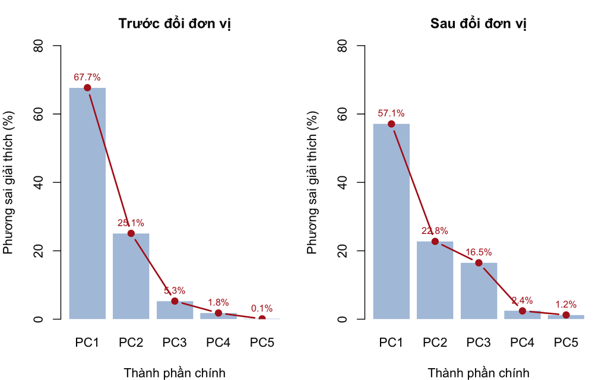

```r
# biểu đồ scree plot kết hợp cột và đường pve
plot_pca_scree <- function(pve, title) {
  pve_pct <- 100 * pve
  bp <- barplot(pve_pct, names.arg = paste0("PC", seq_along(pve)),
                col = "lightsteelblue", border = NA, ylim = c(0, 80),
                xlab = "Thành phần chính", ylab = "Phương sai giải thích (%)",
                main = title, cex.main = 1.1)

  lines(bp, pve_pct, type = "b", pch = 19, col = "firebrick", lwd = 2)
  text(bp, pve_pct, labels = sprintf("%.1f%%", pve_pct),
       pos = 3, cex = 0.75, col = "firebrick")
}

par(mfrow = c(1, 2), mar = c(4, 4, 3, 1))
plot_pca_scree(pve0, "Trước đổi đơn vị")
plot_pca_scree(pve1, "Sau đổi đơn vị")
```

```r
par(mfrow = c(1, 1))
```

**PCA dựa trên ma trận tương quan**

```r
# kiểm chứng tính bất biến của pca dựa trên ma trận tương quan
R1 <- cor(changed)
max_diff <- max(abs(R0 - R1))
stopifnot(isTRUE(all.equal(unname(R0), unname(R1), tolerance = 1e-10)))

eig_R0 <- eigen(R0, symmetric = TRUE)
eig_R1 <- eigen(R1, symmetric = TRUE)

# so sánh trị riêng trước và sau biến đổi
cor_pca_table <- data.frame(
  PC = paste0("PC", 1:5),
  Before = eig_R0$values,
  After = eig_R1$values,
  Difference = eig_R1$values - eig_R0$values
)

knitr::kable(cor_pca_table, format = "html", digits = 6, row.names = FALSE,
             col.names = c("Thành phần chính", "Trước biến đổi", "Sau biến đổi", "Chênh lệch"),
             align = c("c", "r", "r", "r"),
             caption = "So sánh trị riêng của PCA dựa trên ma trận tương quan") |>
  kableExtra::kable_styling(full_width = FALSE, position = "center", font_size = 13)
```

So sánh trị riêng của PCA dựa trên ma trận tương quan

| Thành phần chính | Trước biến đổi | Sau biến đổi | Chênh lệch |
| --- | --- | --- | --- |
| PC1 | 1.991918 | 1.991918 | 0 |
| PC2 | 1.367527 | 1.367527 | 0 |
| PC3 | 0.864157 | 0.864157 | 0 |
| PC4 | 0.535061 | 0.535061 | 0 |
| PC5 | 0.241337 | 0.241337 | 0 |

Để đánh giá ảnh hưởng của đơn vị đo, thực hiện thêm PCA dựa trên ma trận tương quan. Kết quả cho thấy ma trận tương quan trước và sau biến đổi gần như trùng khớp, với sai khác chỉ ở mức sai số tính toán số học. Các trị riêng tương ứng cũng không thay đổi.

Điều này cho thấy PCA dựa trên ma trận tương quan bất biến đối với phép thay đổi đơn vị đo bằng một hệ số dương. Ngược lại, PCA dựa trên ma trận hiệp phương sai chịu ảnh hưởng của thang đo, do đó việc lựa chọn ma trận phân tích cần phù hợp với đặc điểm dữ liệu và mục tiêu nghiên cứu.

**Phân tích độ nhạy theo hệ số đơn vị**

Để xem xét rõ hơn ảnh hưởng của việc thay đổi đơn vị đo đến kết quả PCA, ta mở rộng hệ số biến đổi của $V_5$ thành $c\in\{0.01,0.1,1,10,100\}$, thay vì chỉ xét $c=10$. Với mỗi giá trị $c$, ma trận hiệp phương sai được tính theo $S(c)=D(c)S_0D(c)$. Từ đó, ta tính tỷ lệ phương sai giải thích của thành phần chính thứ nhất ($\mathrm{PVE}_1$) và tỷ lệ phương sai giải thích tích lũy của hai thành phần chính đầu tiên ($\mathrm{CPVE}_2$) để đánh giá mức độ nhạy cảm của PCA đối với đơn vị đo.

```r
# phân tích độ nhạy theo hệ số thay đổi đơn vị đo của v5
scales <- c(0.01, 0.1, 1, 10, 100)

sensitivity <- do.call(rbind, lapply(scales, function(c) {
  Dc <- diag(c(1, 1, 1, 1, c))
  ev <- eigen(Dc %*% S0 %*% Dc, symmetric = TRUE)$values
  data.frame(scale_V5 = c, PC1_pct = 100 * ev[1] / sum(ev),
             PC2_pct = 100 * ev[2] / sum(ev),
             PC1_PC2_pct = 100 * sum(ev[1:2]) / sum(ev))
}))

# hiển thị bảng kết quả
knitr::kable(sensitivity, format = "html", digits = 3, row.names = FALSE,
             col.names = c("Hệ số c", "PC1 (%)", "PC2 (%)", "PC1 + PC2 (%)"),
             align = c("c", "r", "r", "r"),
             caption = "Độ nhạy của tỷ lệ phương sai giải thích theo hệ số thay đổi đơn vị đo") |>
  kableExtra::kable_styling(full_width = FALSE, position = "center", font_size = 13)
```

Độ nhạy của tỷ lệ phương sai giải thích theo hệ số thay đổi đơn vị đo

| Hệ số c | PC1 (%) | PC2 (%) | PC1 + PC2 (%) |
| --- | --- | --- | --- |
| 1e-02 | 67.828 | 25.141 | 92.969 |
| 1e-01 | 67.826 | 25.141 | 92.967 |
| 1e+00 | 67.697 | 25.096 | 92.793 |
| 1e+01 | 57.098 | 22.750 | 79.848 |
| 1e+02 | 95.508 | 3.113 | 98.620 |

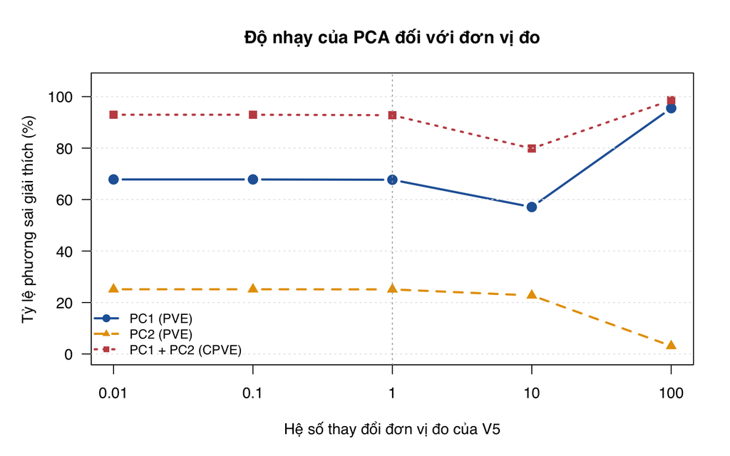

```r
# trực quan hóa độ nhạy của pca
x <- log10(sensitivity$scale_V5)
y <- as.matrix(sensitivity[, c("PC1_pct", "PC2_pct", "PC1_PC2_pct")])
cols <- c("#2563A6", "#E69F00", "#C44E52")

par(mar = c(5, 5, 4, 2), family = "sans")
matplot(x, y, type = "b", pch = c(19, 17, 15), lty = c(1, 2, 3),
        lwd = 2.3, cex = 1.2, col = cols, ylim = c(0, 105),
        xaxt = "n", yaxt = "n", xlab = "Hệ số thay đổi đơn vị đo của V5",
        ylab = "Tỷ lệ phương sai giải thích (%)",
        main = "Độ nhạy của PCA đối với đơn vị đo", cex.main = 1.15)

axis(1, at = x, labels = sensitivity$scale_V5)
axis(2, at = seq(0, 100, 20), las = 1)
abline(h = seq(0, 100, 20), col = "gray90", lty = 3)
abline(v = 0, col = "gray65", lty = 3)

legend("bottomleft", legend = c("PC1 (PVE)", "PC2 (PVE)", "PC1 + PC2 (CPVE)"),
       col = cols, pch = c(19, 17, 15), lty = c(1, 2, 3),
       lwd = 2.3, bty = "n", cex = 0.85)
```

Kết quả phân tích độ nhạy cho thấy khi hệ số biến đổi của $V_5$ không vượt quá 1, tỷ lệ phương sai giải thích của hai thành phần chính đầu tiên gần như không thay đổi, duy trì khoảng 92,8%. Tuy nhiên, khi hệ số tăng lên 10, tỷ lệ này giảm đáng kể xuống còn khoảng 79,8%. Ngược lại, tại $c=100$, tỷ lệ phương sai giải thích tích lũy tăng mạnh lên gần 99%, trong đó PC1 chiếm phần lớn phương sai, còn đóng góp của PC2 giảm rõ rệt.

Điều này cho thấy tỷ lệ phương sai giải thích không thay đổi đơn điệu theo hệ số biến đổi. Khi thang đo của $V_5$ quá lớn, PC1 có thể bị chi phối bởi phương sai của riêng biến này. Do đó, tỷ lệ phương sai giải thích cao chưa chắc phản ánh khả năng biểu diễn cân đối thông tin của các biến ban đầu.

# Bài 5.11 - PCA dữ liệu an ninh lương thực tại châu Phi

## Giới thiệu và đề bài

Bài 5.11 sử dụng dữ liệu khảo sát **76 hộ nông dân tại châu Phi**, gồm **9 biến** phản ánh quy mô hộ gia đình (`Family`), khoảng cách đến đường (`DistRd`), diện tích canh tác (`Cotton`, `Maize`, `Sorg`, `Millet`) và số lượng vật nuôi (`Bull`, `Cattle`, `Goats`). Bài yêu cầu:

1. Vẽ scatterplots giữa `Family` và `DistRd`, giữa `DistRd` và `Cattle`; xác định và loại bỏ các quan sát ngoại lai rõ ràng.
2. Thực hiện PCA trên **ma trận tương quan mẫu** $R$, xác định số thành phần chính cần giữ dựa trên tỷ lệ phương sai giải thích và Scree Plot.
3. Diễn giải **năm thành phần chính đầu tiên**, xem xét khả năng nhận diện các yếu tố đại diện cho quy mô nông trại, quy mô vật nuôi và khoảng cách đến đường.

## Dữ liệu và kiểm tra đầu vào

```r
path_511 <- here::here("data", "EX0_5_11.DAT")
vars_511 <- c("Family", "DistRd", "Cotton", "Maize", "Sorg", "Millet", "Bull", "Cattle", "Goats")
data_511 <- read.table(path_511, header = FALSE, col.names = vars_511)
stopifnot(ncol(data_511) == 9, nrow(data_511) == 76, all(vapply(data_511, is.numeric, logical(1))))
knitr::kable(head(data_511, 6), format = "html", digits = 2, row.names = FALSE, caption = "Sáu quan sát đầu tiên") |>
  kableExtra::kable_styling(full_width = FALSE, position = "center", font_size = 13)
```

Sáu quan sát đầu tiên

| Family | DistRd | Cotton | Maize | Sorg | Millet | Bull | Cattle | Goats |
| --- | --- | --- | --- | --- | --- | --- | --- | --- |
| 12 | 80 | 1.5 | 1.0 | 3 | 0.25 | 2 | 0 | 1 |
| 54 | 8 | 6.0 | 4.0 | 0 | 1.00 | 6 | 32 | 5 |
| 11 | 13 | 0.5 | 1.0 | 0 | 0.00 | 0 | 0 | 0 |
| 21 | 13 | 2.0 | 2.5 | 1 | 0.00 | 1 | 0 | 5 |
| 61 | 30 | 3.0 | 5.0 | 0 | 0.00 | 4 | 21 | 0 |
| 20 | 70 | 0.0 | 2.0 | 3 | 0.00 | 2 | 0 | 3 |

## Câu (a) Biểu đồ phân tán và đánh giá ngoại lai

### Mục tiêu phân tích

Câu (a) yêu cầu xây dựng hai biểu đồ phân tán giữa `Family` và `DistRd`, giữa `DistRd` và `Cattle`, từ đó xác định và loại bỏ những quan sát ngoại lai rõ ràng.

Trước khi thực hiện PCA, cần khảo sát đặc điểm phân phối và mức độ biến thiên của các biến. Việc phát hiện ngoại lai được thực hiện theo hai hướng: đánh giá trực quan bằng scatterplots và rà soát bổ sung bằng các thước đo thống kê.

**Nguyên tắc xử lý:** Một quan sát có giá trị lớn hoặc khác biệt so với phần lớn dữ liệu không nhất thiết là quan sát sai. Việc loại bỏ chỉ được thực hiện khi có cơ sở hợp lý từ biểu đồ và đặc điểm dữ liệu.

### Thống kê mô tả

```r
desc_511 <- data.frame(
  Variable = names(data_511),
  Mean = sapply(data_511, mean),
  SD = sapply(data_511, sd),
  Min = sapply(data_511, min),
  Median = sapply(data_511, median),
  Max = sapply(data_511, max),
  row.names = NULL
)
knitr::kable(
  desc_511,
  format = "html",
  digits = 3,
  row.names = FALSE,
  caption = "Thống kê mô tả dữ liệu gốc"
) |>
  kableExtra::kable_styling(
    full_width = FALSE,
    position = "center",
    font_size = 12
  )
```

Thống kê mô tả dữ liệu gốc

| Variable | Mean | SD | Min | Median | Max |
| --- | --- | --- | --- | --- | --- |
| Family | 32.368 | 23.471 | 5 | 25.50 | 145 |
| DistRd | 32.862 | 80.832 | 0 | 10.00 | 500 |
| Cotton | 2.991 | 2.831 | 0 | 2.00 | 12 |
| Maize | 2.082 | 1.853 | 0 | 1.50 | 8 |
| Sorg | 2.651 | 2.387 | 0 | 2.25 | 13 |
| Millet | 1.671 | 2.223 | 0 | 1.00 | 12 |
| Bull | 2.632 | 2.663 | 0 | 2.00 | 11 |
| Cattle | 4.658 | 13.156 | 0 | 0.00 | 104 |
| Goats | 2.974 | 4.125 | 0 | 2.00 | 20 |

**Nhận xét:** Thống kê mô tả cho thấy nhiều biến có sự chênh lệch đáng kể giữa giá trị trung bình và trung vị, đồng thời giá trị lớn nhất vượt xa mức trung vị. Điều này cho thấy phân phối của các biến có xu hướng lệch phải và có thể tồn tại những quan sát cực trị.

Đáng chú ý, `DistRd` có giá trị lớn nhất 500 km so với trung vị 10 km; `Cattle` có trung vị bằng 0 nhưng giá trị lớn nhất đạt 104 con; và `Family` có giá trị lớn nhất 145 người so với trung vị 25.5 người. Đây là ba biến cần được ưu tiên kiểm tra ngoại lai.

Tuy nhiên, các thống kê mô tả chưa đủ để kết luận một quan sát là ngoại lai, bởi giá trị lớn có thể phản ánh sự khác biệt thực tế giữa các hộ nông dân. Do đó, cần tiếp tục khảo sát phân phối, hai biểu đồ phân tán và kiểm tra chi tiết các quan sát nghi ngờ trước khi quyết định loại bỏ.

### Khảo sát phân phối của chín biến

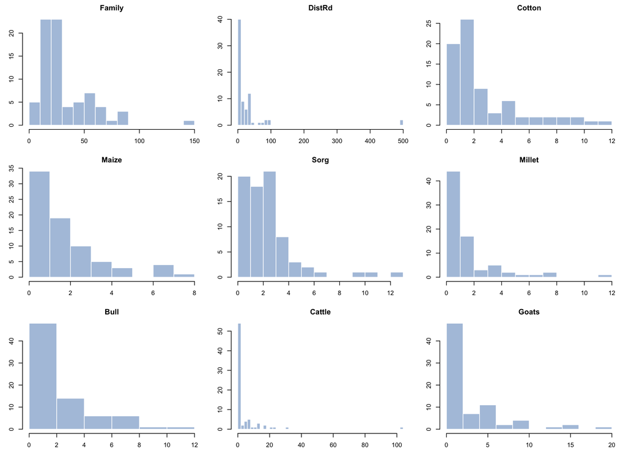

Phân phối biên của chín biến

```r
op <- par(mfrow = c(3, 3), mar = c(3, 3, 2, 1))
for (nm in names(data_511)) {
  hist(
    data_511[[nm]],
    breaks = "FD",
    main = nm,
    xlab = "",
    col = "lightsteelblue",
    border = "white"
  )
}
```

```r
par(op)
```

Từ histogram chart, có thể thấy là hầu hết các biến có phân phối lệch phải, với phần lớn quan sát tập trung ở những giá trị thấp và đuôi phân phối kéo dài về phía các giá trị lớn.

`Family`, `DistRd` và `Cattle` xuất hiện những giá trị cực trị nằm khá xa vùng tập trung chính của dữ liệu. Trong đó, `DistRd` và `Cattle` thể hiện mức độ lệch phải đặc biệt rõ rệt. Các biến diện tích canh tác và số lượng vật nuôi còn lại cũng có xu hướng lệch phải, nhưng mức độ khác nhau giữa các biến.

Kết quả này cũng được thể hiện qua bảng thống kê mô tả, khi hầu hết các biến có trung bình lớn hơn trung vị và giá trị lớn nhất chênh lệch đáng kể so với phần lớn quan sát. Tuy nhiên, các giá trị lớn chưa hẳn là ngoại lai, mà có thể phản ánh sự khác biệt về quy mô giữa các hộ nông dân. Do đó, cần xem xét thêm các biểu đồ phân tán và kiểm tra từng quan sát nghi ngờ trước khi quyết định loại bỏ khỏi dữ liệu.

### Biểu đồ phân tán

Khảo sát hai mối quan hệ:

- `Family` theo `DistRd`: quy mô hộ gia đình và khoảng cách đến đường.
- `DistRd` theo `Cattle`: khoảng cách đến đường và số lượng gia súc.

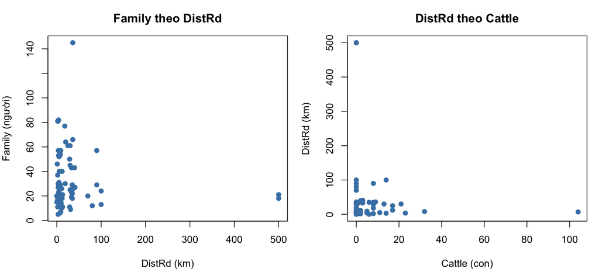

Hai biểu đồ phân tán theo yêu cầu bài 5.11

```r
op <- par(mfrow = c(1, 2), mar = c(4, 4, 3, 1))
plot(
  data_511$DistRd,
  data_511$Family,
  xlab = "DistRd (km)",
  ylab = "Family (người)",
  main = "Family theo DistRd",
  pch = 19,
  col = "steelblue"
)
plot(
  data_511$Cattle,
  data_511$DistRd,
  xlab = "Cattle (con)",
  ylab = "DistRd (km)",
  main = "DistRd theo Cattle",
  pch = 19,
  col = "steelblue"
)
```

```r
par(op)
```

Hai biểu đồ phân tán cho thấy phần lớn quan sát tập trung ở vùng có khoảng cách đến đường tương đối thấp, quy mô hộ gia đình và số lượng gia súc không quá lớn. Tuy nhiên, có một số điểm nằm tách biệt khỏi vùng tập trung chính, đáng chú ý là các quan sát có `DistRd` khoảng 500 km, `Family` đạt 145 người và `Cattle` đạt 104 con.

Ngoài ra, một số quan sát có quy mô gia đình hoặc khoảng cách đến đường tương đối lớn cũng cần được xem xét thêm. Các điểm này sẽ được đối chiếu với dữ liệu gốc để xác định số thứ tự quan sát và kiểm tra giá trị của các biến còn lại trước khi quyết định giữ hay loại.

**Áp dụng quy tắc IQR vào biểu đồ phần tán**

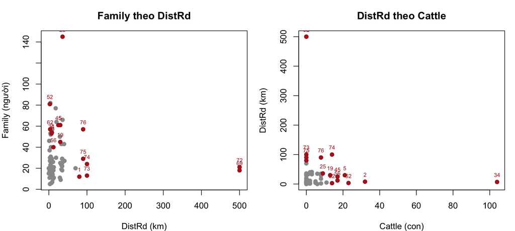

Các quan sát được đánh dấu để rà soát ngoại lai

```r
flag_iqr_511 <- sapply(data_511, function(x) {
  q <- quantile(x, c(0.25, 0.75))
  i <- diff(q)
  x < q[1] - 1.5 * i | x > q[2] + 1.5 * i
})
flag_pairs_511 <- which(
  flag_iqr_511[, "Family"] |
  flag_iqr_511[, "DistRd"] |
  flag_iqr_511[, "Cattle"]
)
op <- par(mfrow = c(1, 2), mar = c(4, 4, 3, 1))
plot(
  data_511$DistRd,
  data_511$Family,
  xlab = "DistRd (km)",
  ylab = "Family (người)",
  pch = 19,
  col = "gray60",
  main = "Family theo DistRd"
)
points(
  data_511$DistRd[flag_pairs_511],
  data_511$Family[flag_pairs_511],
  pch = 19,
  col = "firebrick"
)
text(
  data_511$DistRd[flag_pairs_511],
  data_511$Family[flag_pairs_511],
  labels = flag_pairs_511,
  pos = 3,
  cex = 0.65,
  col = "firebrick"
)
plot(
  data_511$Cattle,
  data_511$DistRd,
  xlab = "Cattle (con)",
  ylab = "DistRd (km)",
  pch = 19,
  col = "gray60",
  main = "DistRd theo Cattle"
)
points(
  data_511$Cattle[flag_pairs_511],
  data_511$DistRd[flag_pairs_511],
  pch = 19,
  col = "firebrick"
)
text(
  data_511$Cattle[flag_pairs_511],
  data_511$DistRd[flag_pairs_511],
  labels = flag_pairs_511,
  pos = 3,
  cex = 0.65,
  col = "firebrick"
)
```

```r
par(op)
```

```r
flag_table_511 <- data.frame(
  Row = flag_pairs_511,
  data_511[
    flag_pairs_511,
    c("Family", "DistRd", "Cattle"),
    drop = FALSE
  ],
  row.names = NULL
)
knitr::kable(
  flag_table_511,
  format = "html",
  digits = 2,
  row.names = FALSE,
  caption = "Các quan sát được đánh dấu theo quy tắc IQR"
) |>
  kableExtra::kable_styling(
    full_width = FALSE,
    position = "center",
    font_size = 12
  )
```

Các quan sát được đánh dấu theo quy tắc IQR

| Row | Family | DistRd | Cattle |
| --- | --- | --- | --- |
| 1 | 12 | 80.0 | 0 |
| 2 | 54 | 8.0 | 32 |
| 5 | 61 | 30.0 | 21 |
| 19 | 45 | 30.0 | 13 |
| 25 | 145 | 36.0 | 9 |
| 34 | 53 | 7.0 | 104 |
| 45 | 61 | 25.0 | 17 |
| 52 | 81 | 3.0 | 14 |
| 56 | 40 | 12.0 | 17 |
| 62 | 57 | 3.5 | 23 |
| 69 | 18 | 500.0 | 0 |
| 72 | 21 | 500.0 | 0 |
| 73 | 13 | 100.0 | 0 |
| 74 | 24 | 100.0 | 14 |
| 75 | 29 | 90.0 | 0 |
| 76 | 57 | 90.0 | 8 |

Theo quy tắc IQR, có 16 trên tổng số 76 quan sát được đánh dấu để kiểm tra ngoại lai. Trong đó, các quan sát số 25 (`Family = 145`), 34 (`Cattle = 104`) và 69, 72 (`DistRd = 500`) nằm tách biệt rõ so với phần lớn dữ liệu trên hai biểu đồ phân tán.

Các quan sát có `DistRd` từ 80 đến 100 hoặc có quy mô gia đình, số lượng gia súc tương đối lớn cũng vượt ngưỡng IQR, nhưng mức độ tách biệt không rõ rệt bằng bốn quan sát trên. Do đó, cần phân biệt giữa những điểm cực trị riêng lẻ và những nhóm quan sát có giá trị cao.

Trước khi xử lý, các quan sát nghi ngờ sẽ được kiểm tra trên toàn bộ chín biến để đánh giá tính hợp lý của dữ liệu. Quyết định giữ hoặc loại được đưa ra sau bước kiểm tra này, thay vì dựa hoàn toàn vào ngưỡng IQR.

### Kiểm tra bổ sung bằng khoảng cách Mahalanobis

Bên cạnh các phương pháp đơn biến và hai biến, khoảng cách Mahalanobis được sử dụng để phát hiện những tổ hợp giá trị bất thường trong không gian chín chiều.

Với quan sát $\mathbf{x}_i$, khoảng cách Mahalanobis bình phương được xác định bởi

$$D_i^2 =
(\mathbf{x}_i-\bar{\mathbf{x}})^\top
S^{-1}
(\mathbf{x}_i-\bar{\mathbf{x}}),$$

trong đó $\bar{\mathbf{x}}$ là vector trung bình mẫu và $S$ là ma trận hiệp phương sai mẫu.

Dưới giả định chuẩn đa biến và khi các tham số tổng thể đã biết, khoảng cách Mahalanobis bình phương có phân phối $\chi^2_p$. Trong bài này, ngưỡng $\chi^2_{9,0.975}$ chỉ được sử dụng như **mốc tham khảo chẩn đoán**, không phải kiểm định chính xác để quyết định loại ngoại lai.

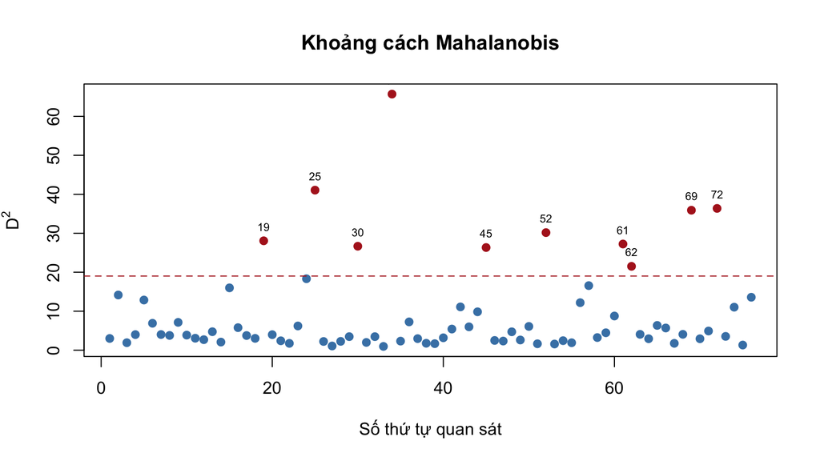

Khoảng cách Mahalanobis bình phương của các quan sát

```r
md2_511 <- mahalanobis(
  data_511,
  colMeans(data_511),
  cov(data_511)
)
cut_md_511 <- qchisq(0.975, df = ncol(data_511))
plot(
  seq_along(md2_511),
  md2_511,
  pch = 19,
  col = ifelse(
    md2_511 > cut_md_511,
    "firebrick",
    "steelblue"
  ),
  xlab = "Số thứ tự quan sát",
  ylab = expression(D^2),
  main = "Khoảng cách Mahalanobis"
)
abline(h = cut_md_511, col = "firebrick", lty = 2)
text(
  which(md2_511 > cut_md_511),
  md2_511[md2_511 > cut_md_511],
  labels = which(md2_511 > cut_md_511),
  pos = 3,
  cex = 0.65
)
```

```r
md_candidates_511 <- order(
  md2_511,
  decreasing = TRUE
)[seq_len(min(10, length(md2_511)))]
md_table_511 <- data.frame(
  Row = md_candidates_511,
  D2 = md2_511[md_candidates_511],
  Above_reference = md2_511[md_candidates_511] > cut_md_511,
  row.names = NULL
)
knitr::kable(
  md_table_511,
  format = "html",
  digits = 3,
  row.names = FALSE,
  caption = "Mười quan sát có khoảng cách Mahalanobis lớn nhất"
) |>
  kableExtra::kable_styling(
    full_width = FALSE,
    position = "center",
    font_size = 12
  )
```

Mười quan sát có khoảng cách Mahalanobis lớn nhất

| Row | D2 | Above_reference |
| --- | --- | --- |
| 34 | 65.713 | TRUE |
| 25 | 41.070 | TRUE |
| 72 | 36.380 | TRUE |
| 69 | 35.914 | TRUE |
| 52 | 30.173 | TRUE |
| 19 | 28.071 | TRUE |
| 61 | 27.244 | TRUE |
| 30 | 26.674 | TRUE |
| 45 | 26.345 | TRUE |
| 62 | 21.517 | TRUE |

**Nhận xét:** Kết quả cho thấy có 10 quan sát có khoảng cách Mahalanobis bình phương vượt ngưỡng tham khảo $\chi^2_{9,0.975}\approx19,02$. Trong đó, các quan sát 34, 25, 72 và 69 có giá trị $D^2$ lớn nhất, lần lượt là 65,713; 41,070; 36,380 và 35,914.

Bốn quan sát này cũng có giá trị cực trị trên các biểu đồ phân tán trước đó, tương ứng với `Cattle = 104`, `Family = 145` và `DistRd = 500`. Ngoài ra, Mahalanobis còn đánh dấu các quan sát 19, 30, 45, 52, 61 và 62. Đáng chú ý, quan sát 30 và 61 không bị đánh dấu bởi IQR trên ba biến `Family`, `DistRd` và `Cattle`, nhưng lại có khoảng cách Mahalanobis tương đối lớn.

Như vậy, kết quả Mahalanobis bổ sung thêm các trường hợp cần kiểm tra ngoài những điểm đã nhận diện bằng scatterplots và IQR. Các quan sát này sẽ được xem xét trên toàn bộ chín biến trước khi quyết định xử lý.

### Xử lý các quan sát ngoại lai

**Tổng hợp các quan sát cần xem xét**: Các quan sát được đánh giá là ngoại lai từ IQR và khoảng cách Mahalanobis được tổng hợp như sau:

```r
candidate_rows_511 <- sort(unique(c(
  flag_pairs_511,
  which(md2_511 > cut_md_511)
)))
outlier_summary_511 <- data.frame(
  Row = candidate_rows_511,
  Family = data_511$Family[candidate_rows_511],
  DistRd = data_511$DistRd[candidate_rows_511],
  Cattle = data_511$Cattle[candidate_rows_511],
  IQR_Flag = candidate_rows_511 %in% flag_pairs_511,
  Mahalanobis_Flag = md2_511[candidate_rows_511] > cut_md_511,
  D2 = md2_511[candidate_rows_511],
  row.names = NULL
)
knitr::kable(
  outlier_summary_511,
  format = "html",
  digits = 3,
  row.names = FALSE,
  caption = "Tổng hợp các quan sát cần xem xét trước khi xử lý"
) |>
  kableExtra::kable_styling(
    full_width = FALSE,
    position = "center",
    font_size = 12
  )
```

Tổng hợp các quan sát cần xem xét trước khi xử lý

| Row | Family | DistRd | Cattle | IQR_Flag | Mahalanobis_Flag | D2 |
| --- | --- | --- | --- | --- | --- | --- |
| 1 | 12 | 80.0 | 0 | TRUE | FALSE | 3.008 |
| 2 | 54 | 8.0 | 32 | TRUE | FALSE | 14.160 |
| 5 | 61 | 30.0 | 21 | TRUE | FALSE | 12.869 |
| 19 | 45 | 30.0 | 13 | TRUE | TRUE | 28.071 |
| 25 | 145 | 36.0 | 9 | TRUE | TRUE | 41.070 |
| 30 | 81 | 2.0 | 8 | FALSE | TRUE | 26.674 |
| 34 | 53 | 7.0 | 104 | TRUE | TRUE | 65.713 |
| 45 | 61 | 25.0 | 17 | TRUE | TRUE | 26.345 |
| 52 | 81 | 3.0 | 14 | TRUE | TRUE | 30.173 |
| 56 | 40 | 12.0 | 17 | TRUE | FALSE | 12.192 |
| 61 | 53 | 4.0 | 0 | FALSE | TRUE | 27.244 |
| 62 | 57 | 3.5 | 23 | TRUE | TRUE | 21.517 |
| 69 | 18 | 500.0 | 0 | TRUE | TRUE | 35.914 |
| 72 | 21 | 500.0 | 0 | TRUE | TRUE | 36.380 |
| 73 | 13 | 100.0 | 0 | TRUE | FALSE | 3.539 |
| 74 | 24 | 100.0 | 14 | TRUE | FALSE | 11.036 |
| 75 | 29 | 90.0 | 0 | TRUE | FALSE | 1.321 |
| 76 | 57 | 90.0 | 8 | TRUE | FALSE | 13.583 |

Bảng tổng hợp cho thấy có 18 quan sát được đánh dấu bởi ít nhất một trong hai phương pháp IQR và Mahalanobis. Tuy nhiên, mức độ bất thường giữa các quan sát không đồng nhất.

Trong đó, bốn quan sát 25, 34, 69 và 72 nổi bật hơn cả. Quan sát 25 có `Family = 145`, quan sát 34 có `Cattle = 104`, trong khi hai quan sát 69 và 72 cùng có `DistRd = 500`. Các giá trị này tách biệt rõ so với phần lớn dữ liệu và cả bốn quan sát đều được hai phương pháp đánh dấu.

Đối với những quan sát còn lại, mặc dù một số vượt ngưỡng IQR hoặc Mahalanobis, mức độ khác biệt trên các biến được khảo sát chưa đủ rõ để quyết định loại bỏ. Vì vậy, nghiên cứu lựa chọn loại bốn quan sát 25, 34, 69 và 72, đồng thời giữ lại các quan sát khác.

Sau bước xử lý, tập dữ liệu còn 72 quan sát và được sử dụng để thực hiện phân tích thành phần chính ở câu (b).

**Xử lý ngoại lai**

Sau khi rà soát các quan sát nghi ngờ, danh sách những dòng thực sự cần loại được xác định thủ công.

Trong trường hợp chưa đủ cơ sở để loại bỏ, dữ liệu gốc được giữ nguyên.

```r
# cập nhật danh sách dòng cần loại sau khi kiểm tra
exclude_rows_511 <- c(25, 34, 69, 72)

data_clean_511 <- data_511[
  !seq_len(nrow(data_511)) %in% exclude_rows_511,
  ,
  drop = FALSE
]

summary_outlier_511 <- data.frame(
  Chi_tieu = c(
    "Số quan sát ban đầu",
    "Số quan sát bị loại",
    "Số quan sát còn lại",
    "Tỷ lệ quan sát bị loại (%)"
  ),
  Gia_tri = c(
    nrow(data_511),
    length(exclude_rows_511),
    nrow(data_clean_511),
    round(100 * length(exclude_rows_511) / nrow(data_511), 2)
  )
)

knitr::kable(
  summary_outlier_511,
  format = "html",
  col.names = c("Chỉ tiêu", "Giá trị"),
  caption = "Kết quả xử lý các quan sát ngoại lai",
  row.names = FALSE
) |>
  kableExtra::kable_styling(
    full_width = FALSE,
    position = "center",
    font_size = 11
  )
```

Kết quả xử lý các quan sát ngoại lai

| Chỉ tiêu | Giá trị |
| --- | --- |
| Số quan sát ban đầu | 76.00 |
| Số quan sát bị loại | 4.00 |
| Số quan sát còn lại | 72.00 |
| Tỷ lệ quan sát bị loại (%) | 5.26 |

## Câu (b) PCA dựa trên ma trận tương quan

### Cấu trúc tương quan giữa các biến

Sau khi xử lý các quan sát ngoại lai, tiếp theo xem xét cấu trúc tương quan giữa chín biến. Phân tích này giúp nhận diện những nhóm biến có xu hướng biến thiên cùng nhau, đồng thời cung cấp cơ sở để thực hiện phân tích thành phần chính.

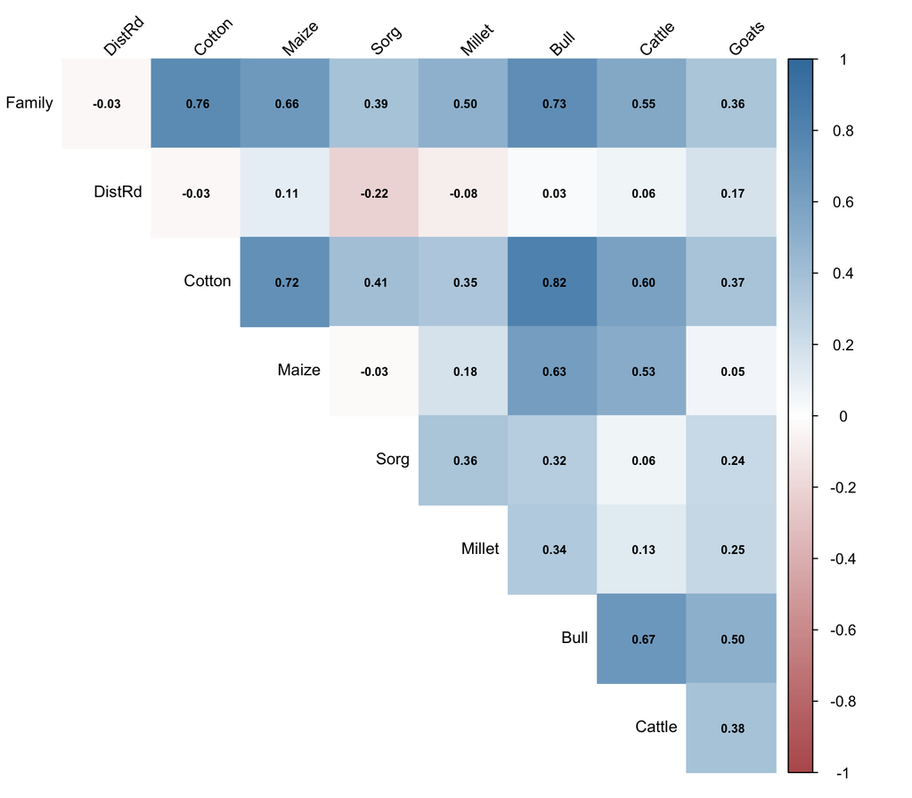

```r
R_511 <- cor(data_clean_511)

corrplot::corrplot(
  R_511,
  method = "color",
  type = "upper",
  order = "original",
  addCoef.col = "black",
  number.cex = 0.65,
  tl.col = "black",
  tl.cex = 0.85,
  tl.srt = 45,
  col = colorRampPalette(
    c("#B85C5C", "white", "#3F7EAD")
  )(200),
  diag = FALSE
)
```

Ma trận tương quan cho thấy phần lớn các biến liên quan đến quy mô gia đình, diện tích canh tác và số lượng vật nuôi có tương quan dương. Trong đó, `Cotton` và `Bull` có tương quan mạnh nhất ($r=0.82$), tiếp theo là `Family` và `Cotton` ($r=0.76$), `Family` và `Bull` ($r=0.73$), cùng với `Cotton` và `Maize` ($r=0.72$).

Kết quả này cho thấy các biến phản ánh hoạt động sản xuất nông nghiệp có xu hướng biến thiên cùng nhau liên quan đến quy mô sản xuất của hộ.

Ngược lại, `DistRd` có tương quan yếu với hầu hết các biến còn lại, với hệ số tương quan nằm gần 0. Điều này cho thấy khoảng cách đến đường có thể phản ánh một khía cạnh tương đối độc lập với quy mô sản xuất nông nghiệp.

### Lựa chọn ma trận tương quan thay cho ma trận hiệp phương sai

Các biến trong bộ dữ liệu có đơn vị đo và mức độ phân tán khác nhau. Chẳng hạn, `DistRd` biểu diễn khoảng cách, trong khi `Family` phản ánh quy mô gia đình và các biến còn lại liên quan đến diện tích canh tác hoặc số lượng vật nuôi.

Nếu PCA được thực hiện trực tiếp trên ma trận hiệp phương sai mẫu $S$, những biến có phương sai lớn có thể chi phối kết quả phân tích. Vì vậy, bài toán sử dụng ma trận tương quan mẫu $R$, tương đương với việc chuẩn hóa từng biến:

$$Z_{ij}=\frac{X_{ij}-\bar
X_j}{s_j}.$$

Khi đó,

$$R=\frac{1}{n-1}Z^\top Z.$$

Việc chuẩn hóa đưa các biến về cùng thang đo với trung bình bằng 0 và phương sai bằng 1 giúp PCA phản ánh cấu trúc tương quan giữa các biến thay vì chịu ảnh hưởng trực tiếp từ sự khác biệt về đơn vị đo. Tuy nhiên, phép chuẩn hóa không loại bỏ ảnh hưởng của các quan sát cực trị đến ma trận tương quan và kết quả PCA.

### Phân tích thành phần chính từ ma trận tương quan

Phân tích thành phần chính được thực hiện trên dữ liệu sau xử lý ngoại lai.

```r
pca_511 <- prcomp(
  data_clean_511,
  center = TRUE,
  scale. = TRUE
)

eigenvalues_511 <- pca_511$sdev^2
pve_511 <- eigenvalues_511 / sum(eigenvalues_511)
cpve_511 <- cumsum(pve_511)

pca_summary_511 <- data.frame(
  PC = paste0("PC", seq_along(eigenvalues_511)),
  Eigenvalue = eigenvalues_511,
  PVE = 100 * pve_511,
  CPVE = 100 * cpve_511
)

knitr::kable(
  pca_summary_511,
  format = "html",
  digits = 3,
  row.names = FALSE,
  caption = "Trị riêng và tỷ lệ phương sai giải thích của các thành phần chính (%)"
) |>
  kableExtra::kable_styling(
    full_width = FALSE,
    position = "center",
    font_size = 12
  )
```

Trị riêng và tỷ lệ phương sai giải thích của các thành phần chính (%)

| PC | Eigenvalue | PVE | CPVE |
| --- | --- | --- | --- |
| PC1 | 4.185 | 46.501 | 46.501 |
| PC2 | 1.438 | 15.979 | 62.480 |
| PC3 | 1.085 | 12.050 | 74.530 |
| PC4 | 0.792 | 8.798 | 83.328 |
| PC5 | 0.604 | 6.715 | 90.043 |
| PC6 | 0.366 | 4.068 | 94.111 |
| PC7 | 0.240 | 2.667 | 96.778 |
| PC8 | 0.172 | 1.909 | 98.687 |
| PC9 | 0.118 | 1.313 | 100.000 |

Với PCA trên ma trận tương quan của $p=9$ biến, tổng các trị riêng bằng 9:

$$\sum_{j=1}^{9}\lambda_j=9.$$

Tỷ lệ phương sai giải thích của thành phần chính thứ $j$ được xác định bởi:

$$\mathrm{PVE}_j
=\frac{\lambda_j}{\sum_{k=1}^{9}\lambda_k}
=\frac{\lambda_j}{9}.$$

Tỷ lệ phương sai giải thích tích lũy của $m$ thành phần đầu tiên là:

$$\mathrm{CPVE}_m=\sum_{j=1}^{m}\mathrm{PVE}_j.$$

**Scree plot**

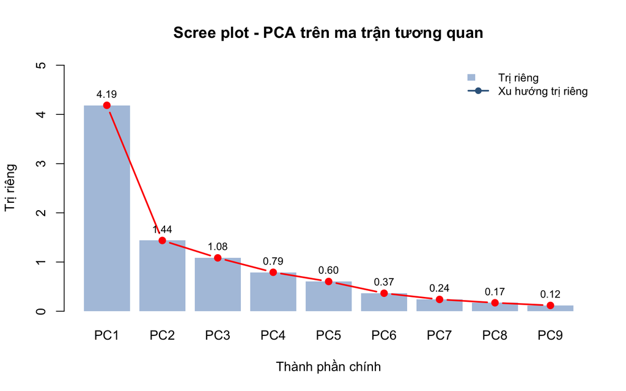

```r
bar_centers_511 <- barplot(eigenvalues_511, names.arg = paste0("PC", seq_along(eigenvalues_511)),
                           col = "lightsteelblue", border = NA, ylim = c(0, max(eigenvalues_511) * 1.2),
                           xlab = "Thành phần chính", ylab = "Trị riêng",
                           main = "Scree plot - PCA trên ma trận tương quan")

lines(bar_centers_511, eigenvalues_511, type = "b", pch = 19, lwd = 2, col = "red")
text(bar_centers_511, eigenvalues_511, labels = sprintf("%.2f", eigenvalues_511), pos = 3, cex = 0.8)

legend("topright", legend = c("Trị riêng", "Xu hướng trị riêng"),
       fill = c("lightsteelblue", NA), border = NA,
       col = c(NA, "steelblue4"), lty = c(NA, 1),
       lwd = c(NA, 2), pch = c(NA, 19), bty = "n", cex = 0.85)
```

Scree plot cho thấy trị riêng giảm mạnh từ PC1 đến PC2, sau đó giảm dần với tốc độ chậm hơn. Trong đó, PC1 có trị riêng lớn nhất ($\lambda_1=4.19$), cho thấy thành phần này giải thích phần lớn sự biến thiên của dữ liệu. Sau các thành phần chính đầu tiên, trị riêng giảm dần và đường Scree plot có xu hướng phẳng hơn. Kết hợp với tỷ lệ phương sai tích lũy khoảng 90% tại PC5, việc giữ lại năm thành phần chính đầu tiên là phù hợp để tiếp tục phân tích và diễn giải.

### Lựa chọn số thành phần chính

Số thành phần chính cần giữ lại được đánh giá dựa trên tỷ lệ phương sai giải thích tích lũy (CPVE) và biểu đồ Scree plot. Cụ thể, bài phân tích xác định số thành phần chính tối thiểu cần thiết để đạt các mức phương sai giải thích 70%, 80% và 90%.

```r
n_cpve70_511 <- which(cpve_511 >= 0.70)[1]
n_cpve80_511 <- which(cpve_511 >= 0.80)[1]
n_cpve90_511 <- which(cpve_511 >= 0.90)[1]

selection_basic_511 <- data.frame(
  Criterion = c("CPVE >= 70%", "CPVE >= 80%", "CPVE >= 90%"),
  Number_of_PCs = c(n_cpve70_511, n_cpve80_511, n_cpve90_511)
)

knitr::kable(selection_basic_511, format = "html", row.names = FALSE,
             caption = "Số thành phần chính theo tỷ lệ phương sai tích lũy") |>
  kableExtra::kable_styling(full_width = FALSE, position = "center", font_size = 12)
```

Số thành phần chính theo tỷ lệ phương sai tích lũy

| Criterion | Number_of_PCs |
| --- | --- |
| CPVE >= 70% | 3 |
| CPVE >= 80% | 4 |
| CPVE >= 90% | 5 |

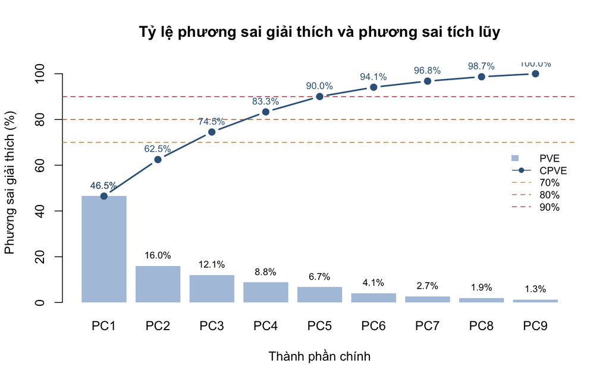

```r
pc_labels_511 <- paste0("PC", seq_along(pve_511))
pve_pct_511 <- 100 * pve_511
cpve_pct_511 <- 100 * cpve_511

bar_centers_511 <- barplot(pve_pct_511, names.arg = pc_labels_511,
                           col = "lightsteelblue", border = NA, ylim = c(0, 105),
                           xlab = "Thành phần chính", ylab = "Phương sai giải thích (%)",
                           main = "Tỷ lệ phương sai giải thích và phương sai tích lũy")

abline(h = c(70, 80, 90), col = c("#D4A24C", "#C77C59", "#B85C5C"), lty = 2, lwd = 1.2)
lines(bar_centers_511, cpve_pct_511, type = "b", pch = 19, lwd = 2, col = "steelblue4")

text(bar_centers_511, pve_pct_511, labels = sprintf("%.1f%%", pve_pct_511), pos = 3, cex = 0.75)
text(bar_centers_511, cpve_pct_511, labels = sprintf("%.1f%%", cpve_pct_511),
     pos = 3, cex = 0.75, col = "steelblue4", offset = 0.5)

legend("right", inset = c(0.01, 0.08),
       legend = c("PVE", "CPVE", "70%", "80%", "90%"),
       fill = c("lightsteelblue", NA, NA, NA, NA), border = NA,
       col = c(NA, "steelblue4", "#D4A24C", "#C77C59", "#B85C5C"),
       lty = c(NA, 1, 2, 2, 2), pch = c(NA, 19, NA, NA, NA),
       bty = "n", cex = 0.8)
```

### Độ nhạy của PCA đối với việc xử lý ngoại lai

Việc loại bỏ bốn quan sát 25, 34, 69 và 72 có thể làm thay đổi cấu trúc tương quan giữa các biến. Vì vậy, PCA được thực hiện trên cả dữ liệu ban đầu ($n=76$) và dữ liệu sau xử lý ngoại lai ($n=72$) để đánh giá mức độ ảnh hưởng của quyết định xử lý dữ liệu.

Trong cả hai trường hợp, PCA được thực hiện trên ma trận tương quan mẫu nhằm bảo đảm các biến được chuẩn hóa trước khi phân tích. Việc so sánh tập trung vào trị riêng, tỷ lệ phương sai giải thích và hướng của các vector riêng.

**So sánh trị riêng và phương sai giải thích**

```r
pca_raw_511 <- prcomp(data_511, center = TRUE, scale. = TRUE)
eigen_raw_511 <- pca_raw_511$sdev^2
pve_raw_511 <- eigen_raw_511 / sum(eigen_raw_511)
cpve_raw_511 <- cumsum(pve_raw_511)

sens_511 <- data.frame(
  PC = paste0("PC", seq_along(eigenvalues_511)),
  Eigen_Original = eigen_raw_511,
  Eigen_Clean = eigenvalues_511,
  PVE_Original = 100 * pve_raw_511,
  PVE_Clean = 100 * pve_511,
  Difference_pp = 100 * (pve_511 - pve_raw_511)
)

knitr::kable(sens_511, format = "html", digits = 3, row.names = FALSE,
             caption = "So sánh trị riêng và PVE trước và sau xử lý ngoại lai") |>
  kableExtra::kable_styling(full_width = FALSE, position = "center", font_size = 11)
```

So sánh trị riêng và PVE trước và sau xử lý ngoại lai

| PC | Eigen_Original | Eigen_Clean | PVE_Original | PVE_Clean | Difference_pp |
| --- | --- | --- | --- | --- | --- |
| PC1 | 4.144 | 4.185 | 46.048 | 46.501 | 0.454 |
| PC2 | 1.236 | 1.438 | 13.738 | 15.979 | 2.241 |
| PC3 | 1.058 | 1.085 | 11.757 | 12.050 | 0.293 |
| PC4 | 0.920 | 0.792 | 10.227 | 8.798 | -1.430 |
| PC5 | 0.606 | 0.604 | 6.731 | 6.715 | -0.016 |
| PC6 | 0.504 | 0.366 | 5.605 | 4.068 | -1.537 |
| PC7 | 0.272 | 0.240 | 3.023 | 2.667 | -0.356 |
| PC8 | 0.147 | 0.172 | 1.634 | 1.909 | 0.275 |
| PC9 | 0.111 | 0.118 | 1.238 | 1.313 | 0.075 |

```r
cpve_compare_511 <- data.frame(
  Dataset = c("Dữ liệu ban đầu (n = 76)", "Sau xử lý ngoại lai (n = 72)"),
  CPVE_3 = 100 * c(cpve_raw_511[3], cpve_511[3]),
  CPVE_5 = 100 * c(cpve_raw_511[5], cpve_511[5])
)

knitr::kable(cpve_compare_511, format = "html", digits = 3, row.names = FALSE,
             caption = "So sánh phương sai tích lũy của ba và năm thành phần chính đầu tiên") |>
  kableExtra::kable_styling(full_width = FALSE, position = "center", font_size = 12)
```

So sánh phương sai tích lũy của ba và năm thành phần chính đầu tiên

| Dataset | CPVE_3 | CPVE_5 |
| --- | --- | --- |
| Dữ liệu ban đầu (n = 76) | 71.542 | 88.501 |
| Sau xử lý ngoại lai (n = 72) | 74.530 | 90.043 |

Kết quả cho thấy tỷ lệ phương sai giải thích của PC1 tăng nhẹ từ 46,05% lên 46,50% sau khi xử lý ngoại lai. Trong khi đó, PC2 có mức tăng lớn nhất, từ 13,738% lên 15,979%, tương ứng 2,241 điểm phần trăm. Ngược lại, PVE của PC4 và PC6 giảm lần lượt 1,430 và 1,537 điểm phần trăm.

Xét năm thành phần chính đầu tiên, tỷ lệ phương sai giải thích tích lũy tăng từ khoảng 88,50% lên 90,04%. Như vậy, việc loại bỏ bốn quan sát cực trị không làm thay đổi đáng kể khả năng giải thích tổng phương sai của năm thành phần chính đầu tiên. Tuy nhiên, sự ổn định về tỷ lệ phương sai giải thích không đồng nghĩa với sự ổn định về hướng của các thành phần chính, do đó cần tiếp tục xem xét mức độ tương đồng giữa các vector riêng trước và sau xử lý ngoại lai.

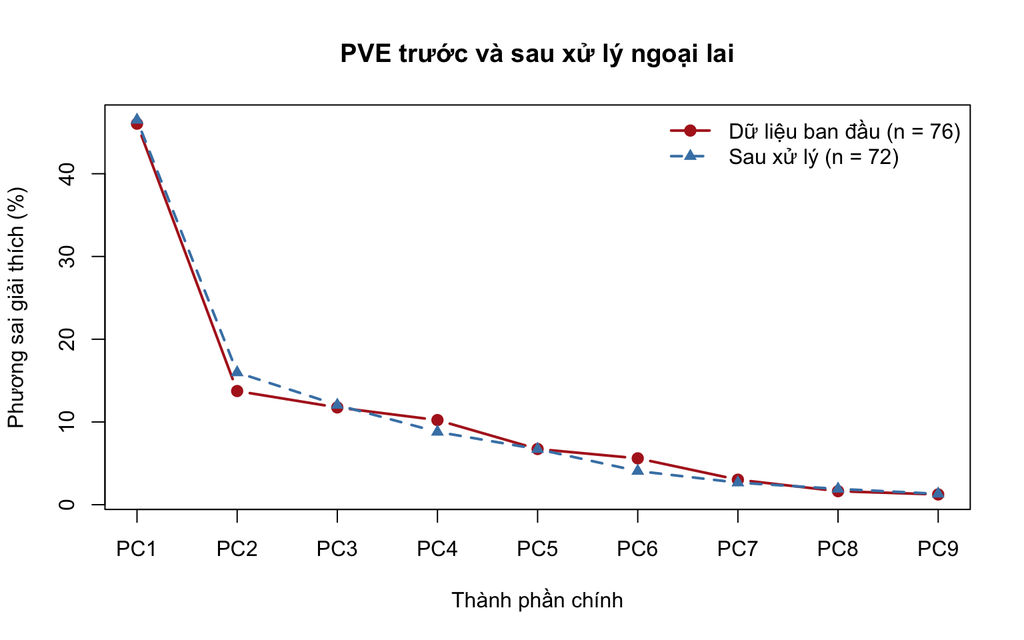

```r
matplot(seq_along(eigenvalues_511), cbind(100 * pve_raw_511, 100 * pve_511),
        type = "b", pch = c(19, 17), lty = c(1, 2), lwd = 2,
        col = c("firebrick", "steelblue"), xaxt = "n",
        xlab = "Thành phần chính", ylab = "Phương sai giải thích (%)",
        main = "PVE trước và sau xử lý ngoại lai")

axis(1, at = seq_along(eigenvalues_511),
     labels = paste0("PC", seq_along(eigenvalues_511)))

legend("topright", legend = c("Dữ liệu ban đầu (n = 76)", "Sau xử lý (n = 72)"),
       col = c("firebrick", "steelblue"), pch = c(19, 17),
       lty = c(1, 2), lwd = 2, bty = "n")
```

**So sánh hướng của các thành phần chính**

Ngoài tỷ lệ phương sai giải thích, hướng của các vector riêng cũng được so sánh để đánh giá mức độ ổn định của PCA.

Với hai vector riêng đơn vị $\mathbf{a}$ và $\mathbf{b}$, mức độ tương đồng về hướng được xác định bằng:

$$s(\mathbf{a},\mathbf{b})=\left|\mathbf{a}^{\top}\mathbf{b}\right|.$$

Giá trị gần 1 cho thấy hai vector có hướng gần trùng nhau, trong khi giá trị gần 0 cho thấy chúng gần trực giao. Việc lấy trị tuyệt đối giúp loại bỏ sự khác biệt về dấu của vector riêng, vì đổi dấu vector riêng không làm thay đổi thành phần chính về mặt phương sai giải thích.

```r
direction_similarity_511 <- sapply(seq_along(eigenvalues_511), function(j) {
  abs(sum(pca_raw_511$rotation[, j] * pca_511$rotation[, j]))
})

direction_table_511 <- data.frame(
  PC = paste0("PC", seq_along(eigenvalues_511)),
  Absolute_Dot_Product = direction_similarity_511
)

knitr::kable(direction_table_511, format = "html", digits = 4, row.names = FALSE,
             caption = "Mức độ tương đồng về hướng của các thành phần chính trước và sau xử lý") |>
  kableExtra::kable_styling(full_width = FALSE, position = "center", font_size = 12)
```

Mức độ tương đồng về hướng của các thành phần chính trước và sau xử lý

| PC | Absolute_Dot_Product |
| --- | --- |
| PC1 | 0.9849 |
| PC2 | 0.4087 |
| PC3 | 0.7010 |
| PC4 | 0.3391 |
| PC5 | 0.3007 |
| PC6 | 0.2533 |
| PC7 | 0.8867 |
| PC8 | 0.9700 |
| PC9 | 0.9037 |

Kết quả cho thấy PC1 có độ tương đồng rất cao (0,9849), cho thấy hướng của thành phần này gần như được bảo toàn sau khi loại bỏ ngoại lai. PC3 có độ tương đồng 0,7010, trong khi PC2, PC4 và PC5 có giá trị lần lượt là 0,4087; 0,3391 và 0,3007, phản ánh sự thay đổi đáng kể về hướng của các vector riêng tương ứng.

**Kết luận về độ nhạy**

Kết quả cho thấy việc xử lý ngoại lai không làm thay đổi đáng kể tỷ lệ phương sai giải thích của các thành phần chính đầu tiên. Tuy nhiên, mức độ tương đồng về hướng của một số vector riêng tương đối thấp, cho thấy cấu trúc các thành phần có thể nhạy với việc loại bỏ quan sát cực trị. Vì vậy, kết quả PCA trên dữ liệu sau xử lý được sử dụng cho các bước phân tích tiếp theo.

### Tổng hợp ảnh hưởng của xử lý ngoại lai

```r
sensitivity_summary_511 <- data.frame(
  Indicator = c(
    "Số quan sát ban đầu",
    "Số quan sát sau xử lý",
    "Số quan sát loại bỏ",
    "PVE của PC1 trước xử lý (%)",
    "PVE của PC1 sau xử lý (%)",
    "CPVE của PC1-PC2 trước xử lý (%)",
    "CPVE của PC1-PC2 sau xử lý (%)",
    "Độ tương đồng hướng PC1",
    "Độ tương đồng hướng PC2"
  ),
  Value = c(
    nrow(data_511),
    nrow(data_clean_511),
    nrow(data_511) - nrow(data_clean_511),
    100 * pve_raw_511[1],
    100 * pve_511[1],
    100 * sum(pve_raw_511[1:2]),
    100 * sum(pve_511[1:2]),
    direction_similarity_511[1],
    direction_similarity_511[2]
  )
)

knitr::kable(
  sensitivity_summary_511,
  format = "html",
  digits = 4,
  row.names = FALSE,
  caption = "Tổng hợp ảnh hưởng của việc xử lý ngoại lai đến PCA"
) |>
  kableExtra::kable_styling(
    full_width = FALSE,
    position = "center",
    font_size = 12
  )
```

Tổng hợp ảnh hưởng của việc xử lý ngoại lai đến PCA

| Indicator | Value |
| --- | --- |
| Số quan sát ban đầu | 76.0000 |
| Số quan sát sau xử lý | 72.0000 |
| Số quan sát loại bỏ | 4.0000 |
| PVE của PC1 trước xử lý (%) | 46.0476 |
| PVE của PC1 sau xử lý (%) | 46.5015 |
| CPVE của PC1-PC2 trước xử lý (%) | 59.7851 |
| CPVE của PC1-PC2 sau xử lý (%) | 62.4802 |
| Độ tương đồng hướng PC1 | 0.9849 |
| Độ tương đồng hướng PC2 | 0.4087 |

Kết quả phân tích độ nhạy sẽ được sử dụng để đánh giá mức độ thay đổi của các thành phần chính khi loại bỏ những quan sát cực trị. Việc so sánh này giúp làm rõ ảnh hưởng của bước tiền xử lý, thay vì mặc nhiên cho rằng loại ngoại lai luôn cải thiện kết quả PCA.

## (c) Diễn giải năm thành phần chính đầu tiên

Năm thành phần chính đầu tiên được phân tích thông qua hệ số vector riêng, tương quan với các biến ban đầu, mức đóng góp của từng biến và chất lượng biểu diễn. Mục tiêu là xác định liệu các thành phần chính có phản ánh được những đặc điểm liên quan đến quy mô nông hộ, diện tích canh tác, số lượng vật nuôi và khoảng cách đến đường giao thông hay không.

Việc diễn giải được thực hiện trên bộ dữ liệu sau xử lý ngoại lai gồm 72 quan sát, sử dụng kết quả PCA trên ma trận tương quan mẫu ở câu (b).

### Eigenvectors, correlation loadings, contribution và cos²

#### Hệ số vector riêng và công thức các thành phần chính

Với các biến đã chuẩn hóa, thành phần chính thứ $j$ được biểu diễn dưới dạng:

$$PC_j=\sum_{i=1}^{9}e_{ij}Z_i,\qquad
j=1,\ldots,5,$$

trong đó $e_{ij}$ là hệ số thứ $i$ của vector riêng tương ứng với thành phần chính thứ $j$, còn $Z_i$ là biến gốc đã chuẩn hóa.

```r
eigenvectors_511 <- pca_511$rotation[, 1:5, drop = FALSE]

knitr::kable(eigenvectors_511, format = "html", digits = 4,
             caption = "Hệ số vector riêng của PC1–PC5") |>
  kableExtra::kable_styling(full_width = FALSE, position = "center", font_size = 12)
```

Hệ số vector riêng của PC1–PC5

|  | PC1 | PC2 | PC3 | PC4 | PC5 |
| --- | --- | --- | --- | --- | --- |
| Family | 0.4338 | 0.0651 | -0.0984 | 0.1712 | -0.0113 |
| DistRd | 0.0076 | -0.4967 | 0.5686 | 0.4956 | 0.3777 |
| Cotton | 0.4461 | -0.0089 | -0.1321 | -0.0273 | 0.2187 |
| Maize | 0.3522 | -0.3526 | -0.3882 | 0.2402 | 0.0792 |
| Sorg | 0.2036 | 0.6037 | 0.1115 | -0.0585 | 0.6446 |
| Millet | 0.2404 | 0.4152 | 0.1160 | 0.6163 | -0.5270 |
| Bull | 0.4453 | -0.0680 | 0.0304 | -0.1456 | 0.0283 |
| Cattle | 0.3554 | -0.2845 | -0.0138 | -0.3729 | -0.2175 |
| Goats | 0.2545 | 0.0487 | 0.6870 | -0.3508 | -0.2487 |

Để thể hiện rõ cách hình thành từng thành phần chính, các hệ số được sử dụng để xây dựng công thức tổ hợp tuyến tính của PC1–PC5.

$$\begin{aligned}
PC_1 ={}&
0.434Z_{\mathrm{Family}}
+0.008Z_{\mathrm{DistRd}}
+0.446Z_{\mathrm{Cotton}}\\
&+0.352Z_{\mathrm{Maize}}
+0.204Z_{\mathrm{Sorg}}
+0.240Z_{\mathrm{Millet}}\\
&+0.445Z_{\mathrm{Bull}}
+0.355Z_{\mathrm{Cattle}}
+0.255Z_{\mathrm{Goats}}
\end{aligned}$$

$$\begin{aligned}
PC_2 ={}&
0.065Z_{\mathrm{Family}}
-0.497Z_{\mathrm{DistRd}}
-0.009Z_{\mathrm{Cotton}}\\
&-0.353Z_{\mathrm{Maize}}
+0.604Z_{\mathrm{Sorg}}
+0.415Z_{\mathrm{Millet}}\\
&-0.068Z_{\mathrm{Bull}}
-0.284Z_{\mathrm{Cattle}}
+0.049Z_{\mathrm{Goats}}
\end{aligned}$$

$$\begin{aligned}
PC_3 ={}&
-0.098Z_{\mathrm{Family}}
+0.569Z_{\mathrm{DistRd}}
-0.132Z_{\mathrm{Cotton}}\\
&-0.388Z_{\mathrm{Maize}}
+0.111Z_{\mathrm{Sorg}}
+0.116Z_{\mathrm{Millet}}\\
&+0.030Z_{\mathrm{Bull}}
-0.014Z_{\mathrm{Cattle}}
+0.687Z_{\mathrm{Goats}}
\end{aligned}$$

$$\begin{aligned}
PC_4 ={}&
0.171Z_{\mathrm{Family}}
+0.496Z_{\mathrm{DistRd}}
-0.027Z_{\mathrm{Cotton}}\\
&+0.240Z_{\mathrm{Maize}}
-0.059Z_{\mathrm{Sorg}}
+0.616Z_{\mathrm{Millet}}\\
&-0.146Z_{\mathrm{Bull}}
-0.373Z_{\mathrm{Cattle}}
-0.351Z_{\mathrm{Goats}}
\end{aligned}$$

$$\begin{aligned}
PC_5 ={}&
-0.011Z_{\mathrm{Family}}
+0.378Z_{\mathrm{DistRd}}
+0.219Z_{\mathrm{Cotton}}\\
&+0.079Z_{\mathrm{Maize}}
+0.645Z_{\mathrm{Sorg}}
-0.527Z_{\mathrm{Millet}}\\
&+0.028Z_{\mathrm{Bull}}
-0.218Z_{\mathrm{Cattle}}
-0.249Z_{\mathrm{Goats}}
\end{aligned}$$

Kết quả cho thấy **PC1** có các hệ số dương tương đối lớn ở Cotton (0,4461), Bull (0,4453) và Family (0,4338), gợi ý một hướng biến thiên chung liên quan đến quy mô hoạt động nông nghiệp. Trong khi đó, **PC2–PC5** có sự kết hợp giữa các hệ số dương và âm, phản ánh những hướng tương phản giữa các đặc điểm canh tác, chăn nuôi và khoảng cách đến đường giao thông.

Đáng chú ý, DistRd có hệ số gần bằng 0 ở PC1 nhưng nổi bật hơn ở các thành phần tiếp theo. Những kết quả này bước đầu cho thấy mỗi thành phần chính phản ánh một cấu trúc biến thiên khác nhau. Ý nghĩa cụ thể của từng thành phần sẽ được phân tích sâu hơn thông qua correlation loadings, contribution và cos² ở các mục tiếp theo.

#### Tương quan giữa biến gốc và thành phần chính

Để đánh giá mối liên hệ giữa từng biến ban đầu và các thành phần chính, hệ số tương quan được tính theo:

$$\operatorname{corr}(Z_i,PC_j)=\sqrt{\lambda_j}\,e_{ij}.$$

Trong đó $\lambda_j$ là trị riêng tương ứng với thành phần chính thứ $j$.

```r
cor_loadings_511 <- sweep(eigenvectors_511, 2, pca_511$sdev[1:5], `*`)

knitr::kable(cor_loadings_511, format = "html", digits = 4,
             caption = "Tương quan giữa các biến ban đầu và PC1–PC5") |>
  kableExtra::kable_styling(full_width = FALSE, position = "center", font_size = 12)
```

Tương quan giữa các biến ban đầu và PC1–PC5

|  | PC1 | PC2 | PC3 | PC4 | PC5 |
| --- | --- | --- | --- | --- | --- |
| Family | 0.8875 | 0.0781 | -0.1025 | 0.1523 | -0.0088 |
| DistRd | 0.0155 | -0.5956 | 0.5921 | 0.4410 | 0.2936 |
| Cotton | 0.9127 | -0.0107 | -0.1376 | -0.0243 | 0.1700 |
| Maize | 0.7206 | -0.4228 | -0.4043 | 0.2137 | 0.0616 |
| Sorg | 0.4166 | 0.7239 | 0.1161 | -0.0521 | 0.5011 |
| Millet | 0.4917 | 0.4979 | 0.1208 | 0.5484 | -0.4097 |
| Bull | 0.9109 | -0.0816 | 0.0316 | -0.1296 | 0.0220 |
| Cattle | 0.7271 | -0.3411 | -0.0144 | -0.3319 | -0.1691 |
| Goats | 0.5207 | 0.0584 | 0.7154 | -0.3121 | -0.1933 |

PC1 có tương quan dương mạnh với Cotton (0,9127), Bull (0,9109), Family (0,8875), Cattle (0,7271) và Maize (0,7206), cho thấy thành phần này phản ánh **xu hướng biến thiên đồng thời của quy mô canh tác, chăn nuôi và gia đình**. Ngược lại, DistRd gần như không tương quan với PC1 (0,0155), cho thấy khoảng cách đến đường không đóng vai trò đáng kể trong hướng biến thiên chính của dữ liệu.

Đối với các thành phần còn lại, PC2 thể hiện sự tương phản giữa Sorg, Millet với DistRd và Maize; PC3 nổi bật với Goats và DistRd; PC4 phản ánh sự đối lập giữa Millet, DistRd với Cattle, Goats; trong khi PC5 chủ yếu thể hiện sự tương phản giữa Sorg và Millet. Như vậy, **PC1 đại diện tương đối rõ cho quy mô hoạt động nông nghiệp tổng hợp, còn PC2–PC5 phản ánh những khác biệt về cơ cấu sản xuất và đặc điểm giao thông**, thay vì các thước đo quy mô đơn thuần.

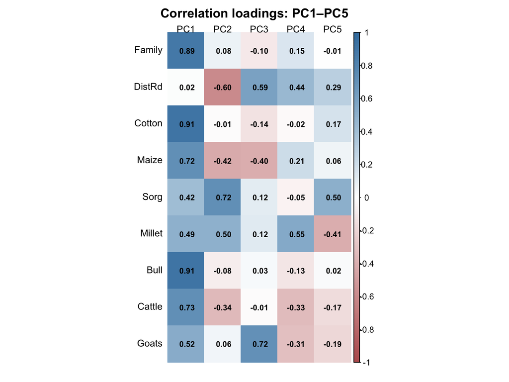

```r
corrplot::corrplot(cor_loadings_511, is.corr = FALSE, method = "color",
                   col = colorRampPalette(c("#B85C5C", "white", "#3F7EAD"))(200),
                   col.lim = c(-1, 1), addCoef.col = "black", number.cex = 0.75,
                   tl.col = "black", tl.cex = 0.9, tl.srt = 0,
                   cl.pos = "r", mar = c(1, 1, 2, 1),
                   title = "Correlation loadings: PC1–PC5")
```

#### Đóng góp của từng biến vào thành phần chính (contribution)

Đóng góp của biến thứ $i$ vào thành phần chính thứ $j$ được xác định bởi:

$$\operatorname{Contribution}_{ij}=100e_{ij}^{2}.$$

Tổng contribution của tất cả các biến trong mỗi thành phần chính bằng 100%.

```r
contrib_511 <- 100 * eigenvectors_511^2

knitr::kable(contrib_511, format = "html", digits = 2,
             caption = "Contribution (%) của từng biến vào PC1–PC5") |>
  kableExtra::kable_styling(full_width = FALSE, position = "center", font_size = 12)
```

Contribution (%) của từng biến vào PC1–PC5

|  | PC1 | PC2 | PC3 | PC4 | PC5 |
| --- | --- | --- | --- | --- | --- |
| Family | 18.82 | 0.42 | 0.97 | 2.93 | 0.01 |
| DistRd | 0.01 | 24.67 | 32.33 | 24.56 | 14.26 |
| Cotton | 19.90 | 0.01 | 1.75 | 0.07 | 4.78 |
| Maize | 12.41 | 12.43 | 15.07 | 5.77 | 0.63 |
| Sorg | 4.15 | 36.44 | 1.24 | 0.34 | 41.55 |
| Millet | 5.78 | 17.24 | 1.34 | 37.99 | 27.77 |
| Bull | 19.83 | 0.46 | 0.09 | 2.12 | 0.08 |
| Cattle | 12.63 | 8.09 | 0.02 | 13.91 | 4.73 |
| Goats | 6.48 | 0.24 | 47.19 | 12.31 | 6.18 |

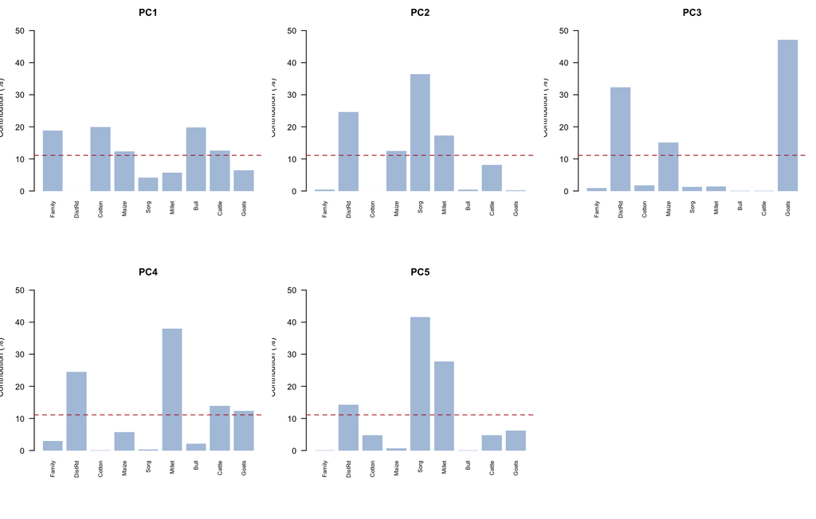

```r
op_511 <- par(mfrow = c(2, 3), mar = c(7, 3.5, 2.5, 1))

for (j in seq_len(5)) {
  barplot(contrib_511[, j], names.arg = rownames(contrib_511),
          las = 2, cex.names = 0.7, col = "lightsteelblue",
          border = NA, ylab = "Contribution (%)",
          main = paste0("PC", j),
          ylim = c(0, max(contrib_511) * 1.1))
  abline(h = 100 / nrow(contrib_511), lty = 2, col = "firebrick")
}

par(op_511)
```

#### Chất lượng biểu diễn của từng biến (cos²)

Chất lượng biểu diễn của biến $i$ trên thành phần chính $j$ được xác định bằng:

$$\cos^2_{ij}=\operatorname{corr}(Z_i,PC_j)^2
=\lambda_j e_{ij}^{2}.$$

Tổng cos² qua năm thành phần đầu cho biết tỷ lệ phương sai của mỗi biến chuẩn hóa được biểu diễn bởi không gian PC1–PC5:

$$Q_i=\sum_{j=1}^{5}\cos^2_{ij}.$$

```r
cos2_511 <- cor_loadings_511^2

cos2_table_511 <- data.frame(
  Variable = rownames(cos2_511),
  cos2_511,
  Total_PC1_PC5 = rowSums(cos2_511),
  row.names = NULL
)

knitr::kable(cos2_table_511, format = "html", digits = 3, row.names = FALSE,
             caption = "Cos² và chất lượng biểu diễn của từng biến trên PC1–PC5") |>
  kableExtra::kable_styling(full_width = FALSE, position = "center", font_size = 12)
```

Cos² và chất lượng biểu diễn của từng biến trên PC1–PC5

| Variable | PC1 | PC2 | PC3 | PC4 | PC5 | Total_PC1_PC5 |
| --- | --- | --- | --- | --- | --- | --- |
| Family | 0.788 | 0.006 | 0.011 | 0.023 | 0.000 | 0.828 |
| DistRd | 0.000 | 0.355 | 0.351 | 0.194 | 0.086 | 0.986 |
| Cotton | 0.833 | 0.000 | 0.019 | 0.001 | 0.029 | 0.882 |
| Maize | 0.519 | 0.179 | 0.163 | 0.046 | 0.004 | 0.911 |
| Sorg | 0.174 | 0.524 | 0.013 | 0.003 | 0.251 | 0.965 |
| Millet | 0.242 | 0.248 | 0.015 | 0.301 | 0.168 | 0.973 |
| Bull | 0.830 | 0.007 | 0.001 | 0.017 | 0.000 | 0.855 |
| Cattle | 0.529 | 0.116 | 0.000 | 0.110 | 0.029 | 0.784 |
| Goats | 0.271 | 0.003 | 0.512 | 0.097 | 0.037 | 0.921 |

Kết quả cos² cho thấy PC1 biểu diễn tốt các biến Cotton (83,3%), Bull (83,0%) và Family (78,8%), củng cố nhận định rằng thành phần này phản ánh hướng biến thiên chung về quy mô hoạt động nông nghiệp. Trong khi đó, DistRd gần như không được biểu diễn bởi PC1 nhưng có phương sai phân bổ chủ yếu trên PC2–PC5, cho thấy đặc điểm khoảng cách giao thông được phản ánh bởi những hướng biến thiên khác.

Xét tổng thể, năm thành phần chính đầu tiên biểu diễn được từ 78,4% đến 98,6% phương sai của từng biến. DistRd, Millet và Sorg có chất lượng biểu diễn cao nhất, trong khi Cattle thấp nhất. Như vậy, việc giữ lại năm PC không chỉ bảo toàn khoảng 90% tổng phương sai của dữ liệu mà còn duy trì chất lượng biểu diễn tương đối tốt đối với cả chín biến ban đầu.

### Bản đồ tương quan trên hai thành phần đầu tiên

Để trực quan hóa mối quan hệ giữa các biến ban đầu, sử dụng vòng tròn tương quan trên mặt phẳng PC1–PC2. Hai thành phần này được lựa chọn vì giải thích tổng cộng 62,48% phương sai, là tỷ lệ lớn nhất trong các mặt phẳng tạo bởi hai thành phần chính. Do đó, mặt phẳng PC1–PC2 cung cấp cái nhìn tổng quát về cấu trúc tương quan chủ yếu của dữ liệu. Tuy nhiên, biểu đồ chỉ phản ánh thông tin trên hai thành phần đầu tiên; vai trò của PC3–PC5 tiếp tục được xem xét thông qua correlation loadings, contribution và cos².

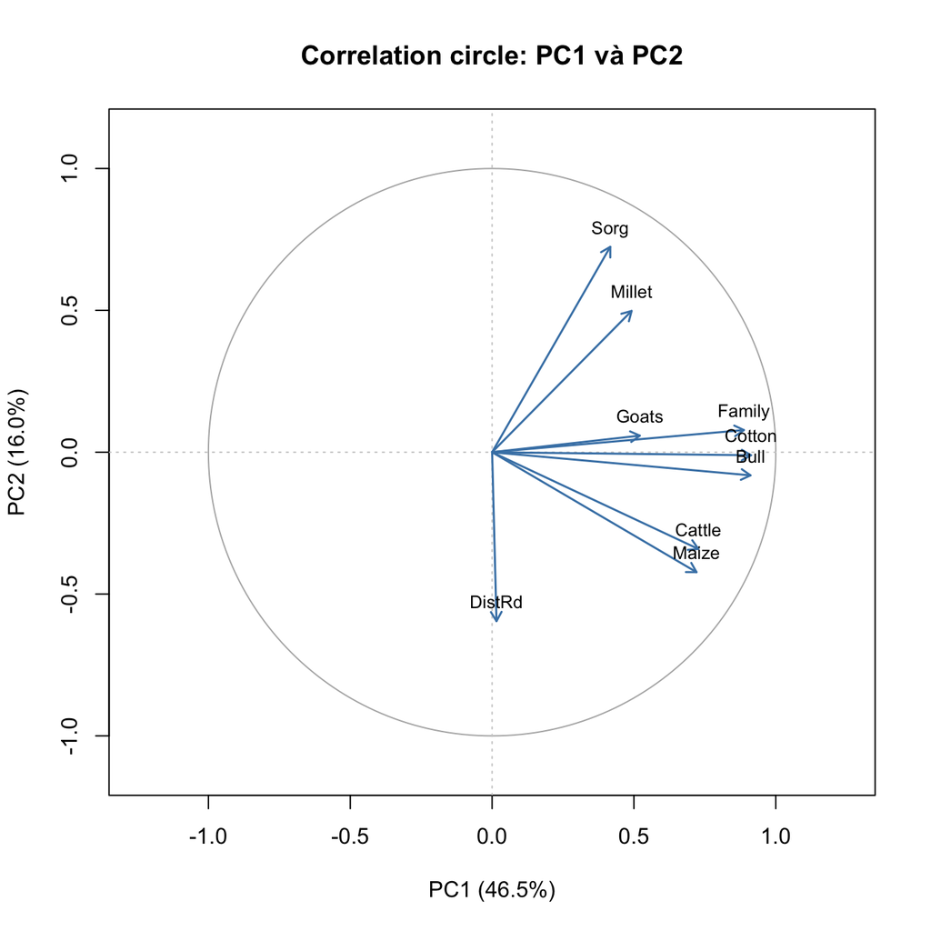

```r
plot(NA, xlim = c(-1.12, 1.12), ylim = c(-1.12, 1.12), asp = 1,
     xlab = paste0("PC1 (", sprintf("%.1f", 100 * pve_511[1]), "%)"),
     ylab = paste0("PC2 (", sprintf("%.1f", 100 * pve_511[2]), "%)"),
     main = "Correlation circle: PC1 và PC2")

symbols(0, 0, circles = 1, inches = FALSE, add = TRUE, fg = "gray70")
abline(h = 0, v = 0, col = "gray80", lty = 3)

arrows(0, 0, cor_loadings_511[, 1], cor_loadings_511[, 2],
       length = 0.08, col = "steelblue", lwd = 1.5)

text(cor_loadings_511[, 1], cor_loadings_511[, 2],
     labels = rownames(cor_loadings_511), pos = 3, cex = 0.8)
```

Trên mặt phẳng PC1–PC2, các vector Family, Cotton và Bull gần như cùng hướng, cho thấy mối tương quan dương mạnh giữa các biến này. Tương tự, Maize và Cattle có hướng tương đối gần nhau, trong khi Sorg và Millet cùng hướng về phía PC2 dương, gợi ý sự đồng biến giữa các đặc điểm canh tác tương ứng.

Vector DistRd gần vuông góc với nhóm Family, Cotton và Bull, phản ánh mối tương quan yếu giữa khoảng cách đến đường và nhóm biến quy mô nông nghiệp. Đồng thời, DistRd tạo góc tù với Sorg và Millet, gợi ý xu hướng tương quan âm.

Biplot các quan sát và biến

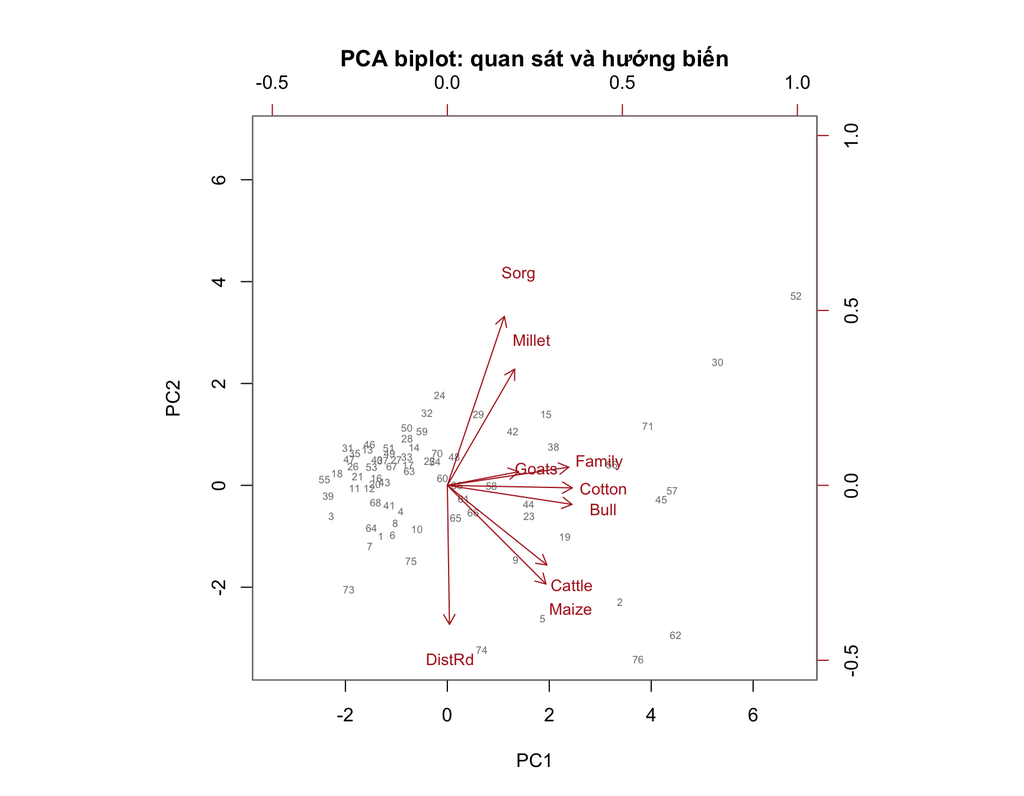

```r
biplot(pca_511, choices = c(1, 2), scale = 0,
       cex = c(0.55, 0.85), col = c("gray50", "firebrick"),
       main = "PCA biplot: quan sát và hướng biến")
```

Biplot trên mặt phẳng PC1–PC2 cho thấy phần lớn các hộ nông nghiệp tập trung quanh vùng trung tâm, trong khi một số hộ phân bố xa hơn theo hai trục thành phần chính, phản ánh sự khác biệt về đặc điểm sản xuất. Các hộ nằm về phía PC1 dương có xu hướng gắn với các biến Family, Cotton và Bull, phù hợp với cách diễn giải PC1 là hướng biến thiên chung về quy mô hoạt động nông nghiệp. Trong khi đó, sự phân bố theo PC2 phản ánh sự khác biệt giữa nhóm biến Sorg, Millet và các biến như DistRd, Maize, Cattle.

Như vậy, biplot không chỉ minh họa cấu trúc tương quan giữa các biến mà còn cho thấy sự khác biệt giữa các hộ nông nghiệp trên hai hướng biến thiên quan trọng nhất của dữ liệu. Tuy nhiên, mặt phẳng PC1–PC2 chỉ giải thích khoảng 62,48% tổng phương sai, nên chưa phản ánh đầy đủ toàn bộ sự khác biệt giữa các quan sát.S

### Diễn giải ý nghĩa năm thành phần chính đầu tiên

```r
interpret_511 <- do.call(rbind, lapply(seq_len(5), function(j) {
  idx <- order(abs(cor_loadings_511[, j]), decreasing = TRUE)[1:3]
  data.frame(
    PC = paste0("PC", j),
    Eigenvalue = eigenvalues_511[j],
    PVE_Percent = 100 * pve_511[j],
    CPVE_Percent = 100 * cpve_511[j],
    Leading_Variables = paste(rownames(cor_loadings_511)[idx], collapse = ", "),
    Leading_Correlations = paste(sprintf("%+.2f", cor_loadings_511[idx, j]), collapse = ", ")
  )
}))

knitr::kable(interpret_511, format = "html", digits = 2, row.names = FALSE,
             caption = "Tổng hợp trị riêng, phương sai giải thích và các biến nổi bật của PC1–PC5") |>
  kableExtra::kable_styling(full_width = FALSE, position = "center", font_size = 11)
```

Tổng hợp trị riêng, phương sai giải thích và các biến nổi bật của PC1–PC5

| PC | Eigenvalue | PVE_Percent | CPVE_Percent | Leading_Variables | Leading_Correlations |
| --- | --- | --- | --- | --- | --- |
| PC1 | 4.19 | 46.50 | 46.50 | Cotton, Bull, Family | +0.91, +0.91, +0.89 |
| PC2 | 1.44 | 15.98 | 62.48 | Sorg, DistRd, Millet | +0.72, -0.60, +0.50 |
| PC3 | 1.08 | 12.05 | 74.53 | Goats, DistRd, Maize | +0.72, +0.59, -0.40 |
| PC4 | 0.79 | 8.80 | 83.33 | Millet, DistRd, Cattle | +0.55, +0.44, -0.33 |
| PC5 | 0.60 | 6.71 | 90.04 | Sorg, Millet, DistRd | +0.50, -0.41, +0.29 |

PC1 có tương quan dương mạnh với Cotton (0,91), Bull (0,91), Family (0,89), Cattle (0,73) và Maize (0,72). Các biến này thuộc ba nhóm đặc điểm khác nhau: canh tác (Cotton, Maize), chăn nuôi (Bull, Cattle) và quy mô gia đình (Family). Việc nhiều biến thuộc các nhóm này cùng có tương quan dương mạnh cho thấy PC1 phản ánh một **hướng biến thiên chung giữa các đặc điểm về quy mô nông hộ**, thay vì chỉ đại diện cho một loại hình sản xuất. Vì vậy, PC1 được diễn giải là *quy mô hoạt động nông nghiệp tổng hợp*. Các hộ có điểm PC1 cao có xu hướng có giá trị lớn hơn ở những biến trên. Ngược lại, DistRd gần như không tương quan với PC1 (0,02), cho thấy khoảng cách đến đường không phải yếu tố đặc trưng của thành phần này.

PC2 có tương quan dương với Sorg (0,72), Millet (0,50), nhưng tương quan âm với DistRd (−0,60) và Maize (−0,42). Khác với PC1, các biến nổi bật ở PC2 không cùng biến thiên theo một hướng mà hình thành hai nhóm có dấu tương quan đối lập. Trong đó, Sorg và Millet thuộc nhóm canh tác nhưng có hướng biến thiên ngược với DistRd và Maize. Điều này cho thấy PC2 không phản ánh quy mô sản xuất chung mà chủ yếu **phân biệt các hộ theo sự khác nhau về đặc điểm cây trồng và khoảng cách đến đường**. Các hộ có điểm PC2 cao có xu hướng nổi bật hơn về Sorg, Millet và có giá trị DistRd, Maize thấp hơn.

PC3 có tương quan dương mạnh với Goats (0,72) và DistRd (0,59), trong khi Maize có tương quan âm (−0,40). Hai biến Goats và DistRd nổi bật hơn các biến còn lại, cho thấy PC3 chủ yếu phản ánh sự biến thiên đồng thời của số lượng dê và khoảng cách đến đường, đối lập với đặc điểm canh tác Maize. Do đó, PC3 được diễn giải là **hướng tương phản giữa chăn nuôi dê, khoảng cách giao thông và canh tác ngô**. Các hộ có điểm PC3 cao có xu hướng nuôi nhiều dê hơn, ở xa đường hơn và có giá trị Maize thấp hơn.

PC4 có tương quan dương với Millet (0,55), DistRd (0,44) và tương quan âm với Cattle (−0,33), Goats (−0,31). Các hệ số này cho thấy PC4 kết hợp những đặc điểm thuộc nhóm canh tác và giao thông theo một chiều, trong khi các biến chăn nuôi lại biến thiên theo chiều ngược lại. Vì vậy, PC4 được diễn giải là **hướng tương phản giữa đặc điểm canh tác Millet, khoảng cách đến đường và số lượng vật nuôi**, thay vì một thành phần phản ánh quy mô sản xuất tổng thể.

PC5 có tương quan dương với Sorg (0,50) và tương quan âm với Millet (−0,41), trong khi DistRd có tương quan dương thấp hơn (0,29). Hai biến nổi bật nhất đều thuộc nhóm canh tác nhưng có dấu tương quan trái ngược, cho thấy PC5 chủ yếu phản ánh **sự tương phản giữa hai đặc điểm cây trồng Sorg và Millet**. Theo đó, các hộ có điểm PC5 cao có xu hướng có giá trị Sorg lớn hơn và Millet thấp hơn. Khoảng cách đến đường cũng có liên hệ với thành phần này nhưng không giữ vai trò nổi bật bằng hai biến canh tác.

**Nhận xét tổng hợp**

Năm thành phần chính đầu tiên giải thích 90,04% tổng phương sai của dữ liệu. Trong đó, PC1 phản ánh hướng biến thiên chung của nhiều đặc điểm liên quan đến quy mô nông hộ, còn PC2–PC5 chủ yếu thể hiện các hướng tương phản giữa hoạt động canh tác, chăn nuôi và khoảng cách giao thông.

DistRd gần như không tương quan với PC1 nhưng có tương quan đáng kể với PC2, PC3 và PC4. Điều này cho thấy đặc điểm khoảng cách giao thông không nằm trong hướng biến thiên chung về quy mô nông nghiệp mà được phản ánh rõ hơn ở những thành phần tiếp theo.

Như vậy, PCA không chỉ giúp giảm số chiều từ 9 biến xuống 5 thành phần, bảo toàn phần lớn phương sai của dữ liệu, mà còn cho phép nhận diện những hướng biến thiên khác nhau trong đặc điểm của các hộ nông nghiệp.

# La Liga - PCA thống kê thành tích các đội bóng

## Giới thiệu và đề bài

### Bối cảnh

Bộ dữ liệu `laliga` ghi nhận thống kê thành tích của **20 đội bóng** tham dự **một mùa giải La Liga** (giải vô địch quốc gia Tây Ban Nha). Mỗi đội đá **38 trận**; đội thắng được 3 điểm, hòa được 1 điểm, thua không được điểm. Ngoài biến tên đội (`Team`), dữ liệu gồm 19 biến số:

| Nhóm | Biến | Ý nghĩa |
| --- | --- | --- |
| Kết quả | `Points`, `Matches`, `Wins`, `Draws`, `Loses` | Điểm, số trận, số trận thắng/hòa/thua |
| Bàn thắng | `Goals.scored`, `Goals.conceded`, `Difference.goals` | Bàn ghi được, bàn thua, hiệu số = ghi được − thua |
| Tỷ lệ bàn thắng | `Percentage.scored.goals`, `Percentage.conceded.goals` | % bàn ghi được / bàn thua so với tổng số bàn của cả giải |
| Tấn công | `Shots`, `Shots.on.goal`, `Penalties.scored`, `Assistances`, `Offsides` | Số cú sút, sút trúng đích, bàn từ phạt đền, kiến tạo, việt vị |
| Phòng ngự | `Matches.without.conceding` | Số trận giữ sạch lưới |
| Kỷ luật | `Fouls.made`, `Yellow.cards`, `Red.cards` | Số lần phạm lỗi, thẻ vàng, thẻ đỏ |

Các biến này tương quan mạnh với nhau: đội mạnh vừa thắng nhiều, ghi nhiều bàn, sút nhiều, vừa thua ít bàn; một số biến còn được tính trực tiếp từ các biến khác (ví dụ `Points` = 3·`Wins` + `Draws`). Vì vậy 19 biến chứa nhiều thông tin trùng lặp, và phân tích thành phần chính (PCA) được dùng để tóm tắt thành tích các đội bằng một số ít thành phần không tương quan.

### Câu hỏi đặt ra

Dựa trên bộ dữ liệu La Liga, hãy thực hiện phân tích thành phần chính (PCA) trên các biến thống kê thành tích của các đội bóng. Hãy xác định số thành phần chính cần giữ lại và nêu ý nghĩa của các thành phần chính đầu tiên được giữ lại.

Bài làm chia thành ba câu:

- **(a)** Thực hiện PCA trên các biến thống kê thành tích.
- **(b)** Xác định số thành phần chính cần giữ lại.
- **(c)** Nêu ý nghĩa của các thành phần chính được giữ lại.

## Dữ liệu và kiểm tra đầu vào

### Mô tả dữ liệu

```r
laliga <- as.data.frame(read_laliga())
dim(laliga)
```

```
## [1] 20 20
```

```r
str(laliga)
```

```
## 'data.frame':    20 obs. of  20 variables:
##  $ Team                     : chr  "Barcelona" "Real Madrid" "Atlético Madrid" "Villarreal" ...
##  $ Points                   : num  91 90 88 64 62 60 52 48 48 45 ...
##  $ Matches                  : num  38 38 38 38 38 38 38 38 38 38 ...
##  $ Wins                     : num  29 28 28 18 18 17 14 12 13 11 ...
##  $ Draws                    : num  4 6 4 10 8 9 10 12 9 12 ...
##  $ Loses                    : num  5 4 6 10 12 12 14 14 16 15 ...
##  $ Goals.scored             : num  112 110 63 44 58 51 51 38 45 34 ...
##  $ Goals.conceded           : num  29 34 18 35 45 59 50 35 48 52 ...
##  $ Difference.goals         : num  83 76 45 9 13 -8 1 3 -3 -18 ...
##  $ Percentage.scored.goals  : num  2.95 2.89 1.66 1.16 1.53 1.34 1.34 1 1.18 0.89 ...
##  $ Percentage.conceded.goals: num  0.76 0.89 0.47 0.92 1.18 1.55 1.32 0.92 1.26 1.37 ...
##  $ Shots                    : num  600 712 481 346 450 442 460 452 454 398 ...
##  $ Shots.on.goal            : num  277 299 186 135 178 170 189 170 164 132 ...
##  $ Penalties.scored         : num  11 6 1 3 3 4 6 2 1 3 ...
##  $ Assistances              : num  79 90 49 32 42 43 35 27 33 26 ...
##  $ Fouls.made               : num  385 420 503 534 502 528 555 552 465 490 ...
##  $ Matches.without.conceding: num  18 14 24 17 13 10 11 12 13 12 ...
##  $ Yellow.cards             : num  66 72 91 100 84 116 106 110 108 110 ...
##  $ Red.cards                : num  1 5 3 4 5 6 7 5 5 3 ...
##  $ Offsides                 : num  120 114 84 106 92 103 106 85 85 80 ...
```

```r
head(laliga)
```

```
##              Team Points Matches Wins Draws Loses Goals.scored Goals.conceded
## 1       Barcelona     91      38   29     4     5          112             29
## 2     Real Madrid     90      38   28     6     4          110             34
## 3 Atlético Madrid     88      38   28     4     6           63             18
## 4      Villarreal     64      38   18    10    10           44             35
## 5        Athletic     62      38   18     8    12           58             45
## 6           Celta     60      38   17     9    12           51             59
##   Difference.goals Percentage.scored.goals Percentage.conceded.goals Shots
## 1               83                    2.95                      0.76   600
## 2               76                    2.89                      0.89   712
## 3               45                    1.66                      0.47   481
## 4                9                    1.16                      0.92   346
## 5               13                    1.53                      1.18   450
## 6               -8                    1.34                      1.55   442
##   Shots.on.goal Penalties.scored Assistances Fouls.made
## 1           277               11          79        385
## 2           299                6          90        420
## 3           186                1          49        503
## 4           135                3          32        534
## 5           178                3          42        502
## 6           170                4          43        528
##   Matches.without.conceding Yellow.cards Red.cards Offsides
## 1                        18           66         1      120
## 2                        14           72         5      114
## 3                        24           91         3       84
## 4                        17          100         4      106
## 5                        13           84         5       92
## 6                        10          116         6      103
```

```r
colSums(is.na(laliga))
```

```
##                      Team                    Points                   Matches
##                         0                         0                         0
##                      Wins                     Draws                     Loses
##                         0                         0                         0
##              Goals.scored            Goals.conceded          Difference.goals
##                         0                         0                         0
##   Percentage.scored.goals Percentage.conceded.goals                     Shots
##                         0                         0                         0
##             Shots.on.goal          Penalties.scored               Assistances
##                         0                         0                         0
##                Fouls.made Matches.without.conceding              Yellow.cards
##                         0                         0                         0
##                 Red.cards                  Offsides
##                         0                         0
```

Dữ liệu có 20 đội và 20 cột (1 cột tên đội, 19 biến số), không có giá trị thiếu.

```r
summary(laliga[, -1])
```

```
##      Points         Matches        Wins           Draws           Loses
##  Min.   :32.00   Min.   :38   Min.   : 8.00   Min.   : 4.00   Min.   : 4.00
##  1st Qu.:41.25   1st Qu.:38   1st Qu.:10.00   1st Qu.: 8.00   1st Qu.:12.00
##  Median :44.50   Median :38   Median :12.00   Median : 9.00   Median :15.50
##  Mean   :52.40   Mean   :38   Mean   :14.40   Mean   : 9.20   Mean   :14.40
##  3rd Qu.:60.50   3rd Qu.:38   3rd Qu.:17.25   3rd Qu.:10.25   3rd Qu.:18.25
##  Max.   :91.00   Max.   :38   Max.   :29.00   Max.   :18.00   Max.   :22.00
##   Goals.scored    Goals.conceded  Difference.goals Percentage.scored.goals
##  Min.   : 34.00   Min.   :18.00   Min.   :-34.00   Min.   :0.890
##  1st Qu.: 40.00   1st Qu.:42.50   1st Qu.:-21.25   1st Qu.:1.050
##  Median : 45.50   Median :52.50   Median : -8.00   Median :1.195
##  Mean   : 52.15   Mean   :52.15   Mean   :  0.00   Mean   :1.371
##  3rd Qu.: 51.25   3rd Qu.:63.25   3rd Qu.:  4.50   3rd Qu.:1.347
##  Max.   :112.00   Max.   :74.00   Max.   : 83.00   Max.   :2.950
##  Percentage.conceded.goals     Shots       Shots.on.goal   Penalties.scored
##  Min.   :0.470             Min.   :346.0   Min.   :129.0   Min.   : 1.00
##  1st Qu.:1.115             1st Qu.:413.8   1st Qu.:151.2   1st Qu.: 1.00
##  Median :1.380             Median :438.0   Median :165.0   Median : 3.00
##  Mean   :1.371             Mean   :452.4   Mean   :173.1   Mean   : 3.45
##  3rd Qu.:1.663             3rd Qu.:455.5   3rd Qu.:180.0   3rd Qu.: 4.50
##  Max.   :1.950             Max.   :712.0   Max.   :299.0   Max.   :11.00
##   Assistances      Fouls.made    Matches.without.conceding  Yellow.cards
##  Min.   :23.00   Min.   :385.0   Min.   : 4.0              Min.   : 66.0
##  1st Qu.:28.50   1st Qu.:483.8   1st Qu.: 7.0              1st Qu.: 97.0
##  Median :32.50   Median :530.5   Median :10.5              Median :108.5
##  Mean   :37.85   Mean   :517.6   Mean   :10.7              Mean   :106.2
##  3rd Qu.:36.75   3rd Qu.:552.8   3rd Qu.:13.0              3rd Qu.:115.2
##  Max.   :90.00   Max.   :654.0   Max.   :24.0              Max.   :141.0
##    Red.cards       Offsides
##  Min.   :1.00   Min.   : 72.00
##  1st Qu.:4.00   1st Qu.: 83.25
##  Median :5.00   Median : 88.00
##  Mean   :5.05   Mean   : 92.60
##  3rd Qu.:6.00   3rd Qu.:103.75
##  Max.   :9.00   Max.   :123.00
```

Các biến có thang đo rất khác nhau: số cú sút và số lần phạm lỗi ở mức vài trăm, số điểm và số bàn thắng ở mức vài chục, còn số thẻ đỏ, số bàn từ phạt đền và hai biến tỷ lệ phần trăm chỉ ở mức vài đơn vị.

### Chọn biến đưa vào phân tích

```r
round(apply(laliga[, -1], 2, sd), 3)
```

```
##                    Points                   Matches                      Wins
##                    18.103                     0.000                     6.684
##                     Draws                     Loses              Goals.scored
##                     3.037                     5.103                    21.365
##            Goals.conceded          Difference.goals   Percentage.scored.goals
##                    15.806                    32.778                     0.563
## Percentage.conceded.goals                     Shots             Shots.on.goal
##                     0.417                    80.740                    43.564
##          Penalties.scored               Assistances                Fouls.made
##                     2.645                    17.202                    66.702
## Matches.without.conceding              Yellow.cards                 Red.cards
##                     4.921                    19.820                     1.761
##                  Offsides
##                    14.880
```

`Matches` có độ lệch chuẩn bằng 0 (mọi đội đều đá 38 trận) nên không mang thông tin để phân biệt các đội, và hệ số tương quan của nó với các biến khác không xác định → **loại `Matches`**. `Team` là nhãn, chỉ dùng để ghi tên trên đồ thị.

Một số biến là hàm tuyến tính (chính xác hoặc gần như chính xác) của các biến khác:

```r
c(
  Points_tru_3W_D        = max(abs(laliga$Points - (3 * laliga$Wins + laliga$Draws))),
  Loses_tru_38_W_D       = max(abs(laliga$Loses - (38 - laliga$Wins - laliga$Draws))),
  Difference_tru_GS_GC   = max(abs(laliga$Difference.goals - (laliga$Goals.scored - laliga$Goals.conceded)))
)
```

```
##      Points_tru_3W_D     Loses_tru_38_W_D Difference_tru_GS_GC
##                    0                    0                    0
```

```r
c(
  r_PctScored_GoalsScored     = cor(laliga$Percentage.scored.goals, laliga$Goals.scored),
  r_PctConceded_GoalsConceded = cor(laliga$Percentage.conceded.goals, laliga$Goals.conceded)
)
```

```
##     r_PctScored_GoalsScored r_PctConceded_GoalsConceded
##                   0.9999888                   0.9999747
```

- `Points` = 3·`Wins` + `Draws`, `Loses` = 38 − `Wins` − `Draws`, `Difference.goals` = `Goals.scored` − `Goals.conceded` đúng chính xác (sai lệch bằng 0).
- Hai biến tỷ lệ phần trăm gần như tỷ lệ thuận với số bàn ghi được / bàn thua (tương quan ≈ 1; chỉ lệch do làm tròn).

Theo đề bài, ta giữ đủ các biến thống kê thành tích (trừ `Matches`), tức p = 18 biến. Hệ quả cần lưu ý: ma trận tương quan sẽ có khoảng 5 trị riêng bằng hoặc gần bằng 0 (ứng với 5 quan hệ tuyến tính trên), và nhóm biến kết quả – bàn thắng được tính lặp nên có trọng lượng lớn trong thành phần chính đầu tiên.

```r
X <- as.matrix(laliga[, !(names(laliga) %in% c("Team", "Matches"))])
rownames(X) <- laliga$Team
n <- nrow(X)
p <- ncol(X)
c(n = n, p = p)
```

```
##  n  p
## 20 18
```

### Giá trị ngoại lai

Ngoại lai được xét ở hai bước: **trước chuẩn hóa** (trên thang đo gốc của từng biến) và **sau chuẩn hóa** (trên giá trị $z_{jk}=(x_{jk}-\bar x_k)/\sqrt{s_{kk}}$, là thang đo mà PCA trên ma trận tương quan sử dụng).

```r
xbar <- colMeans(X)
s_kk <- apply(X, 2, var)
```

#### Trước chuẩn hóa

##### Boxplot từng biến trên thang đo gốc

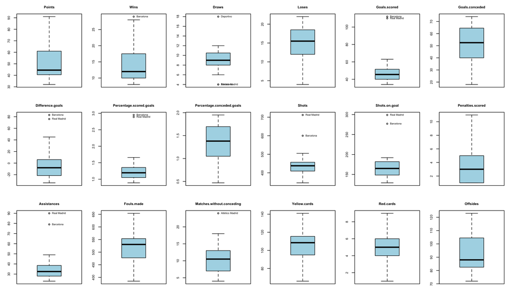

```r
par(mfrow = c(3, 6), mar = c(2, 3, 2.5, 0.5))
for (k in 1:p) {
  bp <- boxplot(X[, k], main = colnames(X)[k], cex.main = 0.75, col = "lightblue", cex.axis = 0.7)
  vuot <- which(X[, k] %in% bp$out)
  if (length(vuot) > 0) {
    text(rep(1, length(vuot)), X[vuot, k], labels = rownames(X)[vuot], pos = 4, cex = 0.55, xpd = TRUE)
  }
}
```

```r
par(mfrow = c(1, 1))
```

Mỗi biến được vẽ trên thang đo riêng của nó (điểm, số trận, số bàn, số cú sút…), các điểm nằm ngoài râu (vượt 1.5·IQR) được ghi tên đội.

```r
ds_vuot <- data.frame(Bien = character(0), Doi = character(0), Gia_tri = numeric(0))
for (k in 1:p) {
  # giá trị nằm ngoài râu của boxplot (cách hộp quá 1.5 lần khoảng tứ phân vị)
  vuot <- which(X[, k] %in% boxplot.stats(X[, k])$out)
  if (length(vuot) > 0) {
    ds_vuot <- rbind(ds_vuot, data.frame(Bien = colnames(X)[k], Doi = rownames(X)[vuot],
                                         Gia_tri = X[vuot, k]))
  }
}
rownames(ds_vuot) <- NULL
ds_vuot
```

```
##                         Bien             Doi Gia_tri
## 1                       Wins       Barcelona   29.00
## 2                      Draws       Barcelona    4.00
## 3                      Draws Atlético Madrid    4.00
## 4                      Draws       Deportivo   18.00
## 5               Goals.scored       Barcelona  112.00
## 6               Goals.scored     Real Madrid  110.00
## 7           Difference.goals       Barcelona   83.00
## 8           Difference.goals     Real Madrid   76.00
## 9    Percentage.scored.goals       Barcelona    2.95
## 10   Percentage.scored.goals     Real Madrid    2.89
## 11                     Shots       Barcelona  600.00
## 12                     Shots     Real Madrid  712.00
## 13             Shots.on.goal       Barcelona  277.00
## 14             Shots.on.goal     Real Madrid  299.00
## 15               Assistances       Barcelona   79.00
## 16               Assistances     Real Madrid   90.00
## 17 Matches.without.conceding Atlético Madrid   24.00
```

```r
sort(table(ds_vuot$Doi), decreasing = TRUE)
```

```
##
##       Barcelona     Real Madrid Atlético Madrid       Deportivo
##               8               6               2               1
```

Có 17 giá trị (thuộc 4 đội) nằm ngoài râu boxplot (vượt 1.5·IQR) trên thang đo gốc. Phần lớn thuộc về Barcelona, Real Madrid, Atlético Madrid — các đội đứng đầu với điểm số, bàn thắng, cú sút, kiến tạo vượt xa phần còn lại (Barcelona và Atlético Madrid còn có số trận hòa thấp bất thường, chỉ 4 trận). Trường hợp còn lại là Deportivo với 18 trận hòa, cao vượt trội so với các đội khác. Đây là thành tích thật của mùa giải (một giải đấu thường có vài đội vượt trội), không phải lỗi dữ liệu; quy tắc IQR chỉ đánh dấu để xem xét chứ không phải căn cứ để loại.

#### Khoảng cách Mahalanobis trên dữ liệu gốc

Khoảng cách $d_j^2=(\mathbf x_j-\bar{\mathbf x})'\mathbf S^{-1}(\mathbf x_j-\bar{\mathbf x})$ cần ma trận nghịch đảo $\mathbf S^{-1}$:

```r
S <- cov(X)
qr(S)$rank
```

```
## [1] 15
```

Ma trận $\mathbf S$ của 18 biến chỉ có hạng 15 < 18 do các quan hệ tuyến tính ở trên, nên **không khả nghịch**. Vì năm biến `Points`, `Loses`, `Difference.goals`, `Percentage.scored.goals`, `Percentage.conceded.goals` được tính từ các biến khác (không mang thêm thông tin), ta tính $d_j^2$ trên **13 biến còn lại** — các biến này không phụ thuộc tuyến tính nên ma trận hiệp phương sai khả nghịch.

```r
bien_dan_xuat <- c("Points", "Loses", "Difference.goals",
                   "Percentage.scored.goals", "Percentage.conceded.goals")
X_dl <- X[, !(colnames(X) %in% bien_dan_xuat)]
p_dl <- ncol(X_dl)
S_dl <- cov(X_dl)
qr(S_dl)$rank
```

```
## [1] 13
```

```r
Xc_dl <- X_dl - rep(1, n) %*% t(colMeans(X_dl))
d2 <- rowSums((Xc_dl %*% solve(S_dl)) * Xc_dl)        # d_j^2 cho từng đội
nguong_95  <- qchisq(0.95, df = p_dl)
nguong_995 <- qchisq(0.995, df = p_dl)
can_tren   <- (n - 1)^2 / n                             # giá trị lớn nhất có thể của d_j^2
c(chi2_095 = nguong_95, chi2_0995 = nguong_995, can_tren_d2 = can_tren)
```

```
##    chi2_095   chi2_0995 can_tren_d2
##    22.36203    29.81947    18.05000
```

```r
round(sort(d2, decreasing = TRUE), 2)
```

```
##       Deportivo       Barcelona     Real Madrid  Rayo Vallecano          Málaga
##           17.14           16.31           15.56           15.29           15.19
##        Espanyol Atlético Madrid         Granada          Getafe           Celta
##           15.13           14.76           13.32           12.92           12.82
##           Eibar      Villarreal        Valencia      Las Palmas         Sevilla
##           12.82           12.03           11.29           10.12           10.11
##  Sporting Gijón           Betis         Levante        Athletic   Real Sociedad
##            9.96            9.64            8.64            8.27            5.67
```

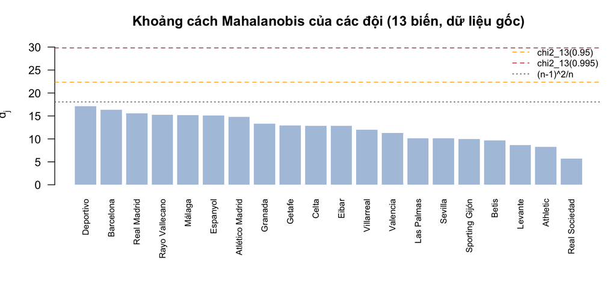

```r
par(mar = c(9, 4, 3, 1))
barplot(sort(d2, decreasing = TRUE), las = 2, cex.names = 0.75, col = "lightsteelblue",
        border = NA, ylim = c(0, nguong_995 * 1.05), ylab = expression(d[j]^2),
        main = "Khoảng cách Mahalanobis của các đội (13 biến, dữ liệu gốc)")
abline(h = c(nguong_95, nguong_995), lty = 2, col = c("orange", "firebrick"))
abline(h = can_tren, lty = 3, col = "grey30")
legend("topright", bty = "n", cex = 0.8, lty = c(2, 2, 3),
       col = c("orange", "firebrick", "grey30"),
       legend = c("chi2_13(0.95)", "chi2_13(0.995)", "(n-1)^2/n"))
```

- Không đội nào có $d_j^2$ vượt $\chi^2_{13}(0.95)=$ 22.36 hay $\chi^2_{13}(0.995)=$ 29.82; lớn nhất là Deportivo (17.14), nhỏ nhất là Real Sociedad (5.67).
- Cần lưu ý cỡ mẫu rất nhỏ so với số biến (n = 20, p = 13): khi dùng $\mathbf S$ tính từ chính mẫu, $d_j^2$ không thể vượt $(n-1)^2/n=$ 18.05 (đường chấm), thấp hơn cả hai phân vị khi-bình-phương, và xấp xỉ $\chi^2_p$ chỉ đáng tin khi $n$ và $n-p$ đủ lớn. Vì vậy ở đây chỉ nên so sánh $d_j^2$ giữa các đội với nhau: các giá trị khá đồng đều, không đội nào tách hẳn khỏi phần còn lại.
- Các đội có $d_j^2$ lớn nhất gồm cả đội đầu bảng (Barcelona, Real Madrid) lẫn những đội có tổ hợp thống kê khác thường (ví dụ Deportivo với 18 trận hòa), đều là thành tích thật trong mùa giải.

#### Sau chuẩn hóa

##### Boxplot các biến đã chuẩn hóa

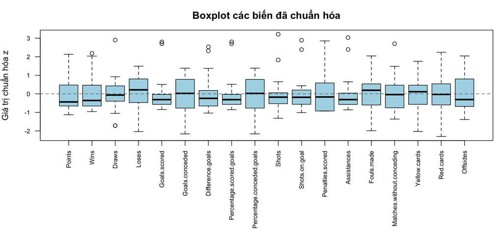

```r
Z <- (X - rep(1, n) %*% t(xbar)) / (rep(1, n) %*% t(sqrt(s_kk)))   # giá trị chuẩn hóa
par(mar = c(11, 4, 3, 1))
boxplot(Z, las = 2, col = "lightblue", cex.axis = 0.75,
        main = "Boxplot các biến đã chuẩn hóa", ylab = "Giá trị chuẩn hóa z")
abline(h = c(-3.5, 0, 3.5), lty = c(3, 2, 3), col = c("firebrick", "grey40", "firebrick"))
```

##### Giá trị chuẩn hóa

```r
round(apply(abs(Z), 2, max), 2)
```

```
##                    Points                      Wins                     Draws
##                      2.13                      2.18                      2.90
##                     Loses              Goals.scored            Goals.conceded
##                      2.04                      2.80                      2.16
##          Difference.goals   Percentage.scored.goals Percentage.conceded.goals
##                      2.53                      2.81                      2.16
##                     Shots             Shots.on.goal          Penalties.scored
##                      3.22                      2.89                      2.85
##               Assistances                Fouls.made Matches.without.conceding
##                      3.03                      2.04                      2.70
##              Yellow.cards                 Red.cards                  Offsides
##                      2.03                      2.30                      2.04
```

```r
sum(abs(Z) > 3.5)
```

```
## [1] 0
```

```r
# các đội có |z| lớn nhất ở từng biến
data.frame(Bien = colnames(Z),
           Doi = rownames(Z)[apply(abs(Z), 2, which.max)],
           z_max = round(apply(abs(Z), 2, max), 2),
           row.names = NULL)
```

```
##                         Bien             Doi z_max
## 1                     Points       Barcelona  2.13
## 2                       Wins       Barcelona  2.18
## 3                      Draws       Deportivo  2.90
## 4                      Loses     Real Madrid  2.04
## 5               Goals.scored       Barcelona  2.80
## 6             Goals.conceded Atlético Madrid  2.16
## 7           Difference.goals       Barcelona  2.53
## 8    Percentage.scored.goals       Barcelona  2.81
## 9  Percentage.conceded.goals Atlético Madrid  2.16
## 10                     Shots     Real Madrid  3.22
## 11             Shots.on.goal     Real Madrid  2.89
## 12          Penalties.scored       Barcelona  2.85
## 13               Assistances     Real Madrid  3.03
## 14                Fouls.made        Espanyol  2.04
## 15 Matches.without.conceding Atlético Madrid  2.70
## 16              Yellow.cards       Barcelona  2.03
## 17                 Red.cards       Barcelona  2.30
## 18                  Offsides  Rayo Vallecano  2.04
```

Không có giá trị chuẩn hóa nào vượt 3.5 (lớn nhất là 3.22) → không có giá trị bất thường theo từng biến. Các giá trị lớn nhất chủ yếu thuộc về Barcelona và Real Madrid. Chuẩn hóa chỉ dịch chuyển và co giãn từng biến nên không làm thay đổi vị trí tương đối giữa các đội (boxplot của $z$ có cùng hình dạng, quy tắc 1.5·IQR trên $z$ đánh dấu đúng 17 giá trị như trên dữ liệu gốc). Khác biệt nằm ở tiêu chí: quy tắc IQR đánh dấu rộng để xem xét, còn ngưỡng $|z|>3.5$ chỉ coi là bất thường những giá trị cách trung bình hơn 3.5 độ lệch chuẩn — không giá trị nào thỏa.

##### Khoảng cách Mahalanobis trên dữ liệu chuẩn hóa

```r
Z_dl <- Z[, colnames(X_dl)]
d2_z <- rowSums((Z_dl %*% solve(cov(Z_dl))) * Z_dl)
round(sort(d2_z, decreasing = TRUE), 2)
```

```
##       Deportivo       Barcelona     Real Madrid  Rayo Vallecano          Málaga
##           17.14           16.31           15.56           15.29           15.19
##        Espanyol Atlético Madrid         Granada          Getafe           Celta
##           15.13           14.76           13.32           12.92           12.82
##           Eibar      Villarreal        Valencia      Las Palmas         Sevilla
##           12.82           12.03           11.29           10.12           10.11
##  Sporting Gijón           Betis         Levante        Athletic   Real Sociedad
##            9.96            9.64            8.64            8.27            5.67
```

```r
max(abs(d2_z - d2))
```

```
## [1] 1.811884e-13
```

Khoảng cách Mahalanobis tính trên dữ liệu chuẩn hóa **trùng hoàn toàn** với dữ liệu gốc (sai lệch lớn nhất 1.8e-13): vì $\mathbf z_j=\mathbf D^{-1/2}(\mathbf x_j-\bar{\mathbf x})$ và $\text{cov}(\mathbf z)=\mathbf D^{-1/2}\mathbf S\mathbf D^{-1/2}$, nên $\mathbf z_j'[\text{cov}(\mathbf z)]^{-1}\mathbf z_j=(\mathbf x_j-\bar{\mathbf x})'\mathbf S^{-1}(\mathbf x_j-\bar{\mathbf x})$ — khoảng cách Mahalanobis không phụ thuộc đơn vị đo. Kết luận về ngoại lai nhiều chiều vì vậy giống nhau trước và sau chuẩn hóa.

#### Kết luận về ngoại lai

| Tiêu chí | Trước chuẩn hóa | Sau chuẩn hóa |
| --- | --- | --- |
| Từng biến | 17 giá trị vượt 1.5·IQR, chủ yếu của các đội đầu bảng | Không giá trị nào có $\|z\|>3.5$ (lớn nhất 3.22) |
| Nhiều chiều (Mahalanobis, 13 biến) | Không đội nào vượt $\chi^2_{13}(0.95)$; lớn nhất Deportivo (17.14) | Giống hệt trước chuẩn hóa |

Các giá trị bị quy tắc IQR đánh dấu đều là thành tích thật (chủ yếu của các đội đầu bảng); theo ngưỡng $|z|>3.5$ và theo khoảng cách Mahalanobis thì không có giá trị hay đội nào bất thường, và kết luận này không đổi dù xét trên dữ liệu gốc hay dữ liệu chuẩn hóa → không có đội nào là ngoại lai cần loại, **giữ nguyên toàn bộ 20 đội** cho phân tích.

### Độ lệch chuẩn và tương quan giữa các biến

#### Độ lệch chuẩn từng biến

```r
bang(data.frame(Bien = colnames(X),
                Trung_binh = round(xbar, 2),
                Do_lech_chuan = round(sqrt(s_kk), 3),
                row.names = NULL)[order(sqrt(s_kk), decreasing = TRUE), ], digits = 3)
```

|  | Bien | Trung_binh | Do_lech_chuan |
| --- | --- | --- | --- |
| 10 | Shots | 452.40 | 80.740 |
| 14 | Fouls.made | 517.65 | 66.702 |
| 11 | Shots.on.goal | 173.05 | 43.564 |
| 7 | Difference.goals | 0.00 | 32.778 |
| 5 | Goals.scored | 52.15 | 21.365 |
| 16 | Yellow.cards | 106.25 | 19.820 |
| 1 | Points | 52.40 | 18.103 |
| 13 | Assistances | 37.85 | 17.202 |
| 6 | Goals.conceded | 52.15 | 15.806 |
| 18 | Offsides | 92.60 | 14.880 |
| 2 | Wins | 14.40 | 6.684 |
| 4 | Loses | 14.40 | 5.103 |
| 15 | Matches.without.conceding | 10.70 | 4.921 |
| 3 | Draws | 9.20 | 3.037 |
| 12 | Penalties.scored | 3.45 | 2.645 |
| 17 | Red.cards | 5.05 | 1.761 |
| 8 | Percentage.scored.goals | 1.37 | 0.563 |
| 9 | Percentage.conceded.goals | 1.37 | 0.417 |

```r
round(max(sqrt(s_kk)) / min(sqrt(s_kk)))
```

```
## [1] 193
```

Độ lệch chuẩn chênh lệch rất lớn giữa các biến: lớn nhất là Shots (80.74) và Fouls.made (66.7), nhỏ nhất là Percentage.conceded.goals (0.417) — gấp khoảng 193 lần. Chênh lệch này chủ yếu do **đơn vị đo khác nhau** (số cú sút, số lần phạm lỗi tính theo hàng trăm; tỷ lệ phần trăm bàn thắng chỉ khoảng 1–3) chứ không phản ánh mức độ quan trọng của biến. Nếu làm PCA trên $\mathbf S$, các thành phần chính đầu sẽ bị chi phối bởi các biến có phương sai lớn như `Shots`, `Fouls.made`, `Shots.on.goal` → cần chuẩn hóa, tức làm PCA trên ma trận tương quan $\mathbf R$.

#### Ma trận tương quan mẫu R

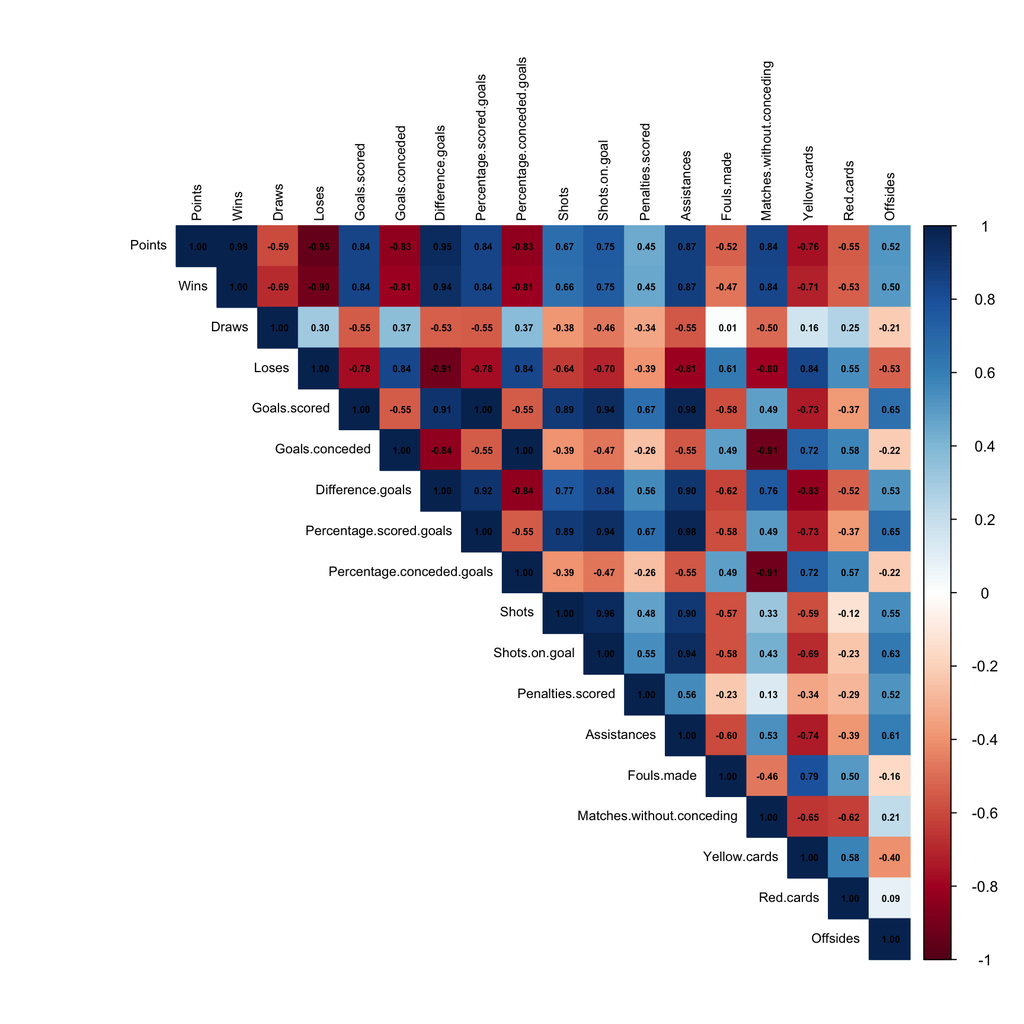

```r
D_can <- diag(1 / sqrt(s_kk))
R <- D_can %*% S %*% D_can
dimnames(R) <- list(colnames(X), colnames(X))
corrplot::corrplot(R, method = "color", type = "upper", addCoef.col = "black",
                   number.cex = 0.5, tl.col = "black", tl.cex = 0.7)
```

**Các cặp biến tương quan rất cao.** Liệt kê các cặp có $|r_{ik}| > 0.9$ trong $\mathbf R$:

```r
chi_so <- which(upper.tri(R) & abs(R) > 0.9, arr.ind = TRUE)
cap_cao <- data.frame(Bien_1 = rownames(R)[chi_so[, 1]],
                      Bien_2 = colnames(R)[chi_so[, 2]],
                      r = R[chi_so])
cap_cao <- cap_cao[order(-abs(cap_cao$r)), ]
rownames(cap_cao) <- NULL
bang(cap_cao, digits = 4)
```

| Bien_1 | Bien_2 | r |
| --- | --- | --- |
| Goals.scored | Percentage.scored.goals | 1.0000 |
| Goals.conceded | Percentage.conceded.goals | 1.0000 |
| Points | Wins | 0.9925 |
| Goals.scored | Assistances | 0.9764 |
| Percentage.scored.goals | Assistances | 0.9760 |
| Shots | Shots.on.goal | 0.9597 |
| Points | Difference.goals | 0.9506 |
| Points | Loses | -0.9475 |
| Shots.on.goal | Assistances | 0.9433 |
| Goals.scored | Shots.on.goal | 0.9402 |
| Percentage.scored.goals | Shots.on.goal | 0.9396 |
| Wins | Difference.goals | 0.9391 |
| Difference.goals | Percentage.scored.goals | 0.9152 |
| Goals.scored | Difference.goals | 0.9146 |
| Loses | Difference.goals | -0.9125 |
| Percentage.conceded.goals | Matches.without.conceding | -0.9119 |
| Goals.conceded | Matches.without.conceding | -0.9115 |
| Difference.goals | Assistances | 0.9033 |
| Wins | Loses | -0.9015 |

Có 19 cặp biến với $|r| > 0.9$, nhưng hai cặp đứng đầu khác hẳn phần còn lại:

- $r$(`Goals.scored`, `Percentage.scored.goals`) = 1.0000 và $r$(`Goals.conceded`, `Percentage.conceded.goals`) = 1.0000 — bằng 1 đến 4 chữ số thập phân. Tỷ số `Goals.scored` / `Percentage.scored.goals` (và tương tự cho bàn thua) luôn xấp xỉ 38 (từ 37.91 đến 38.20): biến “phần trăm” thực chất là số bàn trung bình mỗi trận, tức số bàn chia cho 38 trận rồi làm tròn, nên mỗi cặp **chứa cùng một thông tin, chỉ khác đơn vị**.
- Các cặp còn lại, dù tương quan cao (ví dụ $r$(`Points`, `Wins`) = 0.9925, $r$(`Shots`, `Shots.on.goal`) = 0.9597), vẫn mang thông tin riêng: `Points` còn phụ thuộc `Draws`, số cú sút trúng đích không tỷ lệ cố định với tổng số cú sút. Đây là mối liên hệ thực chất giữa các khía cạnh thành tích mà PCA cần tóm tắt, nên không loại.

Khi giữ cả hai biến của một cặp $r \approx 1$, thông tin về bàn thắng/bàn thua bị **tính hai lần**: trên $\mathbf R$ mỗi biến có phương sai 1, nên cặp này đóng góp phương sai gấp đôi cho cùng một hướng, có thể làm tăng tỷ lệ phương sai mà thành phần chính chứa hướng đó giải thích. Mặt khác, đề bài yêu cầu dùng đủ các biến. Vì vậy bài phân tích chạy song song **hai kịch bản**:

- **Kịch bản 18 biến** (kịch bản chính, theo đúng đề bài): mọi biến thống kê trừ `Matches`.
- **Kịch bản 16 biến**: với mỗi cặp $r \approx 1$ chỉ giữ một biến — giữ `Goals.scored`, `Goals.conceded` (số bàn, dễ diễn giải hơn) và bỏ hai biến tỷ lệ phần trăm.

Phân tích chi tiết được trình bày cho kịch bản 18 biến; kết quả của kịch bản 16 biến được đặt cạnh để so sánh ở các bước chính (trị riêng, tương quan, contribution, cos², số thành phần giữ lại, ý nghĩa), nhằm trả lời: việc tính hai lần thông tin này có làm thay đổi kết luận PCA hay không.

```r
bien_phan_tram <- c("Percentage.scored.goals", "Percentage.conceded.goals")
X16 <- X[, !(colnames(X) %in% bien_phan_tram)]
p16 <- ncol(X16)
c(p_18 = p, p_16 = p16)
```

```
## p_18 p_16
##   18   16
```

**Chọn ma trận R:** các biến có đơn vị và độ lớn khác nhau rất nhiều (độ lệch chuẩn của `Shots` ≈ 80.7, của `Percentage.conceded.goals` ≈ 0.42). Nếu làm PCA trên $\mathbf S$, các biến có phương sai lớn như `Shots`, `Fouls.made` sẽ chi phối các thành phần chính. Vì vậy PCA được thực hiện trên **ma trận tương quan mẫu R**, tương đương với PCA trên các biến đã chuẩn hóa $z_{jk}$.

## Câu (a) — PCA trên ma trận tương quan

### Các cặp trị riêng – vectơ riêng của R

```r
eig_R <- eigen(R)
lambda_hat <- eig_R$values
V_hat <- eig_R$vectors
dimnames(V_hat) <- list(colnames(X), paste0("v", 1:p))

# vectơ riêng chỉ xác định đến dấu: chọn dấu để dễ đọc
# (Points dương trên PC1, Matches.without.conceding dương trên PC2, Draws dương trên PC3)
if (V_hat["Points", 1] < 0) V_hat[, 1] <- -V_hat[, 1]
if (V_hat["Matches.without.conceding", 2] < 0) V_hat[, 2] <- -V_hat[, 2]
if (V_hat["Draws", 3] < 0) V_hat[, 3] <- -V_hat[, 3]

round(lambda_hat, 4)
```

```
##  [1] 11.8149  2.4069  1.3001  0.8368  0.7362  0.3636  0.2096  0.1397  0.1071
## [10]  0.0517  0.0166  0.0098  0.0070  0.0000  0.0000  0.0000  0.0000  0.0000
```

```r
sum(lambda_hat)
```

```
## [1] 18
```

$\hat\lambda_1=$ 11.815, $\hat\lambda_2=$ 2.407, $\hat\lambda_3=$ 1.3, $\hat\lambda_4=$ 0.837, … Tổng các trị riêng bằng 18 $=\text{tr}(\mathbf R)=p$. Có 5 trị riêng gần bằng 0 (< 0.001), đúng với các quan hệ tuyến tính giữa các biến đã nêu: theo các hướng đó dữ liệu gần như không biến thiên.

Kiểm tra $\hat{\mathbf V}'\hat{\mathbf V}=\mathbf I$ và $\hat{\mathbf V}'\mathbf R\hat{\mathbf V}=\text{diag}(\hat\lambda_1,\dots,\hat\lambda_p)$:

```r
max(abs(t(V_hat) %*% V_hat - diag(p)))
```

```
## [1] 5.459515e-15
```

```r
max(abs(t(V_hat) %*% R %*% V_hat - diag(lambda_hat)))
```

```
## [1] 1.953993e-14
```

Cả hai sai lệch đều xấp xỉ 0 → các vectơ riêng trực chuẩn và chéo hóa $\mathbf R$.

### Các thành phần chính mẫu

Thành phần chính mẫu thứ $i$ trên các biến chuẩn hóa: $\hat y_i=\hat{\mathbf v}_i'\mathbf z=\hat v_{i1}z_1+\dots+\hat v_{ip}z_p$, với $\text{var}(\hat y_i)=\hat\lambda_i$ và $\text{cov}(\hat y_i,\hat y_k)=0$, $i\ne k$. Hệ số của ba thành phần đầu:

```r
bang(data.frame(Bien = colnames(X), V_hat[, 1:3], row.names = NULL), digits = 3)
```

| Bien | v1 | v2 | v3 |
| --- | --- | --- | --- |
| Points | 0.280 | 0.085 | -0.136 |
| Wins | 0.277 | 0.070 | -0.219 |
| Draws | -0.157 | 0.045 | 0.633 |
| Loses | -0.269 | -0.118 | -0.090 |
| Goals.scored | 0.271 | -0.220 | 0.011 |
| Goals.conceded | -0.232 | -0.336 | 0.062 |
| Difference.goals | 0.288 | 0.019 | -0.022 |
| Percentage.scored.goals | 0.271 | -0.219 | 0.010 |
| Percentage.conceded.goals | -0.232 | -0.336 | 0.063 |
| Shots | 0.229 | -0.299 | 0.133 |
| Shots.on.goal | 0.252 | -0.265 | 0.082 |
| Penalties.scored | 0.160 | -0.272 | -0.095 |
| Assistances | 0.271 | -0.186 | 0.015 |
| Fouls.made | -0.189 | -0.073 | -0.561 |
| Matches.without.conceding | 0.222 | 0.364 | -0.163 |
| Yellow.cards | -0.244 | -0.108 | -0.358 |
| Red.cards | -0.158 | -0.340 | -0.099 |
| Offsides | 0.163 | -0.341 | -0.056 |

Viết lại thành công thức tổ hợp tuyến tính của ba thành phần chính đầu ($z_{\text{tên biến}}$ là biến đã chuẩn hóa):

$$\begin{aligned}
\hat y_1 ={}& +0.280\,z_{\text{Points}} +0.277\,z_{\text{Wins}}
-0.157\,z_{\text{Draws}}\\
&-0.269\,z_{\text{Loses}} +0.271\,z_{\text{Goals.scored}}
-0.232\,z_{\text{Goals.conceded}}\\
&+0.288\,z_{\text{Difference.goals}}
+0.271\,z_{\text{Percentage.scored.goals}}
-0.232\,z_{\text{Percentage.conceded.goals}}\\
&+0.229\,z_{\text{Shots}} +0.252\,z_{\text{Shots.on.goal}}
+0.160\,z_{\text{Penalties.scored}}\\
&+0.271\,z_{\text{Assistances}} -0.189\,z_{\text{Fouls.made}}
+0.222\,z_{\text{Matches.without.conceding}}\\
&-0.244\,z_{\text{Yellow.cards}} -0.158\,z_{\text{Red.cards}}
+0.163\,z_{\text{Offsides}}
\end{aligned}$$

$$\begin{aligned}
\hat y_2 ={}& +0.085\,z_{\text{Points}} +0.070\,z_{\text{Wins}}
+0.045\,z_{\text{Draws}}\\
&-0.118\,z_{\text{Loses}} -0.220\,z_{\text{Goals.scored}}
-0.336\,z_{\text{Goals.conceded}}\\
&+0.019\,z_{\text{Difference.goals}}
-0.219\,z_{\text{Percentage.scored.goals}}
-0.336\,z_{\text{Percentage.conceded.goals}}\\
&-0.299\,z_{\text{Shots}} -0.265\,z_{\text{Shots.on.goal}}
-0.272\,z_{\text{Penalties.scored}}\\
&-0.186\,z_{\text{Assistances}} -0.073\,z_{\text{Fouls.made}}
+0.364\,z_{\text{Matches.without.conceding}}\\
&-0.108\,z_{\text{Yellow.cards}} -0.340\,z_{\text{Red.cards}}
-0.341\,z_{\text{Offsides}}
\end{aligned}$$

$$\begin{aligned}
\hat y_3 ={}& -0.136\,z_{\text{Points}} -0.219\,z_{\text{Wins}}
+0.633\,z_{\text{Draws}}\\
&-0.090\,z_{\text{Loses}} +0.011\,z_{\text{Goals.scored}}
+0.062\,z_{\text{Goals.conceded}}\\
&-0.022\,z_{\text{Difference.goals}}
+0.010\,z_{\text{Percentage.scored.goals}}
+0.063\,z_{\text{Percentage.conceded.goals}}\\
&+0.133\,z_{\text{Shots}} +0.082\,z_{\text{Shots.on.goal}}
-0.095\,z_{\text{Penalties.scored}}\\
&+0.015\,z_{\text{Assistances}} -0.561\,z_{\text{Fouls.made}}
-0.163\,z_{\text{Matches.without.conceding}}\\
&-0.358\,z_{\text{Yellow.cards}} -0.099\,z_{\text{Red.cards}}
-0.056\,z_{\text{Offsides}}
\end{aligned}$$

$\hat y_1$ có hệ số khá đều nhau về độ lớn trên hầu hết các biến, chia thành hai nhóm dấu (kết quả tốt – tấn công dương; thua – bàn thua – phạm lỗi âm). $\hat y_2$ có hệ số lớn nhất ở `Matches.without.conceding` (dương) và nhóm `Goals.conceded`, `Offsides`, `Red.cards`, `Shots` (âm). $\hat y_3$ tập trung vào `Draws` (dương) và `Fouls.made`, `Yellow.cards` (âm). Ý nghĩa cụ thể được phân tích qua tương quan, contribution và cos² dưới đây.

Scores của từng đội: $\hat{\mathbf Y}=\mathbf Z\hat{\mathbf V}$.

```r
Y_hat <- Z %*% V_hat
colnames(Y_hat) <- paste0("y", 1:p)
round(Y_hat[, 1:3], 3)
```

```
##                     y1     y2     y3
## Barcelona        8.881 -1.064  0.059
## Real Madrid      8.051 -2.354  0.518
## Atlético Madrid  4.600  3.302 -1.666
## Villarreal       0.809  2.218 -0.571
## Athletic         1.442  0.624  0.029
## Celta           -0.022 -0.747 -0.454
## Sevilla          0.102 -0.931 -0.359
## Málaga          -0.561  1.532  0.219
## Real Sociedad   -0.407  1.004  0.407
## Betis           -1.517  1.742  0.857
## Las Palmas      -0.600  0.727  0.419
## Valencia        -1.526 -0.076 -0.208
## Eibar           -1.426 -0.453 -0.312
## Espanyol        -2.982 -0.861 -1.745
## Deportivo       -1.175  0.545  3.900
## Granada         -2.730 -1.676 -1.003
## Sporting Gijón  -2.493  0.508  0.188
## Rayo Vallecano  -1.819 -3.090  0.380
## Getafe          -3.011 -0.168 -0.140
## Levante         -3.617 -0.781 -0.517
```

```r
round(diag(t(Y_hat) %*% Y_hat / (n - 1))[1:5], 4)
```

```
##      y1      y2      y3      y4      y5
## 11.8149  2.4069  1.3001  0.8368  0.7362
```

Phương sai mẫu của các cột scores bằng đúng $\hat\lambda_1,\hat\lambda_2,\dots$ → $\text{var}(\hat y_i)=\hat\lambda_i$.